# Zbakh_Jason_1_preparation_nettoyage_analyse_exploratoire_082024

PROJET n°11 | PRODUISEZ UNE ETUDE DE MARCHE AVEC :

- 1 - IMPORT DES DONNEES
  - 1.1 - DisponibiliteAlimentaire_2017.csv
    - 1.1.1 - Préparation dataframe df_alimentaire
    - 1.1.2 - Éxploration df_alimentaire
  - 1.2 - Population_2000_2018.csv
    - 1.2.1 - Préparation dataframe df_population
    - 1.2.2 - Éxploration df_population
  - 1.3 - BasicAndSafelyManagedDrinkingWaterServices.csv
    - 1.3.1 - Préparation dataframe df_water
    - 1.3.2 - Éxploration df_water
  - 1.4 - Sous_nutrition.csv
    - 1.4.1 - Préparation dataframe df_sous_nutrition
    - 1.4.2 - Éxploration df_sous_nutrition
  - 1.5 - Liste pays.xlsx
    - 1.5.1 - Préparation dataframe df_pays
    - 1.5.2 - Éxploration des df_pays
  - 1.6 - Data_Extract_From_World_Development_Indicators.csv
    - 1.6.1 - Préparation dataframe df_wdi
    - 1.6.2 - Éxploration df_wdi
- 2 - HARMONISATION DES CLES DE JONCTION
  - 2.1 - Liste des noms dans chaque dataframes
  - 2.2 - Noms francais ['Pays'] pour df_alimentaire df_population df_sous_nutrition et df_pays
  - 2.3 - Noms anglais ['Pays2'] pour df_wdi , df_water , df_pays
- 3 - JONCTION DES FICHIERS
  - 3.1 - Réalisation de la jointure entre df_alimentaire et df_pays
  - 3.2 - Réalisation de la jointure entre df_merge et df_sous_nutrition
  - 3.3 - Réalisation de la jointure entre df_merge2 et df_population
  - 3.4 - Réalisation de la jointure entre df_merge3 et df_water
  - 3.5 - Réalisation de la jointure entre df_merge4 et df_wdi
  - 3.6 - Vérification et traitement de la matrice final
    - 3.6.1 - Verification et conclusion noms francais : 'Pays'
    - 3.6.2 - Verification des noms anglais : 'Pays2'
    - 3.6.3 - Renommer les variables selon l'analyse PESTEL
- 4 - DF_POULE_QUI_CHANTE
  - 4.1 - Traitement des valeurs manquantes
    - 4.1.1 - Éxploration graphique des valeurs manquantes
    - 4.1.2 - Traitement par variables
    - 4.1.3 - Traitement par individus
    - 4.1.4 - Vérification et éxploration post-traitement
  - 4.2 - Corrélation entre variables
  - 4.3 - Choix des variables fortement corrélées
  - 4.4 - Exploration df_poule_qui_chante
  - 4.5 - Export Poule Qui Chante : PQC.csv

# Config notebook

```python
# Version de Python :
! python --version
```

```
Python 3.12.3
```

```python
# Import de la bibliothèque Pandas
import pandas as pd
```

```python
# Afficher un nombre maximum de colonnes des dataframes Pandas
pd.set_option('display.max_columns', None)
```

```python
# Import de la bibliothèque Seaborn
import seaborn as sns
```

```python
# Import de la bibliothèque Numpy
import numpy as np
```

```python
#Import de la bibliothèque matplotlib
import matplotlib.pyplot as plt
```

```python
# Import de la bibliothèque statsmodels
from statsmodels.imputation import mice
```

```python
# Import de la bibliothèque plotly
import plotly.express as px
```

```python
# Importe la librairie pour visualiser les données manquantes
import missingno as msno
```

# 1 - IMPORT ET PREPARATION DES DONNEES

## 1.1 - DisponibiliteAlimentaire_2017.csv

### 1.1.1 - Préparation dataframe df_alimentaire

```python
# Import du fichier dispo_alimentaire_2017.csv

df_dispo_alimentaire = pd.read_csv('C:\\Users\\WadJa\\Desktop\\Openclassroom\\VSCode\\Repository Github\\Local_Repository_Win11\\Projet 11\\Data\\DAN-P9-data\\DisponibiliteAlimentaire_2017.csv', sep=',')
```

```python
df_dispo_alimentaire
```

|  | Code Domaine | Domaine | Code zone | Zone | Code Élément | Élément | Code Produit | Produit | Code année | Année | Unité | Valeur | Symbole | Description du Symbole |
| --- | --- | --- | --- | --- | --- | --- | --- | --- | --- | --- | --- | --- | --- | --- |
| 0 | FBS | Nouveaux Bilans Alimentaire | 2 | Afghanistan | 5511 | Production | 2511 | Blé et produits | 2017 | 2017 | Milliers de tonnes | 4281.00 | S | Données standardisées |
| 1 | FBS | Nouveaux Bilans Alimentaire | 2 | Afghanistan | 5611 | Importations - Quantité | 2511 | Blé et produits | 2017 | 2017 | Milliers de tonnes | 2302.00 | S | Données standardisées |
| 2 | FBS | Nouveaux Bilans Alimentaire | 2 | Afghanistan | 5072 | Variation de stock | 2511 | Blé et produits | 2017 | 2017 | Milliers de tonnes | -119.00 | S | Données standardisées |
| 3 | FBS | Nouveaux Bilans Alimentaire | 2 | Afghanistan | 5911 | Exportations - Quantité | 2511 | Blé et produits | 2017 | 2017 | Milliers de tonnes | 0.00 | S | Données standardisées |
| 4 | FBS | Nouveaux Bilans Alimentaire | 2 | Afghanistan | 5301 | Disponibilité intérieure | 2511 | Blé et produits | 2017 | 2017 | Milliers de tonnes | 6701.00 | S | Données standardisées |
| ... | ... | ... | ... | ... | ... | ... | ... | ... | ... | ... | ... | ... | ... | ... |
| 176595 | FBS | Nouveaux Bilans Alimentaire | 181 | Zimbabwe | 5142 | Nourriture | 2899 | Miscellanees | 2017 | 2017 | Milliers de tonnes | 19.00 | S | Données standardisées |
| 176596 | FBS | Nouveaux Bilans Alimentaire | 181 | Zimbabwe | 645 | Disponibilité alimentaire en quantité (kg/pers... | 2899 | Miscellanees | 2017 | 2017 | kg | 1.33 | Fc | Donnée calculée |
| 176597 | FBS | Nouveaux Bilans Alimentaire | 181 | Zimbabwe | 664 | Disponibilité alimentaire (Kcal/personne/jour) | 2899 | Miscellanees | 2017 | 2017 | Kcal/personne/jour | 1.00 | Fc | Donnée calculée |
| 176598 | FBS | Nouveaux Bilans Alimentaire | 181 | Zimbabwe | 674 | Disponibilité de protéines en quantité (g/pers... | 2899 | Miscellanees | 2017 | 2017 | g/personne/jour | 0.04 | Fc | Donnée calculée |
| 176599 | FBS | Nouveaux Bilans Alimentaire | 181 | Zimbabwe | 684 | Disponibilité de matière grasse en quantité (g... | 2899 | Miscellanees | 2017 | 2017 | g/personne/jour | 0.02 | Fc | Donnée calculée |

176600 rows × 14 columns

```python
# Suppression des colonnes inutiles
df_dispo_alimentaire = df_dispo_alimentaire.drop(columns=["Année","Code Domaine", "Domaine","Code zone", "Code Élément","Code Produit","Code année","Symbole","Description du Symbole"])

df_dispo_alimentaire
```

|  | Zone | Élément | Produit | Unité | Valeur |
| --- | --- | --- | --- | --- | --- |
| 0 | Afghanistan | Production | Blé et produits | Milliers de tonnes | 4281.00 |
| 1 | Afghanistan | Importations - Quantité | Blé et produits | Milliers de tonnes | 2302.00 |
| 2 | Afghanistan | Variation de stock | Blé et produits | Milliers de tonnes | -119.00 |
| 3 | Afghanistan | Exportations - Quantité | Blé et produits | Milliers de tonnes | 0.00 |
| 4 | Afghanistan | Disponibilité intérieure | Blé et produits | Milliers de tonnes | 6701.00 |
| ... | ... | ... | ... | ... | ... |
| 176595 | Zimbabwe | Nourriture | Miscellanees | Milliers de tonnes | 19.00 |
| 176596 | Zimbabwe | Disponibilité alimentaire en quantité (kg/pers... | Miscellanees | kg | 1.33 |
| 176597 | Zimbabwe | Disponibilité alimentaire (Kcal/personne/jour) | Miscellanees | Kcal/personne/jour | 1.00 |
| 176598 | Zimbabwe | Disponibilité de protéines en quantité (g/pers... | Miscellanees | g/personne/jour | 0.04 |
| 176599 | Zimbabwe | Disponibilité de matière grasse en quantité (g... | Miscellanees | g/personne/jour | 0.02 |

176600 rows × 5 columns

```python
# Concaténer les colonnes "Élément", "Produit" et "Unité" pour créer les noms des nouvelles colonnes
df_dispo_alimentaire['crosstable'] = df_dispo_alimentaire['Élément'] + '_/_' + df_dispo_alimentaire['Produit'] + '_/_' + df_dispo_alimentaire['Unité']

# Pivot du DataFrame pour créer les nouvelles colonnes avec les valeurs correspondantes
df_pivot = df_dispo_alimentaire.pivot_table(index="Zone",
                                            columns='crosstable',
                                            values='Valeur',
                                            aggfunc='first').reset_index()

# Suppression du préfixe 'crosstable' des noms de colonnes
df_pivot.columns = [col if isinstance(col, tuple) else col.replace('crosstable ', '') for col in df_pivot.columns]

df_pivot
```

|  | Zone | Alimentation pour touristes_/_Abats Comestible_/_Milliers de tonnes | Alimentation pour touristes_/_Agrumes, Autres_/_Milliers de tonnes | Alimentation pour touristes_/_Alcool, non Comestible_/_Milliers de tonnes | Alimentation pour touristes_/_Aliments pour enfants_/_Milliers de tonnes | Alimentation pour touristes_/_Ananas et produits_/_Milliers de tonnes | Alimentation pour touristes_/_Arachides Decortiquees_/_Milliers de tonnes | Alimentation pour touristes_/_Avoine_/_Milliers de tonnes | Alimentation pour touristes_/_Bananes plantains_/_Milliers de tonnes | Alimentation pour touristes_/_Bananes_/_Milliers de tonnes | Alimentation pour touristes_/_Beurre, Ghee_/_Milliers de tonnes | Alimentation pour touristes_/_Bière_/_Milliers de tonnes | Alimentation pour touristes_/_Blé et produits_/_Milliers de tonnes | Alimentation pour touristes_/_Boissons Alcooliques_/_Milliers de tonnes | Alimentation pour touristes_/_Boissons Fermentés_/_Milliers de tonnes | Alimentation pour touristes_/_Café et produits_/_Milliers de tonnes | Alimentation pour touristes_/_Citrons & Limes et produits_/_Milliers de tonnes | Alimentation pour touristes_/_Coco (Incl Coprah)_/_Milliers de tonnes | Alimentation pour touristes_/_Crème_/_Milliers de tonnes | Alimentation pour touristes_/_Céréales, Autres_/_Milliers de tonnes | Alimentation pour touristes_/_Dattes_/_Milliers de tonnes | Alimentation pour touristes_/_Edulcorants Autres_/_Milliers de tonnes | Alimentation pour touristes_/_Feve de Cacao et produits_/_Milliers de tonnes | Alimentation pour touristes_/_Fruits, Autres_/_Milliers de tonnes | Alimentation pour touristes_/_Girofles_/_Milliers de tonnes | Alimentation pour touristes_/_Graines Colza/Moutarde_/_Milliers de tonnes | Alimentation pour touristes_/_Graines de coton_/_Milliers de tonnes | Alimentation pour touristes_/_Graines de tournesol_/_Milliers de tonnes | Alimentation pour touristes_/_Graisses Animales Crue_/_Milliers de tonnes | … |
| --- | --- | --- | --- | --- | --- | --- | --- | --- | --- | --- | --- | --- | --- | --- | --- | --- | --- | --- | --- | --- | --- | --- | --- | --- | --- | --- | --- | --- | --- | --- |
| 0 | Afghanistan | NaN | NaN | NaN | NaN | NaN | NaN | NaN | NaN | NaN | NaN | NaN | NaN | NaN | NaN | NaN | NaN | NaN | NaN | NaN | NaN | NaN | NaN | NaN | NaN | NaN | NaN | NaN | NaN | … |
| 1 | Afrique du Sud | 0.0 | 0.0 | NaN | 0.0 | 0.0 | 0.0 | 0.0 | 0.0 | 0.0 | 0.0 | 0.0 | 0.0 | 0.0 | 0.0 | 0.0 | 0.0 | 0.0 | 0.0 | 0.0 | 0.0 | 0.0 | 0.0 | 0.0 | 0.0 | 0.0 | NaN | NaN | 0.0 | … |
| 2 | Albanie | NaN | NaN | NaN | NaN | NaN | NaN | NaN | NaN | NaN | NaN | NaN | NaN | NaN | NaN | NaN | NaN | NaN | NaN | NaN | NaN | NaN | NaN | NaN | NaN | NaN | NaN | NaN | NaN | … |
| 3 | Algérie | 0.0 | 0.0 | NaN | 0.0 | 0.0 | 0.0 | 0.0 | 0.0 | 0.0 | 0.0 | 0.0 | 0.0 | 0.0 | 0.0 | 0.0 | 0.0 | 0.0 | 0.0 | 0.0 | 0.0 | 0.0 | 0.0 | 0.0 | 0.0 | 0.0 | NaN | NaN | 0.0 | … |
| 4 | Allemagne | NaN | NaN | NaN | NaN | NaN | NaN | NaN | NaN | NaN | NaN | NaN | NaN | NaN | NaN | NaN | NaN | NaN | NaN | NaN | NaN | NaN | NaN | NaN | NaN | NaN | NaN | NaN | NaN | … |
| ... | ... | ... | ... | ... | ... | ... | ... | ... | ... | ... | ... | ... | ... | ... | ... | ... | ... | ... | ... | ... | ... | ... | ... | ... | ... | ... | ... | ... | ... | … |
| 169 | Émirats arabes unis | NaN | NaN | NaN | NaN | NaN | NaN | NaN | NaN | NaN | NaN | NaN | NaN | NaN | NaN | NaN | NaN | NaN | NaN | NaN | NaN | NaN | NaN | NaN | NaN | NaN | NaN | NaN | NaN | … |
| 170 | Équateur | 0.0 | 0.0 | NaN | 0.0 | 0.0 | 0.0 | NaN | 0.0 | 0.0 | NaN | 0.0 | 0.0 | 0.0 | 0.0 | 0.0 | 0.0 | 0.0 | 0.0 | 0.0 | 0.0 | 0.0 | 0.0 | 0.0 | 0.0 | 0.0 | NaN | 0.0 | NaN | … |
| 171 | États-Unis d'Amérique | NaN | NaN | NaN | NaN | NaN | NaN | NaN | NaN | NaN | NaN | NaN | NaN | NaN | NaN | NaN | NaN | NaN | NaN | NaN | NaN | NaN | NaN | NaN | NaN | NaN | NaN | NaN | NaN | … |
| 172 | Éthiopie | 0.0 | 0.0 | NaN | 0.0 | 0.0 | 0.0 | 0.0 | NaN | 0.0 | NaN | 0.0 | 0.0 | 0.0 | 0.0 | 0.0 | 0.0 | 0.0 | 0.0 | 0.0 | 0.0 | 0.0 | 0.0 | 0.0 | 0.0 | 0.0 | NaN | 0.0 | NaN | … |
| 173 | Îles Salomon | -0.0 | 0.0 | NaN | -0.0 | -0.0 | -0.0 | NaN | NaN | -0.0 | 0.0 | -0.0 | -0.0 | -0.0 | -0.0 | -0.0 | NaN | 166.0 | 0.0 | -0.0 | NaN | -0.0 | 0.0 | -0.0 | NaN | -0.0 | NaN | NaN | -0.0 | … |

174 rows × 1596 columns

```python
# Sélectionner les colonnes dont le nom contient 'Viande de Volailles' ou 'Zone'
colonnes_filtrées = [col for col in df_pivot.columns if 'Viande de Volailles' in col or 'Zone' in col]

# Créer un nouveau DataFrame avec seulement les colonnes filtrées
df_pivot = df_pivot[colonnes_filtrées]

df_alimentaire = df_pivot.copy()
df_alimentaire
```

|  | Zone | Alimentation pour touristes_/_Viande de Volailles_/_Milliers de tonnes | Aliments pour animaux_/_Viande de Volailles_/_Milliers de tonnes | Autres utilisations (non alimentaire)_/_Viande de Volailles_/_Milliers de tonnes | Disponibilité alimentaire (Kcal/personne/jour)_/_Viande de Volailles_/_Kcal/personne/jour | Disponibilité alimentaire en quantité (kg/personne/an)_/_Viande de Volailles_/_kg | Disponibilité de matière grasse en quantité (g/personne/jour)_/_Viande de Volailles_/_g/personne/jour | Disponibilité de protéines en quantité (g/personne/jour)_/_Viande de Volailles_/_g/personne/jour | Disponibilité intérieure_/_Viande de Volailles_/_Milliers de tonnes | Exportations - Quantité_/_Viande de Volailles_/_Milliers de tonnes | Importations - Quantité_/_Viande de Volailles_/_Milliers de tonnes | Nourriture_/_Viande de Volailles_/_Milliers de tonnes | Pertes_/_Viande de Volailles_/_Milliers de tonnes | Production_/_Viande de Volailles_/_Milliers de tonnes | Résidus_/_Viande de Volailles_/_Milliers de tonnes | Semences_/_Viande de Volailles_/_Milliers de tonnes | Traitement_/_Viande de Volailles_/_Milliers de tonnes | Variation de stock_/_Viande de Volailles_/_Milliers de tonnes |
| --- | --- | --- | --- | --- | --- | --- | --- | --- | --- | --- | --- | --- | --- | --- | --- | --- | --- | --- |
| 0 | Afghanistan | NaN | NaN | NaN | 5.0 | 1.53 | 0.33 | 0.54 | 57.0 | NaN | 29.0 | 55.0 | 2.0 | 28.0 | 0.0 | NaN | NaN | 0.0 |
| 1 | Afrique du Sud | 0.0 | NaN | NaN | 143.0 | 35.69 | 9.25 | 14.11 | 2118.0 | 63.0 | 514.0 | 2035.0 | 83.0 | 1667.0 | 0.0 | NaN | NaN | -0.0 |
| 2 | Albanie | NaN | NaN | NaN | 85.0 | 16.36 | 6.45 | 6.26 | 47.0 | 0.0 | 38.0 | 47.0 | NaN | 13.0 | 0.0 | NaN | NaN | 4.0 |
| 3 | Algérie | 0.0 | NaN | NaN | 22.0 | 6.38 | 1.50 | 1.97 | 277.0 | 0.0 | 2.0 | 264.0 | 13.0 | 275.0 | 0.0 | NaN | NaN | 0.0 |
| 4 | Allemagne | NaN | NaN | NaN | 71.0 | 19.47 | 4.16 | 7.96 | 1739.0 | 646.0 | 842.0 | 1609.0 | NaN | 1514.0 | -38.0 | NaN | 167.0 | -29.0 |
| ... | ... | ... | ... | ... | ... | ... | ... | ... | ... | ... | ... | ... | ... | ... | ... | ... | ... | ... |
| 169 | Émirats arabes unis | NaN | NaN | NaN | 147.0 | 43.47 | 9.25 | 14.80 | 412.0 | 94.0 | 433.0 | 412.0 | NaN | 48.0 | -0.0 | NaN | NaN | -26.0 |
| 170 | Équateur | 0.0 | NaN | NaN | 83.0 | 19.31 | 6.35 | 6.15 | 341.0 | 0.0 | 0.0 | 324.0 | 17.0 | 340.0 | 0.0 | NaN | NaN | -1.0 |
| 171 | États-Unis d'Amérique | NaN | NaN | 89.0 | 219.0 | 55.68 | 14.83 | 19.93 | 18266.0 | 3692.0 | 123.0 | 18100.0 | NaN | 21914.0 | -0.0 | NaN | 77.0 | 80.0 |
| 172 | Éthiopie | 0.0 | NaN | NaN | 0.0 | 0.13 | 0.03 | 0.04 | 14.0 | NaN | 1.0 | 14.0 | 1.0 | 14.0 | 0.0 | NaN | NaN | 0.0 |
| 173 | Îles Salomon | -0.0 | NaN | NaN | 18.0 | 4.45 | 1.31 | 1.51 | 3.0 | 0.0 | 6.0 | 3.0 | NaN | 0.0 | 0.0 | NaN | NaN | 3.0 |

174 rows × 18 columns

```python
# Création d'abréviations pour les noms des variables

# Noms de colonnes fournis
columns = [
    'Alimentation pour touristes_/_Viande de Volailles_/_Milliers de tonnes',
    'Aliments pour animaux_/_Viande de Volailles_/_Milliers de tonnes',
    'Autres utilisations (non alimentaire)_/_Viande de Volailles_/_Milliers de tonnes',
    'Disponibilité alimentaire (Kcal/personne/jour)_/_Viande de Volailles_/_Kcal/personne/jour',
    'Disponibilité alimentaire en quantité (kg/personne/an)_/_Viande de Volailles_/_kg',
    'Disponibilité de matière grasse en quantité (g/personne/jour)_/_Viande de Volailles_/_g/personne/jour',
    'Disponibilité de protéines en quantité (g/personne/jour)_/_Viande de Volailles_/_g/personne/jour',
    'Disponibilité intérieure_/_Viande de Volailles_/_Milliers de tonnes',
    'Exportations - Quantité_/_Viande de Volailles_/_Milliers de tonnes',
    'Importations - Quantité_/_Viande de Volailles_/_Milliers de tonnes',
    'Nourriture_/_Viande de Volailles_/_Milliers de tonnes',
    'Pertes_/_Viande de Volailles_/_Milliers de tonnes',
    'Production_/_Viande de Volailles_/_Milliers de tonnes',
    'Résidus_/_Viande de Volailles_/_Milliers de tonnes',
    'Semences_/_Viande de Volailles_/_Milliers de tonnes',
    'Traitement_/_Viande de Volailles_/_Milliers de tonnes',
    'Variation de stock_/_Viande de Volailles_/_Milliers de tonnes', 'Zone'
]

# Dictionnaire de correspondance des noms de colonnes
nom_colonnes = {
    'Alimentation pour touristes_/_Viande de Volailles_/_Milliers de tonnes': 'AlimTouris',
    'Aliments pour animaux_/_Viande de Volailles_/_Milliers de tonnes': 'AlimAnimau',
    'Autres utilisations (non alimentaire)_/_Viande de Volailles_/_Milliers de tonnes': 'AutrUtilis',
    'Disponibilité alimentaire (Kcal/personne/jour)_/_Viande de Volailles_/_Kcal/personne/jour': 'DispAlimK',
    'Disponibilité alimentaire en quantité (kg/personne/an)_/_Viande de Volailles_/_kg': 'DispAlimQ',
    'Disponibilité de matière grasse en quantité (g/personne/jour)_/_Viande de Volailles_/_g/personne/jour': 'DispMatiG',
    'Disponibilité de protéines en quantité (g/personne/jour)_/_Viande de Volailles_/_g/personne/jour': 'DispProtG',
    'Disponibilité intérieure_/_Viande de Volailles_/_Milliers de tonnes': 'DispInter',
    'Exportations - Quantité_/_Viande de Volailles_/_Milliers de tonnes': 'ExpoQuant',
    'Importations - Quantité_/_Viande de Volailles_/_Milliers de tonnes': 'ImpoQuant',
    'Nourriture_/_Viande de Volailles_/_Milliers de tonnes': 'Nourriture',
    'Pertes_/_Viande de Volailles_/_Milliers de tonnes': 'PertesVol',
    'Production_/_Viande de Volailles_/_Milliers de tonnes': 'Productio',
    'Résidus_/_Viande de Volailles_/_Milliers de tonnes': 'ResidusVo',
    'Semences_/_Viande de Volailles_/_Milliers de tonnes': 'SemencesVo',
    'Traitement_/_Viande de Volailles_/_Milliers de tonnes': 'Traitement',
    'Variation de stock_/_Viande de Volailles_/_Milliers de tonnes': 'VarStockV',
    'Zone':'Pays'
}

#  Renommer les colonnes du DataFrame en utilisant le dictionnaire de correspondance
df_alimentaire.rename(columns=nom_colonnes, inplace=True)

df_alimentaire
```

|  | Pays | AlimTouris | AlimAnimau | AutrUtilis | DispAlimK | DispAlimQ | DispMatiG | DispProtG | DispInter | ExpoQuant | ImpoQuant | Nourriture | PertesVol | Productio | ResidusVo | SemencesVo | Traitement | VarStockV |
| --- | --- | --- | --- | --- | --- | --- | --- | --- | --- | --- | --- | --- | --- | --- | --- | --- | --- | --- |
| 0 | Afghanistan | NaN | NaN | NaN | 5.0 | 1.53 | 0.33 | 0.54 | 57.0 | NaN | 29.0 | 55.0 | 2.0 | 28.0 | 0.0 | NaN | NaN | 0.0 |
| 1 | Afrique du Sud | 0.0 | NaN | NaN | 143.0 | 35.69 | 9.25 | 14.11 | 2118.0 | 63.0 | 514.0 | 2035.0 | 83.0 | 1667.0 | 0.0 | NaN | NaN | -0.0 |
| 2 | Albanie | NaN | NaN | NaN | 85.0 | 16.36 | 6.45 | 6.26 | 47.0 | 0.0 | 38.0 | 47.0 | NaN | 13.0 | 0.0 | NaN | NaN | 4.0 |
| 3 | Algérie | 0.0 | NaN | NaN | 22.0 | 6.38 | 1.50 | 1.97 | 277.0 | 0.0 | 2.0 | 264.0 | 13.0 | 275.0 | 0.0 | NaN | NaN | 0.0 |
| 4 | Allemagne | NaN | NaN | NaN | 71.0 | 19.47 | 4.16 | 7.96 | 1739.0 | 646.0 | 842.0 | 1609.0 | NaN | 1514.0 | -38.0 | NaN | 167.0 | -29.0 |
| ... | ... | ... | ... | ... | ... | ... | ... | ... | ... | ... | ... | ... | ... | ... | ... | ... | ... | ... |
| 169 | Émirats arabes unis | NaN | NaN | NaN | 147.0 | 43.47 | 9.25 | 14.80 | 412.0 | 94.0 | 433.0 | 412.0 | NaN | 48.0 | -0.0 | NaN | NaN | -26.0 |
| 170 | Équateur | 0.0 | NaN | NaN | 83.0 | 19.31 | 6.35 | 6.15 | 341.0 | 0.0 | 0.0 | 324.0 | 17.0 | 340.0 | 0.0 | NaN | NaN | -1.0 |
| 171 | États-Unis d'Amérique | NaN | NaN | 89.0 | 219.0 | 55.68 | 14.83 | 19.93 | 18266.0 | 3692.0 | 123.0 | 18100.0 | NaN | 21914.0 | -0.0 | NaN | 77.0 | 80.0 |
| 172 | Éthiopie | 0.0 | NaN | NaN | 0.0 | 0.13 | 0.03 | 0.04 | 14.0 | NaN | 1.0 | 14.0 | 1.0 | 14.0 | 0.0 | NaN | NaN | 0.0 |
| 173 | Îles Salomon | -0.0 | NaN | NaN | 18.0 | 4.45 | 1.31 | 1.51 | 3.0 | 0.0 | 6.0 | 3.0 | NaN | 0.0 | 0.0 | NaN | NaN | 3.0 |

174 rows × 18 columns

```python
# Calcul du taux de dépendance aux importations
df_alimentaire['TauxDepImpo'] = df_alimentaire['ImpoQuant'] / (df_alimentaire['Productio'] + df_alimentaire['ImpoQuant'] - df_alimentaire['ExpoQuant'])

# Calcul du taux de suffisance national
df_alimentaire['TauxSuffisa'] = df_alimentaire['Productio'] / df_alimentaire['DispInter']

df_alimentaire
```

|  | Pays | AlimTouris | AlimAnimau | AutrUtilis | DispAlimK | DispAlimQ | DispMatiG | DispProtG | DispInter | ExpoQuant | ImpoQuant | Nourriture | PertesVol | Productio | ResidusVo | SemencesVo | Traitement | VarStockV | TauxDepImpo | TauxSuffisa |
| --- | --- | --- | --- | --- | --- | --- | --- | --- | --- | --- | --- | --- | --- | --- | --- | --- | --- | --- | --- | --- |
| 0 | Afghanistan | NaN | NaN | NaN | 5.0 | 1.53 | 0.33 | 0.54 | 57.0 | NaN | 29.0 | 55.0 | 2.0 | 28.0 | 0.0 | NaN | NaN | 0.0 | NaN | 0.491228 |
| 1 | Afrique du Sud | 0.0 | NaN | NaN | 143.0 | 35.69 | 9.25 | 14.11 | 2118.0 | 63.0 | 514.0 | 2035.0 | 83.0 | 1667.0 | 0.0 | NaN | NaN | -0.0 | 0.242682 | 0.787063 |
| 2 | Albanie | NaN | NaN | NaN | 85.0 | 16.36 | 6.45 | 6.26 | 47.0 | 0.0 | 38.0 | 47.0 | NaN | 13.0 | 0.0 | NaN | NaN | 4.0 | 0.745098 | 0.276596 |
| 3 | Algérie | 0.0 | NaN | NaN | 22.0 | 6.38 | 1.50 | 1.97 | 277.0 | 0.0 | 2.0 | 264.0 | 13.0 | 275.0 | 0.0 | NaN | NaN | 0.0 | 0.007220 | 0.992780 |
| 4 | Allemagne | NaN | NaN | NaN | 71.0 | 19.47 | 4.16 | 7.96 | 1739.0 | 646.0 | 842.0 | 1609.0 | NaN | 1514.0 | -38.0 | NaN | 167.0 | -29.0 | 0.492398 | 0.870615 |
| ... | ... | ... | ... | ... | ... | ... | ... | ... | ... | ... | ... | ... | ... | ... | ... | ... | ... | ... | ... | ... |
| 169 | Émirats arabes unis | NaN | NaN | NaN | 147.0 | 43.47 | 9.25 | 14.80 | 412.0 | 94.0 | 433.0 | 412.0 | NaN | 48.0 | -0.0 | NaN | NaN | -26.0 | 1.118863 | 0.116505 |
| 170 | Équateur | 0.0 | NaN | NaN | 83.0 | 19.31 | 6.35 | 6.15 | 341.0 | 0.0 | 0.0 | 324.0 | 17.0 | 340.0 | 0.0 | NaN | NaN | -1.0 | 0.000000 | 0.997067 |
| 171 | États-Unis d'Amérique | NaN | NaN | 89.0 | 219.0 | 55.68 | 14.83 | 19.93 | 18266.0 | 3692.0 | 123.0 | 18100.0 | NaN | 21914.0 | -0.0 | NaN | 77.0 | 80.0 | 0.006705 | 1.199715 |
| 172 | Éthiopie | 0.0 | NaN | NaN | 0.0 | 0.13 | 0.03 | 0.04 | 14.0 | NaN | 1.0 | 14.0 | 1.0 | 14.0 | 0.0 | NaN | NaN | 0.0 | NaN | 1.000000 |
| 173 | Îles Salomon | -0.0 | NaN | NaN | 18.0 | 4.45 | 1.31 | 1.51 | 3.0 | 0.0 | 6.0 | 3.0 | NaN | 0.0 | 0.0 | NaN | NaN | 3.0 | 1.000000 | 0.000000 |

174 rows × 20 columns

Tout comme lors du projet n°4 concernant l'étude sur la fin dans le monde, je considère les valeurs NaN comme 0 afin de simplifier l'analyse

```python
#remplacement des NaN dans le dataset par des 0
df_alimentaire.fillna(0, inplace=True)
```

### 1.1.2 - Exploration df_alimentaire

```python
df_alimentaire.describe(include='all')
```

|  | Pays | AlimTouris | AlimAnimau | AutrUtilis | DispAlimK | DispAlimQ | DispMatiG | DispProtG | DispInter | ExpoQuant | ImpoQuant | Nourriture | PertesVol | Productio | ResidusVo | SemencesVo | Traitement | VarStockV | TauxDepImpo | TauxSuffisa |
| --- | --- | --- | --- | --- | --- | --- | --- | --- | --- | --- | --- | --- | --- | --- | --- | --- | --- | --- | --- | --- |
| count | 174 | 174.000000 | 174.0 | 174.000000 | 174.000000 | 174.000000 | 174.000000 | 174.000000 | 174.000000 | 174.000000 | 174.000000 | 174.000000 | 174.000000 | 174.000000 | 174.000000 | 174.0 | 174.000000 | 174.000000 | 174.000000 | 174.000000 |
| unique | 174 | NaN | NaN | NaN | NaN | NaN | NaN | NaN | NaN | NaN | NaN | NaN | NaN | NaN | NaN | NaN | NaN | NaN | NaN | NaN |
| top | Afghanistan | NaN | NaN | NaN | NaN | NaN | NaN | NaN | NaN | NaN | NaN | NaN | NaN | NaN | NaN | NaN | NaN | NaN | NaN | NaN |
| freq | 1 | NaN | NaN | NaN | NaN | NaN | NaN | NaN | NaN | NaN | NaN | NaN | NaN | NaN | NaN | NaN | NaN | NaN | NaN | NaN |
| mean | NaN | 0.097701 | 0.0 | 8.620690 | 73.701149 | 19.981034 | 4.842126 | 7.039425 | 671.787356 | 102.557471 | 87.471264 | 641.942529 | 16.781609 | 700.183908 | -2.672414 | 0.0 | 6.948276 | 13.275862 | 0.297031 | 0.753312 |
| std | NaN | 1.604436 | 0.0 | 64.634274 | 60.745297 | 15.915733 | 4.199812 | 5.622753 | 2164.220349 | 455.545680 | 184.989382 | 2114.009241 | 77.596544 | 2461.276578 | 13.197987 | 0.0 | 30.373640 | 74.303111 | 0.457295 | 0.502456 |
| min | NaN | -18.000000 | 0.0 | 0.000000 | 0.000000 | 0.000000 | 0.000000 | 0.000000 | 0.000000 | 0.000000 | 0.000000 | 0.000000 | 0.000000 | 0.000000 | -125.000000 | 0.0 | 0.000000 | -119.000000 | 0.000000 | 0.000000 |
| 25% | NaN | 0.000000 | 0.0 | 0.000000 | 20.500000 | 6.087500 | 1.325000 | 1.970000 | 27.250000 | 0.000000 | 3.000000 | 25.250000 | 0.000000 | 10.250000 | 0.000000 | 0.0 | 0.000000 | 0.000000 | 0.000000 | 0.297222 |
| 50% | NaN | 0.000000 | 0.0 | 0.000000 | 62.500000 | 17.800000 | 3.730000 | 6.405000 | 94.000000 | 0.000000 | 16.000000 | 90.500000 | 0.000000 | 64.500000 | 0.000000 | 0.0 | 0.000000 | 0.000000 | 0.113129 | 0.858259 |
| 75% | NaN | 0.000000 | 0.0 | 0.000000 | 104.750000 | 29.795000 | 6.525000 | 10.280000 | 353.250000 | 11.750000 | 78.750000 | 347.500000 | 2.000000 | 355.750000 | 0.000000 | 0.0 | 0.000000 | 6.750000 | 0.435040 | 1.000000 |
| max | NaN | 5.000000 | 0.0 | 783.000000 | 243.000000 | 72.310000 | 17.860000 | 27.870000 | 18266.000000 | 4223.000000 | 1069.000000 | 18100.000000 | 695.000000 | 21914.000000 | 0.000000 | 0.0 | 306.000000 | 859.000000 | 3.384328 | 3.046053 |

```python
df_alimentaire.info()
```

```
<class 'pandas.core.frame.DataFrame'>
RangeIndex: 174 entries, 0 to 173
Data columns (total 20 columns):
 #   Column       Non-Null Count  Dtype
---  ------       --------------  -----
 0   Pays         174 non-null    object
 1   AlimTouris   174 non-null    float64
 2   AlimAnimau   174 non-null    float64
 3   AutrUtilis   174 non-null    float64
 4   DispAlimK    174 non-null    float64
 5   DispAlimQ    174 non-null    float64
 6   DispMatiG    174 non-null    float64
 7   DispProtG    174 non-null    float64
 8   DispInter    174 non-null    float64
 9   ExpoQuant    174 non-null    float64
 10  ImpoQuant    174 non-null    float64
 11  Nourriture   174 non-null    float64
 12  PertesVol    174 non-null    float64
 13  Productio    174 non-null    float64
 14  ResidusVo    174 non-null    float64
 15  SemencesVo   174 non-null    float64
 16  Traitement   174 non-null    float64
 17  VarStockV    174 non-null    float64
 18  TauxDepImpo  174 non-null    float64
 19  TauxSuffisa  174 non-null    float64
dtypes: float64(19), object(1)
memory usage: 27.3+ KB
```

```python
df_alimentaire
```

|  | Pays | AlimTouris | AlimAnimau | AutrUtilis | DispAlimK | DispAlimQ | DispMatiG | DispProtG | DispInter | ExpoQuant | ImpoQuant | Nourriture | PertesVol | Productio | ResidusVo | SemencesVo | Traitement | VarStockV | TauxDepImpo | TauxSuffisa |
| --- | --- | --- | --- | --- | --- | --- | --- | --- | --- | --- | --- | --- | --- | --- | --- | --- | --- | --- | --- | --- |
| 0 | Afghanistan | 0.0 | 0.0 | 0.0 | 5.0 | 1.53 | 0.33 | 0.54 | 57.0 | 0.0 | 29.0 | 55.0 | 2.0 | 28.0 | 0.0 | 0.0 | 0.0 | 0.0 | 0.000000 | 0.491228 |
| 1 | Afrique du Sud | 0.0 | 0.0 | 0.0 | 143.0 | 35.69 | 9.25 | 14.11 | 2118.0 | 63.0 | 514.0 | 2035.0 | 83.0 | 1667.0 | 0.0 | 0.0 | 0.0 | -0.0 | 0.242682 | 0.787063 |
| 2 | Albanie | 0.0 | 0.0 | 0.0 | 85.0 | 16.36 | 6.45 | 6.26 | 47.0 | 0.0 | 38.0 | 47.0 | 0.0 | 13.0 | 0.0 | 0.0 | 0.0 | 4.0 | 0.745098 | 0.276596 |
| 3 | Algérie | 0.0 | 0.0 | 0.0 | 22.0 | 6.38 | 1.50 | 1.97 | 277.0 | 0.0 | 2.0 | 264.0 | 13.0 | 275.0 | 0.0 | 0.0 | 0.0 | 0.0 | 0.007220 | 0.992780 |
| 4 | Allemagne | 0.0 | 0.0 | 0.0 | 71.0 | 19.47 | 4.16 | 7.96 | 1739.0 | 646.0 | 842.0 | 1609.0 | 0.0 | 1514.0 | -38.0 | 0.0 | 167.0 | -29.0 | 0.492398 | 0.870615 |
| ... | ... | ... | ... | ... | ... | ... | ... | ... | ... | ... | ... | ... | ... | ... | ... | ... | ... | ... | ... | ... |
| 169 | Émirats arabes unis | 0.0 | 0.0 | 0.0 | 147.0 | 43.47 | 9.25 | 14.80 | 412.0 | 94.0 | 433.0 | 412.0 | 0.0 | 48.0 | -0.0 | 0.0 | 0.0 | -26.0 | 1.118863 | 0.116505 |
| 170 | Équateur | 0.0 | 0.0 | 0.0 | 83.0 | 19.31 | 6.35 | 6.15 | 341.0 | 0.0 | 0.0 | 324.0 | 17.0 | 340.0 | 0.0 | 0.0 | 0.0 | -1.0 | 0.000000 | 0.997067 |
| 171 | États-Unis d'Amérique | 0.0 | 0.0 | 89.0 | 219.0 | 55.68 | 14.83 | 19.93 | 18266.0 | 3692.0 | 123.0 | 18100.0 | 0.0 | 21914.0 | -0.0 | 0.0 | 77.0 | 80.0 | 0.006705 | 1.199715 |
| 172 | Éthiopie | 0.0 | 0.0 | 0.0 | 0.0 | 0.13 | 0.03 | 0.04 | 14.0 | 0.0 | 1.0 | 14.0 | 1.0 | 14.0 | 0.0 | 0.0 | 0.0 | 0.0 | 0.000000 | 1.000000 |
| 173 | Îles Salomon | -0.0 | 0.0 | 0.0 | 18.0 | 4.45 | 1.31 | 1.51 | 3.0 | 0.0 | 6.0 | 3.0 | 0.0 | 0.0 | 0.0 | 0.0 | 0.0 | 3.0 | 1.000000 | 0.000000 |

174 rows × 20 columns

## 1.2 - Population_2000_2018.csv

### 1.2.1 - Préparation dataframe df_population

```python
# Import du fichier Population_2000_2018.csv
df_pop = pd.read_csv('C:\\Users\\WadJa\\Desktop\\Openclassroom\\VSCode\\Repository Github\\Local_Repository_Win11\\Projet 11\\Data\\DAN-P9-data\\Population_2000_2018.csv', sep=',')
df_pop
```

|  | Code Domaine | Domaine | Code zone | Zone | Code Élément | Élément | Code Produit | Produit | Code année | Année | Unité | Valeur | Symbole | Description du Symbole | Note |
| --- | --- | --- | --- | --- | --- | --- | --- | --- | --- | --- | --- | --- | --- | --- | --- |
| 0 | OA | Séries temporelles annuelles | 2 | Afghanistan | 511 | Population totale | 3010 | Population-Estimations | 2000 | 2000 | 1000 personnes | 20779.953 | X | Sources internationales sûres | NaN |
| 1 | OA | Séries temporelles annuelles | 2 | Afghanistan | 511 | Population totale | 3010 | Population-Estimations | 2001 | 2001 | 1000 personnes | 21606.988 | X | Sources internationales sûres | NaN |
| 2 | OA | Séries temporelles annuelles | 2 | Afghanistan | 511 | Population totale | 3010 | Population-Estimations | 2002 | 2002 | 1000 personnes | 22600.770 | X | Sources internationales sûres | NaN |
| 3 | OA | Séries temporelles annuelles | 2 | Afghanistan | 511 | Population totale | 3010 | Population-Estimations | 2003 | 2003 | 1000 personnes | 23680.871 | X | Sources internationales sûres | NaN |
| 4 | OA | Séries temporelles annuelles | 2 | Afghanistan | 511 | Population totale | 3010 | Population-Estimations | 2004 | 2004 | 1000 personnes | 24726.684 | X | Sources internationales sûres | NaN |
| ... | ... | ... | ... | ... | ... | ... | ... | ... | ... | ... | ... | ... | ... | ... | ... |
| 4406 | OA | Séries temporelles annuelles | 181 | Zimbabwe | 511 | Population totale | 3010 | Population-Estimations | 2014 | 2014 | 1000 personnes | 13586.707 | X | Sources internationales sûres | NaN |
| 4407 | OA | Séries temporelles annuelles | 181 | Zimbabwe | 511 | Population totale | 3010 | Population-Estimations | 2015 | 2015 | 1000 personnes | 13814.629 | X | Sources internationales sûres | NaN |
| 4408 | OA | Séries temporelles annuelles | 181 | Zimbabwe | 511 | Population totale | 3010 | Population-Estimations | 2016 | 2016 | 1000 personnes | 14030.331 | X | Sources internationales sûres | NaN |
| 4409 | OA | Séries temporelles annuelles | 181 | Zimbabwe | 511 | Population totale | 3010 | Population-Estimations | 2017 | 2017 | 1000 personnes | 14236.595 | X | Sources internationales sûres | NaN |
| 4410 | OA | Séries temporelles annuelles | 181 | Zimbabwe | 511 | Population totale | 3010 | Population-Estimations | 2018 | 2018 | 1000 personnes | 14438.802 | X | Sources internationales sûres | NaN |

4411 rows × 15 columns

```python
# Renommé la colonne 'Valeur' ainsi que la colonne 'Zone'
df_pop.rename(columns={'Valeur': 'Popula','Zone':'Pays'}, inplace=True )

df_pop
```

|  | Code Domaine | Domaine | Code zone | Pays | Code Élément | Élément | Code Produit | Produit | Code année | Année | Unité | Popula | Symbole | Description du Symbole | Note |
| --- | --- | --- | --- | --- | --- | --- | --- | --- | --- | --- | --- | --- | --- | --- | --- |
| 0 | OA | Séries temporelles annuelles | 2 | Afghanistan | 511 | Population totale | 3010 | Population-Estimations | 2000 | 2000 | 1000 personnes | 20779.953 | X | Sources internationales sûres | NaN |
| 1 | OA | Séries temporelles annuelles | 2 | Afghanistan | 511 | Population totale | 3010 | Population-Estimations | 2001 | 2001 | 1000 personnes | 21606.988 | X | Sources internationales sûres | NaN |
| 2 | OA | Séries temporelles annuelles | 2 | Afghanistan | 511 | Population totale | 3010 | Population-Estimations | 2002 | 2002 | 1000 personnes | 22600.770 | X | Sources internationales sûres | NaN |
| 3 | OA | Séries temporelles annuelles | 2 | Afghanistan | 511 | Population totale | 3010 | Population-Estimations | 2003 | 2003 | 1000 personnes | 23680.871 | X | Sources internationales sûres | NaN |
| 4 | OA | Séries temporelles annuelles | 2 | Afghanistan | 511 | Population totale | 3010 | Population-Estimations | 2004 | 2004 | 1000 personnes | 24726.684 | X | Sources internationales sûres | NaN |
| ... | ... | ... | ... | ... | ... | ... | ... | ... | ... | ... | ... | ... | ... | ... | ... |
| 4406 | OA | Séries temporelles annuelles | 181 | Zimbabwe | 511 | Population totale | 3010 | Population-Estimations | 2014 | 2014 | 1000 personnes | 13586.707 | X | Sources internationales sûres | NaN |
| 4407 | OA | Séries temporelles annuelles | 181 | Zimbabwe | 511 | Population totale | 3010 | Population-Estimations | 2015 | 2015 | 1000 personnes | 13814.629 | X | Sources internationales sûres | NaN |
| 4408 | OA | Séries temporelles annuelles | 181 | Zimbabwe | 511 | Population totale | 3010 | Population-Estimations | 2016 | 2016 | 1000 personnes | 14030.331 | X | Sources internationales sûres | NaN |
| 4409 | OA | Séries temporelles annuelles | 181 | Zimbabwe | 511 | Population totale | 3010 | Population-Estimations | 2017 | 2017 | 1000 personnes | 14236.595 | X | Sources internationales sûres | NaN |
| 4410 | OA | Séries temporelles annuelles | 181 | Zimbabwe | 511 | Population totale | 3010 | Population-Estimations | 2018 | 2018 | 1000 personnes | 14438.802 | X | Sources internationales sûres | NaN |

4411 rows × 15 columns

```python
# Suppression des colonnes inutiles
df_population = df_pop.drop(columns=["Code Domaine","Élément","Domaine","Code zone","Code Élément","Code Produit","Produit","Code année","Symbole","Unité","Description du Symbole","Note"])
df_population
```

|  | Pays | Année | Popula |
| --- | --- | --- | --- |
| 0 | Afghanistan | 2000 | 20779.953 |
| 1 | Afghanistan | 2001 | 21606.988 |
| 2 | Afghanistan | 2002 | 22600.770 |
| 3 | Afghanistan | 2003 | 23680.871 |
| 4 | Afghanistan | 2004 | 24726.684 |
| ... | ... | ... | ... |
| 4406 | Zimbabwe | 2014 | 13586.707 |
| 4407 | Zimbabwe | 2015 | 13814.629 |
| 4408 | Zimbabwe | 2016 | 14030.331 |
| 4409 | Zimbabwe | 2017 | 14236.595 |
| 4410 | Zimbabwe | 2018 | 14438.802 |

4411 rows × 3 columns

```python
# Calculer la différence en pourcentage de la population entre 2018 et 2000 pour chaque pays
df_population_2000 = df_population[df_population['Année'] == 2000][['Pays', 'Popula']].rename(columns={'Popula': 'Pop2000'})
df_population_2018 = df_population[df_population['Année'] == 2018][['Pays', 'Popula']].rename(columns={'Popula': 'Pop2018'})

# Fusionner les données de 2000 et 2018
df_population_diff = df_population_2000.merge(df_population_2018, on='Pays')

# Calculer la différence en pourcentage
df_population_diff['PopDiff'] = round(((df_population_diff['Pop2018'] - df_population_diff['Pop2000']) / df_population_diff['Pop2000']) * 100 ,3)

df_population_diff
```

|  | Pays | Pop2000 | Pop2018 | PopDiff |
| --- | --- | --- | --- | --- |
| 0 | Afghanistan | 20779.953 | 37171.921 | 78.884 |
| 1 | Afrique du Sud | 44967.708 | 57792.518 | 28.520 |
| 2 | Albanie | 3129.243 | 2882.740 | -7.877 |
| 3 | Algérie | 31042.235 | 42228.408 | 36.035 |
| 4 | Allemagne | 81400.882 | 83124.418 | 2.117 |
| ... | ... | ... | ... | ... |
| 222 | Venezuela (République bolivarienne du) | 24192.446 | 28887.118 | 19.406 |
| 223 | Viet Nam | 79910.412 | 95545.962 | 19.566 |
| 224 | Yémen | 17409.072 | 28498.683 | 63.700 |
| 225 | Zambie | 10415.944 | 17351.708 | 66.588 |
| 226 | Zimbabwe | 11881.477 | 14438.802 | 21.524 |

227 rows × 4 columns

```python
df_population_diff = df_population_diff.drop(columns=[ 'Pop2000'])
df_population = df_population_diff

df_population
```

|  | Pays | Pop2018 | PopDiff |
| --- | --- | --- | --- |
| 0 | Afghanistan | 37171.921 | 78.884 |
| 1 | Afrique du Sud | 57792.518 | 28.520 |
| 2 | Albanie | 2882.740 | -7.877 |
| 3 | Algérie | 42228.408 | 36.035 |
| 4 | Allemagne | 83124.418 | 2.117 |
| ... | ... | ... | ... |
| 222 | Venezuela (République bolivarienne du) | 28887.118 | 19.406 |
| 223 | Viet Nam | 95545.962 | 19.566 |
| 224 | Yémen | 28498.683 | 63.700 |
| 225 | Zambie | 17351.708 | 66.588 |
| 226 | Zimbabwe | 14438.802 | 21.524 |

227 rows × 3 columns

### 1.2.2 - Exploration df_population

```python
df_population.describe(include='all')
```

|  | Pays | Pop2018 | PopDiff |
| --- | --- | --- | --- |
| count | 227 | 2.270000e+02 | 227.000000 |
| unique | 227 | NaN | NaN |
| top | Afghanistan | NaN | NaN |
| freq | 1 | NaN | NaN |
| mean | NaN | 3.334310e+04 | 31.096559 |
| std | NaN | 1.354138e+05 | 38.593673 |
| min | NaN | 8.010000e-01 | -20.641000 |
| 25% | NaN | 4.341055e+02 | 7.028500 |
| 50% | NaN | 5.453014e+03 | 22.911000 |
| 75% | NaN | 2.049011e+04 | 48.717000 |
| max | NaN | 1.427648e+06 | 369.508000 |

```python
df_population
```

|  | Pays | Pop2018 | PopDiff |
| --- | --- | --- | --- |
| 0 | Afghanistan | 37171.921 | 78.884 |
| 1 | Afrique du Sud | 57792.518 | 28.520 |
| 2 | Albanie | 2882.740 | -7.877 |
| 3 | Algérie | 42228.408 | 36.035 |
| 4 | Allemagne | 83124.418 | 2.117 |
| ... | ... | ... | ... |
| 222 | Venezuela (République bolivarienne du) | 28887.118 | 19.406 |
| 223 | Viet Nam | 95545.962 | 19.566 |
| 224 | Yémen | 28498.683 | 63.700 |
| 225 | Zambie | 17351.708 | 66.588 |
| 226 | Zimbabwe | 14438.802 | 21.524 |

227 rows × 3 columns

```python
df_population.info()
```

```
<class 'pandas.core.frame.DataFrame'>
RangeIndex: 227 entries, 0 to 226
Data columns (total 3 columns):
 #   Column   Non-Null Count  Dtype
---  ------   --------------  -----
 0   Pays     227 non-null    object
 1   Pop2018  227 non-null    float64
 2   PopDiff  227 non-null    float64
dtypes: float64(2), object(1)
memory usage: 5.4+ KB
```

## 1.3 - BasicAndSafelyManagedDrinkingWaterServices.csv

### 1.3.1 - Préparation dataframe df_water

```python
#Importation du fichier drinking-water .csv
df_drinking_water  = pd.read_csv("C:\\Users\\WadJa\\Desktop\\Openclassroom\\VSCode\\Repository Github\\Local_Repository_Win11\\Projet 11\\Data\\Access à l'eau, stabilité politique, taux mortalité eau\\BasicAndSafelyManagedDrinkingWaterServices.csv", sep=',')
df_drinking_water
```

|  | Year | Country | Granularity | Population using at least basic drinking-water services (%) | Population using safely managed drinking-water services (%) |
| --- | --- | --- | --- | --- | --- |
| 0 | 2000 | Afghanistan | Rural | 21.61913 | NaN |
| 1 | 2000 | Afghanistan | Total | 27.77190 | NaN |
| 2 | 2000 | Afghanistan | Urban | 49.48745 | NaN |
| 3 | 2000 | Albania | Rural | 81.78472 | NaN |
| 4 | 2000 | Albania | Total | 87.86662 | 49.29324 |
| ... | ... | ... | ... | ... | ... |
| 10471 | 2017 | Zambia | Total | 59.96376 | NaN |
| 10472 | 2017 | Zambia | Urban | 83.86312 | 46.24515 |
| 10473 | 2017 | Zimbabwe | Rural | 49.80476 | NaN |
| 10474 | 2017 | Zimbabwe | Total | 64.05123 | NaN |
| 10475 | 2017 | Zimbabwe | Urban | 93.99767 | NaN |

10476 rows × 5 columns

```python
# Rename column 'Valeur' to 'AideAlim'
df_drinking_water = df_drinking_water.rename(columns={'Year': 'Année'})
# Rename column 'Valeur' to 'AideAlim'
df_drinking_water = df_drinking_water.rename(columns={'Population using at least basic drinking-water services (%)': 'Drink'})
# Rename column 'Zone' to 'Pays'
df_drinking_water = df_drinking_water.rename(columns={'Country': 'Pays2'})
```

```python
#Création la table df_water ciblant uniquement l'année 2017
df_water=df_drinking_water[df_drinking_water['Année'] == 2017]
df_water
```

|  | Année | Pays2 | Granularity | Drink | Population using safely managed drinking-water services (%) |
| --- | --- | --- | --- | --- | --- |
| 9894 | 2017 | Afghanistan | Rural | 57.32129 | NaN |
| 9895 | 2017 | Afghanistan | Total | 67.06462 | NaN |
| 9896 | 2017 | Afghanistan | Urban | 95.90874 | NaN |
| 9897 | 2017 | Albania | Rural | 89.87518 | NaN |
| 9898 | 2017 | Albania | Total | 91.03923 | 70.02315 |
| ... | ... | ... | ... | ... | ... |
| 10471 | 2017 | Zambia | Total | 59.96376 | NaN |
| 10472 | 2017 | Zambia | Urban | 83.86312 | 46.24515 |
| 10473 | 2017 | Zimbabwe | Rural | 49.80476 | NaN |
| 10474 | 2017 | Zimbabwe | Total | 64.05123 | NaN |
| 10475 | 2017 | Zimbabwe | Urban | 93.99767 | NaN |

582 rows × 5 columns

```python
#Création la table df_water ciblant uniquement granularity 'Total'
df_water=df_water[df_water['Granularity'] == 'Total']
df_water
```

|  | Année | Pays2 | Granularity | Drink | Population using safely managed drinking-water services (%) |
| --- | --- | --- | --- | --- | --- |
| 9895 | 2017 | Afghanistan | Total | 67.06462 | NaN |
| 9898 | 2017 | Albania | Total | 91.03923 | 70.02315 |
| 9901 | 2017 | Algeria | Total | 93.55589 | NaN |
| 9904 | 2017 | Andorra | Total | 100.00000 | 90.64000 |
| 9907 | 2017 | Angola | Total | 55.84290 | NaN |
| ... | ... | ... | ... | ... | ... |
| 10462 | 2017 | Venezuela (Bolivarian Republic of) | Total | 95.72371 | NaN |
| 10465 | 2017 | Viet Nam | Total | 94.71880 | NaN |
| 10468 | 2017 | Yemen | Total | 63.47347 | NaN |
| 10471 | 2017 | Zambia | Total | 59.96376 | NaN |
| 10474 | 2017 | Zimbabwe | Total | 64.05123 | NaN |

194 rows × 5 columns

```python
#Création la table df_water ciblant uniquement l'année 2017
df_water=df_water[df_water['Année'] == 2017]
df_water
```

|  | Année | Pays2 | Granularity | Drink | Population using safely managed drinking-water services (%) |
| --- | --- | --- | --- | --- | --- |
| 9895 | 2017 | Afghanistan | Total | 67.06462 | NaN |
| 9898 | 2017 | Albania | Total | 91.03923 | 70.02315 |
| 9901 | 2017 | Algeria | Total | 93.55589 | NaN |
| 9904 | 2017 | Andorra | Total | 100.00000 | 90.64000 |
| 9907 | 2017 | Angola | Total | 55.84290 | NaN |
| ... | ... | ... | ... | ... | ... |
| 10462 | 2017 | Venezuela (Bolivarian Republic of) | Total | 95.72371 | NaN |
| 10465 | 2017 | Viet Nam | Total | 94.71880 | NaN |
| 10468 | 2017 | Yemen | Total | 63.47347 | NaN |
| 10471 | 2017 | Zambia | Total | 59.96376 | NaN |
| 10474 | 2017 | Zimbabwe | Total | 64.05123 | NaN |

194 rows × 5 columns

```python
# Drop column: 'Année'
df_water = df_water.drop(columns=['Année'])
# Drop column: 'Granularity'
df_water = df_water.drop(columns=['Granularity'])
# Drop column: 'Population using safely managed drinking-water services (%)'
df_water = df_water.drop(columns=['Population using safely managed drinking-water services (%)'])
df_water
```

|  | Pays2 | Drink |
| --- | --- | --- |
| 9895 | Afghanistan | 67.06462 |
| 9898 | Albania | 91.03923 |
| 9901 | Algeria | 93.55589 |
| 9904 | Andorra | 100.00000 |
| 9907 | Angola | 55.84290 |
| ... | ... | ... |
| 10462 | Venezuela (Bolivarian Republic of) | 95.72371 |
| 10465 | Viet Nam | 94.71880 |
| 10468 | Yemen | 63.47347 |
| 10471 | Zambia | 59.96376 |
| 10474 | Zimbabwe | 64.05123 |

194 rows × 2 columns

```python
#Affiche les lignes avec des valeur Nan
WaterNan = df_water[df_water.isnull().any(axis=1)]
WaterNan
```

|  | Pays2 | Drink |
| --- | --- | --- |
| 9913 | Argentina | NaN |
| 9991 | Central African Republic | NaN |
| 10045 | Dominica | NaN |
| 10063 | Eritrea | NaN |
| 10330 | Saint Kitts and Nevis | NaN |

```python
# Affiche les lignes correspondant aux pays spécifiés avec des valeurs NaN
pays_nan = ['Argentina', 'Central African Republic', 'Dominica', 'Eritrea', 'Saint Kitts and Nevis']
df_nan_drink = df_drinking_water[df_drinking_water['Pays2'].isin(pays_nan)]
df_nan_drink
```

|  | Année | Pays2 | Granularity | Drink | Population using safely managed drinking-water services (%) |
| --- | --- | --- | --- | --- | --- |
| 18 | 2000 | Argentina | Rural | 76.40468 | NaN |
| 19 | 2000 | Argentina | Total | 96.21301 | NaN |
| 20 | 2000 | Argentina | Urban | 98.62579 | NaN |
| 96 | 2000 | Central African Republic | Rural | 44.00963 | NaN |
| 97 | 2000 | Central African Republic | Total | 58.26147 | NaN |
| ... | ... | ... | ... | ... | ... |
| 10063 | 2017 | Eritrea | Total | NaN | NaN |
| 10064 | 2017 | Eritrea | Urban | NaN | NaN |
| 10329 | 2017 | Saint Kitts and Nevis | Rural | NaN | NaN |
| 10330 | 2017 | Saint Kitts and Nevis | Total | NaN | NaN |
| 10331 | 2017 | Saint Kitts and Nevis | Urban | NaN | NaN |

270 rows × 5 columns

```python
# Récupérer la valeur la plus récente pour la colonne drink
df_nan_drink_grouped = df_nan_drink.groupby('Pays2')['Drink'].last().reset_index()
df_nan_drink_grouped
```

|  | Pays2 | Drink |
| --- | --- | --- |
| 0 | Argentina | 99.63532 |
| 1 | Central African Republic | 64.73635 |
| 2 | Dominica | 96.50000 |
| 3 | Eritrea | 89.73823 |
| 4 | Saint Kitts and Nevis | 98.96761 |

```python
df_water = df_water.merge(df_nan_drink_grouped, on='Pays2', how='left')
df_water
```

|  | Pays2 | Drink_x | Drink_y |
| --- | --- | --- | --- |
| 0 | Afghanistan | 67.06462 | NaN |
| 1 | Albania | 91.03923 | NaN |
| 2 | Algeria | 93.55589 | NaN |
| 3 | Andorra | 100.00000 | NaN |
| 4 | Angola | 55.84290 | NaN |
| ... | ... | ... | ... |
| 189 | Venezuela (Bolivarian Republic of) | 95.72371 | NaN |
| 190 | Viet Nam | 94.71880 | NaN |
| 191 | Yemen | 63.47347 | NaN |
| 192 | Zambia | 59.96376 | NaN |
| 193 | Zimbabwe | 64.05123 | NaN |

194 rows × 3 columns

```python
# Import les valeurs de Drink_y dans la colonne Drink_x pour les pays de la liste pays_nan
if df_water is not None:
    df_water.loc[df_water['Pays2'].isin(pays_nan), 'Drink_x'] = df_water.loc[df_water['Pays2'].isin(pays_nan), 'Drink_y'].values

df_water
```

|  | Pays2 | Drink_x | Drink_y |
| --- | --- | --- | --- |
| 0 | Afghanistan | 67.06462 | NaN |
| 1 | Albania | 91.03923 | NaN |
| 2 | Algeria | 93.55589 | NaN |
| 3 | Andorra | 100.00000 | NaN |
| 4 | Angola | 55.84290 | NaN |
| ... | ... | ... | ... |
| 189 | Venezuela (Bolivarian Republic of) | 95.72371 | NaN |
| 190 | Viet Nam | 94.71880 | NaN |
| 191 | Yemen | 63.47347 | NaN |
| 192 | Zambia | 59.96376 | NaN |
| 193 | Zimbabwe | 64.05123 | NaN |

194 rows × 3 columns

```python
# Drop column: 'Drink_y'
df_water = df_water.drop(columns=['Drink_y'])
df_water
```

|  | Pays2 | Drink_x |
| --- | --- | --- |
| 0 | Afghanistan | 67.06462 |
| 1 | Albania | 91.03923 |
| 2 | Algeria | 93.55589 |
| 3 | Andorra | 100.00000 |
| 4 | Angola | 55.84290 |
| ... | ... | ... |
| 189 | Venezuela (Bolivarian Republic of) | 95.72371 |
| 190 | Viet Nam | 94.71880 |
| 191 | Yemen | 63.47347 |
| 192 | Zambia | 59.96376 |
| 193 | Zimbabwe | 64.05123 |

194 rows × 2 columns

```python
# Rename column 'Drink_x' to 'Drink'
df_water = df_water.rename(columns={'Drink_x': 'Drink'})
df_water['Drink'] = round(df_water['Drink'],3)
df_water
```

|  | Pays2 | Drink |
| --- | --- | --- |
| 0 | Afghanistan | 67.065 |
| 1 | Albania | 91.039 |
| 2 | Algeria | 93.556 |
| 3 | Andorra | 100.000 |
| 4 | Angola | 55.843 |
| ... | ... | ... |
| 189 | Venezuela (Bolivarian Republic of) | 95.724 |
| 190 | Viet Nam | 94.719 |
| 191 | Yemen | 63.473 |
| 192 | Zambia | 59.964 |
| 193 | Zimbabwe | 64.051 |

194 rows × 2 columns

### 1.3.2 - Exploration df_water

```python
df_water.describe(include='all')
```

|  | Pays2 | Drink |
| --- | --- | --- |
| count | 194 | 194.000000 |
| unique | 194 | NaN |
| top | Afghanistan | NaN |
| freq | 1 | NaN |
| mean | NaN | 87.900727 |
| std | NaN | 15.878823 |
| min | NaN | 38.701000 |
| 25% | NaN | 81.260250 |
| 50% | NaN | 95.676500 |
| 75% | NaN | 99.522500 |
| max | NaN | 100.000000 |

```python
df_water
```

|  | Pays2 | Drink |
| --- | --- | --- |
| 0 | Afghanistan | 67.065 |
| 1 | Albania | 91.039 |
| 2 | Algeria | 93.556 |
| 3 | Andorra | 100.000 |
| 4 | Angola | 55.843 |
| ... | ... | ... |
| 189 | Venezuela (Bolivarian Republic of) | 95.724 |
| 190 | Viet Nam | 94.719 |
| 191 | Yemen | 63.473 |
| 192 | Zambia | 59.964 |
| 193 | Zimbabwe | 64.051 |

194 rows × 2 columns

```python
df_water.info()
```

```
<class 'pandas.core.frame.DataFrame'>
RangeIndex: 194 entries, 0 to 193
Data columns (total 2 columns):
 #   Column  Non-Null Count  Dtype
---  ------  --------------  -----
 0   Pays2   194 non-null    object
 1   Drink   194 non-null    float64
dtypes: float64(1), object(1)
memory usage: 3.2+ KB
```

## 1.4 - Sous_nutrition.csv

### 1.4.1 - Préparation dataframe df_sous_nutri

```python
#Importation du fichier sous_nutrition.csv
df_sous_nutrition = pd.read_csv('C:\\Users\\WadJa\\Desktop\\Openclassroom\\VSCode\\Repository Github\\Local_Repository_Win11\\Projet 11\\Data\\Dispo alimentaire, aide sousnutritions\\sous_nutrition.csv',sep=',')
df_sous_nutrition
```

|  | Zone | Année | Valeur |
| --- | --- | --- | --- |
| 0 | Afghanistan | 2012-2014 | 8.6 |
| 1 | Afghanistan | 2013-2015 | 8.8 |
| 2 | Afghanistan | 2014-2016 | 8.9 |
| 3 | Afghanistan | 2015-2017 | 9.7 |
| 4 | Afghanistan | 2016-2018 | 10.5 |
| ... | ... | ... | ... |
| 1213 | Zimbabwe | 2013-2015 | NaN |
| 1214 | Zimbabwe | 2014-2016 | NaN |
| 1215 | Zimbabwe | 2015-2017 | NaN |
| 1216 | Zimbabwe | 2016-2018 | NaN |
| 1217 | Zimbabwe | 2017-2019 | NaN |

1218 rows × 3 columns

```python
#Copie puis conversion de la colonne (avec l'argument errors=coerce qui permet de convertir automatiquement les lignes qui ne sont pas des nombres en NaN)
df_sous_nutrition2 = df_sous_nutrition.copy()
df_sous_nutrition2['Valeur'] = pd.to_numeric(df_sous_nutrition2['Valeur'],errors='coerce')
```

```python
# Comparaison de la copie avec l'original pour vérification apres le changement de type
# Filtrer les lignes avec des valeurs non nulles dans le premier DataFrame
valeurs_non_nulles_1 = df_sous_nutrition[df_sous_nutrition['Valeur'].notnull()]

# Filtrer les lignes avec des valeurs non nulles dans le deuxième DataFrame
valeurs_non_nulles_2 = df_sous_nutrition2[df_sous_nutrition2['Valeur'].notnull()]

# Trouver les indices des lignes uniques au premier DataFrame
indices_uniques_1 = ~valeurs_non_nulles_1.index.isin(valeurs_non_nulles_2.index)

# Sélectionner les lignes uniques au premier DataFrame
valeurs_absentes = valeurs_non_nulles_1[indices_uniques_1]

valeurs_absentes
```

|  | Zone | Année | Valeur |
| --- | --- | --- | --- |
| 60 | Arménie | 2012-2014 | <0.1 |
| 61 | Arménie | 2013-2015 | <0.1 |
| 62 | Arménie | 2014-2016 | <0.1 |
| 63 | Arménie | 2015-2017 | <0.1 |
| 64 | Arménie | 2016-2018 | <0.1 |
| ... | ... | ... | ... |
| 1183 | Vanuatu | 2013-2015 | <0.1 |
| 1184 | Vanuatu | 2014-2016 | <0.1 |
| 1185 | Vanuatu | 2015-2017 | <0.1 |
| 1186 | Vanuatu | 2016-2018 | <0.1 |
| 1187 | Vanuatu | 2017-2019 | <0.1 |

120 rows × 3 columns

```python
# Correction pour passer toutes les valeurs en type numérique
df_sous_nutrition['Valeur'] = df_sous_nutrition['Valeur'].replace('<0.1', '0.1')
df_sous_nutrition
```

|  | Zone | Année | Valeur |
| --- | --- | --- | --- |
| 0 | Afghanistan | 2012-2014 | 8.6 |
| 1 | Afghanistan | 2013-2015 | 8.8 |
| 2 | Afghanistan | 2014-2016 | 8.9 |
| 3 | Afghanistan | 2015-2017 | 9.7 |
| 4 | Afghanistan | 2016-2018 | 10.5 |
| ... | ... | ... | ... |
| 1213 | Zimbabwe | 2013-2015 | NaN |
| 1214 | Zimbabwe | 2014-2016 | NaN |
| 1215 | Zimbabwe | 2015-2017 | NaN |
| 1216 | Zimbabwe | 2016-2018 | NaN |
| 1217 | Zimbabwe | 2017-2019 | NaN |

1218 rows × 3 columns

```python
#Conversion de la colonne (avec l'argument errors=coerce qui permet de convertir automatiquement les lignes qui ne sont pas des nombres en NaN)
df_sous_nutrition['Valeur'] = pd.to_numeric(df_sous_nutrition['Valeur'],errors='coerce')
df_sous_nutrition
```

|  | Zone | Année | Valeur |
| --- | --- | --- | --- |
| 0 | Afghanistan | 2012-2014 | 8.6 |
| 1 | Afghanistan | 2013-2015 | 8.8 |
| 2 | Afghanistan | 2014-2016 | 8.9 |
| 3 | Afghanistan | 2015-2017 | 9.7 |
| 4 | Afghanistan | 2016-2018 | 10.5 |
| ... | ... | ... | ... |
| 1213 | Zimbabwe | 2013-2015 | NaN |
| 1214 | Zimbabwe | 2014-2016 | NaN |
| 1215 | Zimbabwe | 2015-2017 | NaN |
| 1216 | Zimbabwe | 2016-2018 | NaN |
| 1217 | Zimbabwe | 2017-2019 | NaN |

1218 rows × 3 columns

```python
#Changement du nom de la colonne Valeur par df_sous_nutrition
df_sous_nutrition.rename(columns={'Valeur': 'Sous_nutrition', 'Zone' : 'Pays' }, inplace=True)
df_sous_nutrition
```

|  | Pays | Année | Sous_nutrition |
| --- | --- | --- | --- |
| 0 | Afghanistan | 2012-2014 | 8.6 |
| 1 | Afghanistan | 2013-2015 | 8.8 |
| 2 | Afghanistan | 2014-2016 | 8.9 |
| 3 | Afghanistan | 2015-2017 | 9.7 |
| 4 | Afghanistan | 2016-2018 | 10.5 |
| ... | ... | ... | ... |
| 1213 | Zimbabwe | 2013-2015 | NaN |
| 1214 | Zimbabwe | 2014-2016 | NaN |
| 1215 | Zimbabwe | 2015-2017 | NaN |
| 1216 | Zimbabwe | 2016-2018 | NaN |
| 1217 | Zimbabwe | 2017-2019 | NaN |

1218 rows × 3 columns

```python
# Création du df_sous_nutri en ciblant l'année la plus récente (2018)
df_sous_nutri = df_sous_nutrition[df_sous_nutrition['Année'] == '2017-2019']
df_sous_nutri
```

|  | Pays | Année | Sous_nutrition |
| --- | --- | --- | --- |
| 5 | Afghanistan | 2017-2019 | 11.1 |
| 11 | Afrique du Sud | 2017-2019 | 3.3 |
| 17 | Albanie | 2017-2019 | 0.1 |
| 23 | Algérie | 2017-2019 | 1.2 |
| 29 | Allemagne | 2017-2019 | NaN |
| ... | ... | ... | ... |
| 1193 | Venezuela (République bolivarienne du) | 2017-2019 | 9.1 |
| 1199 | Viet Nam | 2017-2019 | 6.1 |
| 1205 | Yémen | 2017-2019 | NaN |
| 1211 | Zambie | 2017-2019 | NaN |
| 1217 | Zimbabwe | 2017-2019 | NaN |

203 rows × 3 columns

```python
# Verification nombre de lignes NaN avec l'année la plus récente
nan_count = df_sous_nutri['Sous_nutrition'].isna().sum()
print(f"Nombre de lignes NaN dans df_sous_nutrition_grouped : {nan_count}")
```

```
Nombre de lignes NaN dans df_sous_nutrition_grouped : 99
```

Je vais utiliser la moyenne des années afin de récupérer plus de valeurs :

```python
# Remplacement des NaN en 0
df_sous_nutrition.fillna(0, inplace=True)

# Calculer la valeur moyenne
df_sous_nutrition_moyenne = df_sous_nutrition.groupby('Pays')['Sous_nutrition'].mean().reset_index()
df_sous_nutrition_moyenne
```

|  | Pays | Sous_nutrition |
| --- | --- | --- |
| 0 | Afghanistan | 9.600000 |
| 1 | Afrique du Sud | 2.816667 |
| 2 | Albanie | 0.100000 |
| 3 | Algérie | 1.283333 |
| 4 | Allemagne | 0.000000 |
| ... | ... | ... |
| 198 | États-Unis d'Amérique | 0.000000 |
| 199 | Éthiopie | 22.683333 |
| 200 | Îles Cook | 0.000000 |
| 201 | Îles Marshall | 0.000000 |
| 202 | Îles Salomon | 0.100000 |

203 rows × 2 columns

```python
# Vérification du nombre de lignes où la valeur de sous-nutrition est égale à 0
zero_count = df_sous_nutrition_moyenne[df_sous_nutrition_moyenne['Sous_nutrition'] == 0].shape[0]
print(f"Nombre de lignes avec Sous_nutrition égale à 0 dans df_sous_nutrition_moyenne : {zero_count}")
```

```
Nombre de lignes avec Sous_nutrition égale à 0 dans df_sous_nutrition_moyenne : 96
```

```python
# Verification nombre de lignes NaN avec l'année la plus récente
nan_count = df_sous_nutri['Sous_nutrition'].isna().sum()
print(f"Nombre de lignes NaN dans df_sous_nutrition_grouped : {nan_count}")
```

```
Nombre de lignes NaN dans df_sous_nutrition_grouped : 99
```

Le nombre de valeurs Nan est inferieur avec le calcule de la moyenne je privilégie donc celui-ci.

```python
df_sous_nutri = df_sous_nutrition_moyenne

df_sous_nutri
```

|  | Pays | Sous_nutrition |
| --- | --- | --- |
| 0 | Afghanistan | 9.600000 |
| 1 | Afrique du Sud | 2.816667 |
| 2 | Albanie | 0.100000 |
| 3 | Algérie | 1.283333 |
| 4 | Allemagne | 0.000000 |
| ... | ... | ... |
| 198 | États-Unis d'Amérique | 0.000000 |
| 199 | Éthiopie | 22.683333 |
| 200 | Îles Cook | 0.000000 |
| 201 | Îles Marshall | 0.000000 |
| 202 | Îles Salomon | 0.100000 |

203 rows × 2 columns

### 1.4.2 - Exploration df_sous_nutri

```python
df_sous_nutri.describe(include='all')
```

|  | Pays | Sous_nutrition |
| --- | --- | --- |
| count | 203 | 203.000000 |
| unique | 203 | NaN |
| top | Afghanistan | NaN |
| freq | 1 | NaN |
| mean | NaN | 2.624631 |
| std | NaN | 14.164144 |
| min | NaN | 0.000000 |
| 25% | NaN | 0.000000 |
| 50% | NaN | 0.100000 |
| 75% | NaN | 1.133333 |
| max | NaN | 194.233333 |

```python
df_sous_nutri
```

|  | Pays | Sous_nutrition |
| --- | --- | --- |
| 0 | Afghanistan | 9.600000 |
| 1 | Afrique du Sud | 2.816667 |
| 2 | Albanie | 0.100000 |
| 3 | Algérie | 1.283333 |
| 4 | Allemagne | 0.000000 |
| ... | ... | ... |
| 198 | États-Unis d'Amérique | 0.000000 |
| 199 | Éthiopie | 22.683333 |
| 200 | Îles Cook | 0.000000 |
| 201 | Îles Marshall | 0.000000 |
| 202 | Îles Salomon | 0.100000 |

203 rows × 2 columns

```python
df_sous_nutri.info()
```

```
<class 'pandas.core.frame.DataFrame'>
RangeIndex: 203 entries, 0 to 202
Data columns (total 2 columns):
 #   Column          Non-Null Count  Dtype
---  ------          --------------  -----
 0   Pays            203 non-null    object
 1   Sous_nutrition  203 non-null    float64
dtypes: float64(1), object(1)
memory usage: 3.3+ KB
```

## 1.5 - Liste pays.xlsx

### 1.5.1 - Préparation dataframe df_pays

```python
# Import du fichier Data_Extract_From_World_Development_Indicators.csv'

df_pays= pd.read_excel('C:\\Users\\WadJa\\Desktop\\Openclassroom\\VSCode\\Repository Github\\Local_Repository_Win11\\Projet 11\\Data\\Liste pays.xlsx')
df_pays
```

|  | Code alpha-2 | Code alpha-3 | Code numérique | Nom français | Nom anglais | Capitale | Pays indépendant ? | Continent | Nationalité |
| --- | --- | --- | --- | --- | --- | --- | --- | --- | --- |
| 0 | AF | AFG | 4 | Afghanistan | Afghanistan | Kaboul | Oui | Asie | Afghane |
| 1 | ZA | ZAF | 710 | Afrique du Sud | South Africa | Pretoria | Oui | Afrique | Sud-africaine |
| 2 | AX | ALA | 248 | Åland (les Îles) | Åland Islands | - | Non | Europe | - |
| 3 | AL | ALB | 8 | Albanie | Albania | Tirana | Oui | Europe | Albanaise |
| 4 | DZ | DZA | 12 | Algérie | Algeria | Alger | Oui | Afrique | Algérienne |
| ... | ... | ... | ... | ... | ... | ... | ... | ... | ... |
| 244 | VN | VNM | 704 | Viet Nam | Viet Nam | Hanoi | Oui | Asie | Vietnamienne |
| 245 | WF | WLF | 876 | Wallis-et-Futuna | Wallis and Futuna | - | Non | Océanie | - |
| 246 | YE | YEM | 887 | Yémen | Yemen | Sanaa | Oui | Asie | Yéménite |
| 247 | ZM | ZMB | 894 | Zambie | Zambia | Lusaka | Oui | Afrique | Zambienne |
| 248 | ZW | ZWE | 716 | Zimbabwe | Zimbabwe | Harare | Oui | Afrique | Zimbabwéenne |

249 rows × 9 columns

```python
# Suppression des colonnes inutile

df_pays = df_pays.drop(columns=['Code alpha-2', 'Pays indépendant ?', 'Capitale', 'Nationalité', 'Code numérique','Continent'])
df_pays
```

|  | Code alpha-3 | Nom français | Nom anglais |
| --- | --- | --- | --- |
| 0 | AFG | Afghanistan | Afghanistan |
| 1 | ZAF | Afrique du Sud | South Africa |
| 2 | ALA | Åland (les Îles) | Åland Islands |
| 3 | ALB | Albanie | Albania |
| 4 | DZA | Algérie | Algeria |
| ... | ... | ... | ... |
| 244 | VNM | Viet Nam | Viet Nam |
| 245 | WLF | Wallis-et-Futuna | Wallis and Futuna |
| 246 | YEM | Yémen | Yemen |
| 247 | ZMB | Zambie | Zambia |
| 248 | ZWE | Zimbabwe | Zimbabwe |

249 rows × 3 columns

```python
#  Renommer 'Nom français' en Pays et 'Code alpha-3' en Code pays
df_pays = df_pays.rename(columns={'Nom français': 'Pays','Code alpha-3':'Code Pays','Nom anglais':'Pays2'})
df_pays
```

|  | Code Pays | Pays | Pays2 |
| --- | --- | --- | --- |
| 0 | AFG | Afghanistan | Afghanistan |
| 1 | ZAF | Afrique du Sud | South Africa |
| 2 | ALA | Åland (les Îles) | Åland Islands |
| 3 | ALB | Albanie | Albania |
| 4 | DZA | Algérie | Algeria |
| ... | ... | ... | ... |
| 244 | VNM | Viet Nam | Viet Nam |
| 245 | WLF | Wallis-et-Futuna | Wallis and Futuna |
| 246 | YEM | Yémen | Yemen |
| 247 | ZMB | Zambie | Zambia |
| 248 | ZWE | Zimbabwe | Zimbabwe |

249 rows × 3 columns

### 1.5.2 - Exploration df_pays

```python
df_pays.describe(include='all')
```

|  | Code Pays | Pays | Pays2 |
| --- | --- | --- | --- |
| count | 249 | 249 | 249 |
| unique | 249 | 249 | 249 |
| top | AFG | Afghanistan | Afghanistan |
| freq | 1 | 1 | 1 |

```python
df_pays
```

|  | Code Pays | Pays | Pays2 |
| --- | --- | --- | --- |
| 0 | AFG | Afghanistan | Afghanistan |
| 1 | ZAF | Afrique du Sud | South Africa |
| 2 | ALA | Åland (les Îles) | Åland Islands |
| 3 | ALB | Albanie | Albania |
| 4 | DZA | Algérie | Algeria |
| ... | ... | ... | ... |
| 244 | VNM | Viet Nam | Viet Nam |
| 245 | WLF | Wallis-et-Futuna | Wallis and Futuna |
| 246 | YEM | Yémen | Yemen |
| 247 | ZMB | Zambie | Zambia |
| 248 | ZWE | Zimbabwe | Zimbabwe |

249 rows × 3 columns

```python
df_pays.info()
```

```
<class 'pandas.core.frame.DataFrame'>
RangeIndex: 249 entries, 0 to 248
Data columns (total 3 columns):
 #   Column     Non-Null Count  Dtype
---  ------     --------------  -----
 0   Code Pays  249 non-null    object
 1   Pays       249 non-null    object
 2   Pays2      249 non-null    object
dtypes: object(3)
memory usage: 6.0+ KB
```

## 1.6 - Data_Extract_From_World_Development_Indicators.csv

### 1.6.1 - Préparation dataframe df_wdi

```python
# Import du fichier Data_Extract_From_World_Development_Indicators.csv'

df_wdi= pd.read_csv('C:\\Users\\WadJa\\Desktop\\Openclassroom\\VSCode\\Repository Github\\Local_Repository_Win11\\Projet 11\\Data\\Data_Extract_From_World_Development_Indicators.csv', sep=';')
```

```python
# Renommer les colonnes pour crée une abréviation courte

# Dictionnaire de correspondance des noms de colonnes
column_mapping = {
    'Time':'Année',
    'Access to electricity (% of population) [EG.ELC.ACCS.ZS]': 'Electr',
    'Access to clean fuels and technologies for cooking (% of population) [EG.CFT.ACCS.ZS]': 'CuisPr',
    'CPIA structural policies cluster average (1=low to 6=high) [IQ.CPA.STRC.XQ]': 'PolStr',
    'CPIA policy and institutions for environmental sustainability rating (1=low to 6=high) [IQ.CPA.ENVR.XQ]': 'PolEnv',
    'CPIA macroeconomic management rating (1=low to 6=high) [IQ.CPA.MACR.XQ]': 'GestMacro',
    'Inflation, GDP deflator: linked series (annual %) [NY.GDP.DEFL.KD.ZG.AD]': 'InflPIB',
    'Inflation, consumer prices (annual %) [FP.CPI.TOTL.ZG]': 'InflCons',
    'Merchandise trade (% of GDP) [TG.VAL.TOTL.GD.ZS]': 'ComExt',
    'Taxes on international trade (current LCU) [GC.TAX.INTT.CN]': 'TaxInt',
    'CPIA trade rating (1=low to 6=high) [IQ.CPA.TRAD.XQ]': 'ComRat',
    'Trademark applications, nonresident, by count [IP.TMK.NRCT]': 'MarqNR',
    'Trademark applications, resident, by count [IP.TMK.RSCT]': 'MarqRS',
    'Coverage of social protection and labor programs (% of population) [per_allsp.cov_pop_tot]': 'CouvSP',
    'Labor tax and contributions (% of commercial profits) [IC.TAX.LABR.CP.ZS]': 'LabTax',
    'Water productivity, total (constant 2015 US$ GDP per cubic meter of total freshwater withdrawal) [ER.GDP.FWTL.M3.KD]': 'ProdEa',
    'Renewable internal freshwater resources per capita (cubic meters) [ER.H2O.INTR.PC]': 'ResEau',
    'Rule of Law: Percentile Rank [RL.PER.RNK]': 'RegLwa',
    'Rule of Law: Percentile Rank, Lower Bound of 90% Confidence Interval [RL.PER.RNK.LOWER]': 'RegLwB',
    'Country Code': 'Code Pays','Country Name':'Pays2'
}

# Renommer les colonnes du DataFrame en utilisant le dictionnaire de correspondance
df_wdi.rename(columns=column_mapping, inplace=True)

df_wdi
```

|  | Année | Time Code | Pays2 | Code Pays | Electr | CuisPr | PolStr | PolEnv | GestMacro | InflPIB | InflCons | ComExt | TaxInt | ComRat | MarqNR | MarqRS | CouvSP | LabTax | ProdEa | ResEau | RegLwa | RegLwB |
| --- | --- | --- | --- | --- | --- | --- | --- | --- | --- | --- | --- | --- | --- | --- | --- | --- | --- | --- | --- | --- | --- | --- |
| 0 | 2014 | YR2014 | Afghanistan | AFG | 89.5 | 26.1 | 2.5 | 2.5 | 3.5 | 0.56694454253261 | 4.67399603536305 | 40.4885980855756 | 25839338801 | 3 | .. | .. | .. | 0 | 0.929913050687329 | 1441.18160385937 | 4.32692289352417 | 0.961538434028625 |
| 1 | 2014 | YR2014 | Albania | ALB | 100 | 75.2 | .. | .. | .. | 1.54991706986272 | 1.6258650440261 | 57.8387865018759 | 10233650000 | .. | 6567 | 581 | .. | 18.8 | 10.3626986444515 | 9310.84516168334 | 43.75 | 33.6538467407227 |
| 2 | 2014 | YR2014 | Algeria | DZA | 99.3 | 99.5 | .. | .. | .. | 1.45036466053507 | 2.91692692067458 | 49.6524973473863 | .. | .. | .. | .. | .. | 31.1 | 21.2011933226072 | 290.169020939228 | 22.5961532592773 | 11.057692527771 |
| 3 | 2014 | YR2014 | American Samoa | ASM | .. | .. | .. | .. | .. | -0.962160294226521 | .. | 148.833592534992 | .. | .. | .. | .. | .. | .. | .. | .. | 87.9807662963867 | 72.1153869628906 |
| 4 | 2014 | YR2014 | Andorra | AND | 100 | 100 | .. | .. | .. | -0.0840193165570753 | .. | 50.4632841763235 | .. | .. | 1861 | 526 | .. | .. | .. | 4406.52881138214 | 90.3846130371094 | 76.4423065185547 |
| ... | ... | ... | ... | ... | ... | ... | ... | ... | ... | ... | ... | ... | ... | ... | ... | ... | ... | ... | ... | ... | ... | ... |
| 2655 | 2023 | YR2023 | Sub-Saharan Africa | SSF | .. | .. | 3.17094015384615 | 3.26923076923077 | 3.42307692307692 | .. | 7.08997860293294 | 42.2280402131866 | .. | 3.73076923076923 | .. | .. | .. | .. | .. | .. | .. | .. |
| 2656 | 2023 | YR2023 | Sub-Saharan Africa (excluding high income) | SSA | .. | .. | 3.17094015384615 | 3.26923076923077 | 3.42307692307692 | .. | 7.08997860293294 | 42.1751553363694 | .. | 3.73076923076923 | .. | .. | .. | .. | .. | .. | .. | .. |
| 2657 | 2023 | YR2023 | Sub-Saharan Africa (IDA & IBRD countries) | TSS | .. | .. | 3.17094015384615 | 3.26923076923077 | 3.42307692307692 | .. | 7.08997860293294 | 42.2280402131866 | .. | 3.73076923076923 | .. | .. | .. | .. | .. | .. | .. | .. |
| 2658 | 2023 | YR2023 | Upper middle income | UMC | .. | .. | 3.4500002 | 3.45 | 3.65 | .. | 5.0341072621757 | 41.1685247893981 | .. | 3.95 | .. | .. | .. | .. | .. | .. | .. | .. |
| 2659 | 2023 | YR2023 | World | WLD | .. | .. | 3.17567567567568 | 3.18918918918919 | 3.36486486486486 | .. | 5.80113321465538 | 45.788138785269 | .. | 3.72972972972973 | .. | .. | .. | .. | .. | .. | .. | .. |

2660 rows × 22 columns

```python
df_wdi.info()
```

```
<class 'pandas.core.frame.DataFrame'>
RangeIndex: 2660 entries, 0 to 2659
Data columns (total 22 columns):
 #   Column     Non-Null Count  Dtype
---  ------     --------------  -----
 0   Année      2660 non-null   int64
 1   Time Code  2660 non-null   object
 2   Pays2      2660 non-null   object
 3   Code Pays  2660 non-null   object
 4   Electr     2660 non-null   object
 5   CuisPr     2660 non-null   object
 6   PolStr     2660 non-null   object
 7   PolEnv     2660 non-null   object
 8   GestMacro  2660 non-null   object
 9   InflPIB    2660 non-null   object
 10  InflCons   2660 non-null   object
 11  ComExt     2660 non-null   object
 12  TaxInt     2660 non-null   object
 13  ComRat     2660 non-null   object
 14  MarqNR     2660 non-null   object
 15  MarqRS     2660 non-null   object
 16  CouvSP     2660 non-null   object
 17  LabTax     2660 non-null   object
 18  ProdEa     2660 non-null   object
 19  ResEau     2660 non-null   object
 20  RegLwa     2660 non-null   object
 21  RegLwB     2660 non-null   object
dtypes: int64(1), object(21)
memory usage: 457.3+ KB
```

```python
print(df_wdi.columns)
```

```
Index(['Année', 'Time Code', 'Pays2', 'Code Pays', 'Electr', 'CuisPr',
       'PolStr', 'PolEnv', 'GestMacro', 'InflPIB', 'InflCons', 'ComExt',
       'TaxInt', 'ComRat', 'MarqNR', 'MarqRS', 'CouvSP', 'LabTax', 'ProdEa',
       'ResEau', 'RegLwa', 'RegLwB'],
      dtype='object')
```

```python
# Remplacer les valeurs non numériques ('..') par NaN
df_wdi.replace('..', np.nan, inplace=True)

# Convertir les colonnes numériques en types appropriés
numeric_cols = ['Electr', 'CuisPr', 'PolStr', 'PolEnv',
                'GestMacro', 'InflPIB', 'InflCons', 'ComExt',
                'TaxInt', 'ComRat', 'MarqNR', 'MarqRS',
                'CouvSP', 'LabTax', 'RegLwa', 'RegLwB',
                'ProdEa', 'ResEau']

for col in numeric_cols:
    df_wdi[col] = pd.to_numeric(df_wdi[col], errors='coerce')

    # Convertir en int si aucune valeur NaN n'est présente et si toutes les valeurs sont des entiers
    if df_wdi[col].notna().all() and np.all(df_wdi[col] == df_wdi[col].astype(int)):
        df_wdi[col] = df_wdi[col].astype(int)

# Vérifier les types de données après conversion
print(df_wdi.dtypes)
```

```
Année          int64
Time Code     object
Pays2         object
Code Pays     object
Electr       float64
CuisPr       float64
PolStr       float64
PolEnv       float64
GestMacro    float64
InflPIB      float64
InflCons     float64
ComExt       float64
TaxInt       float64
ComRat       float64
MarqNR       float64
MarqRS       float64
CouvSP       float64
LabTax       float64
ProdEa       float64
ResEau       float64
RegLwa       float64
RegLwB       float64
dtype: object
```

```python
# Regrouper par 'Pays2 et calculer la moyenne des autres colonnes numériques
df_groupe_pays = df_wdi.groupby('Pays2')[numeric_cols].mean().reset_index()
df_groupe_pays
```

|  | Pays2 | Electr | CuisPr | PolStr | PolEnv | GestMacro | InflPIB | InflCons | ComExt | TaxInt | ComRat | MarqNR | MarqRS | CouvSP | LabTax | RegLwa | RegLwB | ProdEa | ResEau |
| --- | --- | --- | --- | --- | --- | --- | --- | --- | --- | --- | --- | --- | --- | --- | --- | --- | --- | --- | --- |
| 0 | Afghanistan | 92.022222 | 31.288889 | 2.444445 | 2.388889 | 3.000000 | 3.446850 | 2.716775 | 41.648056 | 3.563549e+10 | 3.333333 | NaN | NaN | NaN | 0.000000 | 4.178982 | 1.216451 | 0.984053 | 1323.656076 |
| 1 | Africa Eastern and Southern | 41.699437 | 19.537872 | 3.078314 | 3.126316 | 3.133480 | NaN | 6.538987 | 46.754557 | NaN | 3.482018 | NaN | NaN | NaN | 7.984667 | NaN | NaN | 9.702217 | 3142.995232 |
| 2 | Africa Western and Central | 50.876576 | 15.143743 | 3.232500 | 3.312500 | 3.617500 | NaN | 2.938512 | 34.250474 | NaN | 3.845000 | NaN | NaN | NaN | 21.041667 | NaN | NaN | 25.358828 | 4411.788224 |
| 3 | Albania | 99.977778 | 80.411111 | NaN | NaN | NaN | 2.423204 | 2.290094 | 57.953799 | 7.516828e+09 | NaN | 7.020750e+03 | 1.211000e+03 | 27.168313 | 18.800000 | 41.530773 | 31.052883 | 12.197807 | 9378.821366 |
| 4 | Algeria | 99.577778 | 99.655556 | NaN | NaN | NaN | 4.117632 | 5.414083 | 42.891214 | NaN | NaN | 9.404833e+03 | 1.045917e+04 | NaN | 31.100000 | 20.581963 | 11.585027 | 20.588433 | 273.894672 |
| ... | ... | ... | ... | ... | ... | ... | ... | ... | ... | ... | ... | ... | ... | ... | ... | ... | ... | ... | ... |
| 261 | West Bank and Gaza | 99.966667 | NaN | NaN | NaN | NaN | 1.213804 | 1.465761 | NaN | 7.927242e+08 | NaN | NaN | NaN | 24.384756 | 0.000000 | 35.355233 | 21.112023 | 49.256621 | 181.858888 |
| 262 | World | 89.320471 | 68.269773 | 3.204474 | 3.164164 | 3.436032 | NaN | 3.148314 | 45.192718 | NaN | 3.759932 | 2.210000e+06 | 1.068615e+07 | NaN | 16.199247 | NaN | NaN | 20.252242 | 5682.713104 |
| 263 | Yemen, Rep. | 71.244444 | 53.688889 | 2.250000 | 2.650000 | 2.200000 | 17.436243 | 8.104726 | 22.566707 | NaN | 2.800000 | 1.838500e+03 | 3.305750e+03 | 42.857038 | 11.300000 | 3.709847 | 1.113156 | 11.404409 | 70.111774 |
| 264 | Zambia | 39.666667 | 11.833333 | 3.783334 | 3.500000 | 3.100000 | 10.483712 | 11.864096 | 68.424277 | 2.994206e+09 | 4.000000 | 3.586500e+03 | 1.052875e+03 | 2.314500 | 10.400000 | 38.322304 | 28.745393 | 14.361295 | 4649.761725 |
| 265 | Zimbabwe | 44.044444 | 30.277778 | 2.666667 | 3.850000 | 2.400000 | 227.554787 | 113.677610 | 47.283116 | 3.364024e+08 | 2.850000 | 2.389000e+03 | 2.500000e+02 | 26.028645 | 5.550000 | 7.505318 | 4.386572 | 5.736008 | 832.247001 |

266 rows × 19 columns

```python
# Renommer df_groupe_pays en df_wpi
df_wdi = df_groupe_pays

df_wdi
```

|  | Pays2 | Electr | CuisPr | PolStr | PolEnv | GestMacro | InflPIB | InflCons | ComExt | TaxInt | ComRat | MarqNR | MarqRS | CouvSP | LabTax | RegLwa | RegLwB | ProdEa | ResEau |
| --- | --- | --- | --- | --- | --- | --- | --- | --- | --- | --- | --- | --- | --- | --- | --- | --- | --- | --- | --- |
| 0 | Afghanistan | 92.022222 | 31.288889 | 2.444445 | 2.388889 | 3.000000 | 3.446850 | 2.716775 | 41.648056 | 3.563549e+10 | 3.333333 | NaN | NaN | NaN | 0.000000 | 4.178982 | 1.216451 | 0.984053 | 1323.656076 |
| 1 | Africa Eastern and Southern | 41.699437 | 19.537872 | 3.078314 | 3.126316 | 3.133480 | NaN | 6.538987 | 46.754557 | NaN | 3.482018 | NaN | NaN | NaN | 7.984667 | NaN | NaN | 9.702217 | 3142.995232 |
| 2 | Africa Western and Central | 50.876576 | 15.143743 | 3.232500 | 3.312500 | 3.617500 | NaN | 2.938512 | 34.250474 | NaN | 3.845000 | NaN | NaN | NaN | 21.041667 | NaN | NaN | 25.358828 | 4411.788224 |
| 3 | Albania | 99.977778 | 80.411111 | NaN | NaN | NaN | 2.423204 | 2.290094 | 57.953799 | 7.516828e+09 | NaN | 7.020750e+03 | 1.211000e+03 | 27.168313 | 18.800000 | 41.530773 | 31.052883 | 12.197807 | 9378.821366 |
| 4 | Algeria | 99.577778 | 99.655556 | NaN | NaN | NaN | 4.117632 | 5.414083 | 42.891214 | NaN | NaN | 9.404833e+03 | 1.045917e+04 | NaN | 31.100000 | 20.581963 | 11.585027 | 20.588433 | 273.894672 |
| ... | ... | ... | ... | ... | ... | ... | ... | ... | ... | ... | ... | ... | ... | ... | ... | ... | ... | ... | ... |
| 261 | West Bank and Gaza | 99.966667 | NaN | NaN | NaN | NaN | 1.213804 | 1.465761 | NaN | 7.927242e+08 | NaN | NaN | NaN | 24.384756 | 0.000000 | 35.355233 | 21.112023 | 49.256621 | 181.858888 |
| 262 | World | 89.320471 | 68.269773 | 3.204474 | 3.164164 | 3.436032 | NaN | 3.148314 | 45.192718 | NaN | 3.759932 | 2.210000e+06 | 1.068615e+07 | NaN | 16.199247 | NaN | NaN | 20.252242 | 5682.713104 |
| 263 | Yemen, Rep. | 71.244444 | 53.688889 | 2.250000 | 2.650000 | 2.200000 | 17.436243 | 8.104726 | 22.566707 | NaN | 2.800000 | 1.838500e+03 | 3.305750e+03 | 42.857038 | 11.300000 | 3.709847 | 1.113156 | 11.404409 | 70.111774 |
| 264 | Zambia | 39.666667 | 11.833333 | 3.783334 | 3.500000 | 3.100000 | 10.483712 | 11.864096 | 68.424277 | 2.994206e+09 | 4.000000 | 3.586500e+03 | 1.052875e+03 | 2.314500 | 10.400000 | 38.322304 | 28.745393 | 14.361295 | 4649.761725 |
| 265 | Zimbabwe | 44.044444 | 30.277778 | 2.666667 | 3.850000 | 2.400000 | 227.554787 | 113.677610 | 47.283116 | 3.364024e+08 | 2.850000 | 2.389000e+03 | 2.500000e+02 | 26.028645 | 5.550000 | 7.505318 | 4.386572 | 5.736008 | 832.247001 |

266 rows × 19 columns

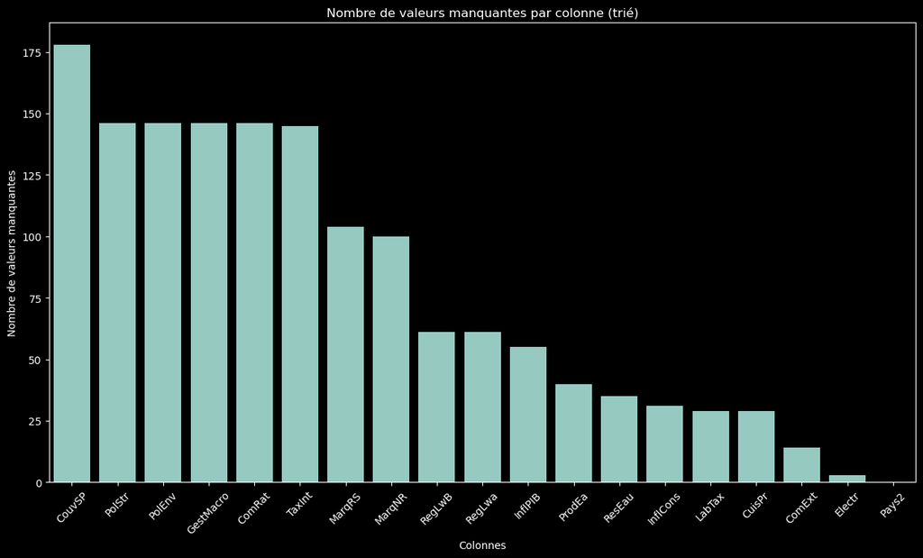

```python
# Calculer le nombre de valeurs manquantes pour chaque colonne
missing_count_columns = df_wdi.isnull().sum()

# Trier les colonnes par le nombre de valeurs manquantes pour un affichage plus clair
sorted_missing_count_columns = missing_count_columns.sort_values(ascending=False)

# Visualisation des valeurs manquantes par colonne (en nombre), triées
plt.figure(figsize=(15, 8))
sns.barplot(x=sorted_missing_count_columns.index, y=sorted_missing_count_columns)
plt.xticks(rotation=45)
plt.xlabel('Colonnes')
plt.ylabel('Nombre de valeurs manquantes')
plt.title('Nombre de valeurs manquantes par colonne (trié)')
plt.show()
```

Au vu des nombreuses valeurs manquantes présentes dans le data Frame, je choisi d'effectuer le traitement après la jointure afin de comptabilisé les valeurs en fonction des pays communs avec les autres df.

### 1.6.2 - Éxploration des données traitées

```python
df_wdi
```

|  | Pays2 | Electr | CuisPr | PolStr | PolEnv | GestMacro | InflPIB | InflCons | ComExt | TaxInt | ComRat | MarqNR | MarqRS | CouvSP | LabTax | RegLwa | RegLwB | ProdEa | ResEau |
| --- | --- | --- | --- | --- | --- | --- | --- | --- | --- | --- | --- | --- | --- | --- | --- | --- | --- | --- | --- |
| 0 | Afghanistan | 92.022222 | 31.288889 | 2.444445 | 2.388889 | 3.000000 | 3.446850 | 2.716775 | 41.648056 | 3.563549e+10 | 3.333333 | NaN | NaN | NaN | 0.000000 | 4.178982 | 1.216451 | 0.984053 | 1323.656076 |
| 1 | Africa Eastern and Southern | 41.699437 | 19.537872 | 3.078314 | 3.126316 | 3.133480 | NaN | 6.538987 | 46.754557 | NaN | 3.482018 | NaN | NaN | NaN | 7.984667 | NaN | NaN | 9.702217 | 3142.995232 |
| 2 | Africa Western and Central | 50.876576 | 15.143743 | 3.232500 | 3.312500 | 3.617500 | NaN | 2.938512 | 34.250474 | NaN | 3.845000 | NaN | NaN | NaN | 21.041667 | NaN | NaN | 25.358828 | 4411.788224 |
| 3 | Albania | 99.977778 | 80.411111 | NaN | NaN | NaN | 2.423204 | 2.290094 | 57.953799 | 7.516828e+09 | NaN | 7.020750e+03 | 1.211000e+03 | 27.168313 | 18.800000 | 41.530773 | 31.052883 | 12.197807 | 9378.821366 |
| 4 | Algeria | 99.577778 | 99.655556 | NaN | NaN | NaN | 4.117632 | 5.414083 | 42.891214 | NaN | NaN | 9.404833e+03 | 1.045917e+04 | NaN | 31.100000 | 20.581963 | 11.585027 | 20.588433 | 273.894672 |
| ... | ... | ... | ... | ... | ... | ... | ... | ... | ... | ... | ... | ... | ... | ... | ... | ... | ... | ... | ... |
| 261 | West Bank and Gaza | 99.966667 | NaN | NaN | NaN | NaN | 1.213804 | 1.465761 | NaN | 7.927242e+08 | NaN | NaN | NaN | 24.384756 | 0.000000 | 35.355233 | 21.112023 | 49.256621 | 181.858888 |
| 262 | World | 89.320471 | 68.269773 | 3.204474 | 3.164164 | 3.436032 | NaN | 3.148314 | 45.192718 | NaN | 3.759932 | 2.210000e+06 | 1.068615e+07 | NaN | 16.199247 | NaN | NaN | 20.252242 | 5682.713104 |
| 263 | Yemen, Rep. | 71.244444 | 53.688889 | 2.250000 | 2.650000 | 2.200000 | 17.436243 | 8.104726 | 22.566707 | NaN | 2.800000 | 1.838500e+03 | 3.305750e+03 | 42.857038 | 11.300000 | 3.709847 | 1.113156 | 11.404409 | 70.111774 |
| 264 | Zambia | 39.666667 | 11.833333 | 3.783334 | 3.500000 | 3.100000 | 10.483712 | 11.864096 | 68.424277 | 2.994206e+09 | 4.000000 | 3.586500e+03 | 1.052875e+03 | 2.314500 | 10.400000 | 38.322304 | 28.745393 | 14.361295 | 4649.761725 |
| 265 | Zimbabwe | 44.044444 | 30.277778 | 2.666667 | 3.850000 | 2.400000 | 227.554787 | 113.677610 | 47.283116 | 3.364024e+08 | 2.850000 | 2.389000e+03 | 2.500000e+02 | 26.028645 | 5.550000 | 7.505318 | 4.386572 | 5.736008 | 832.247001 |

266 rows × 19 columns

```python
df_wdi.info()
```

```
<class 'pandas.core.frame.DataFrame'>
RangeIndex: 266 entries, 0 to 265
Data columns (total 19 columns):
 #   Column     Non-Null Count  Dtype
---  ------     --------------  -----
 0   Pays2      266 non-null    object
 1   Electr     263 non-null    float64
 2   CuisPr     237 non-null    float64
 3   PolStr     120 non-null    float64
 4   PolEnv     120 non-null    float64
 5   GestMacro  120 non-null    float64
 6   InflPIB    211 non-null    float64
 7   InflCons   235 non-null    float64
 8   ComExt     252 non-null    float64
 9   TaxInt     121 non-null    float64
 10  ComRat     120 non-null    float64
 11  MarqNR     166 non-null    float64
 12  MarqRS     162 non-null    float64
 13  CouvSP     88 non-null     float64
 14  LabTax     237 non-null    float64
 15  RegLwa     205 non-null    float64
 16  RegLwB     205 non-null    float64
 17  ProdEa     226 non-null    float64
 18  ResEau     231 non-null    float64
dtypes: float64(18), object(1)
memory usage: 39.6+ KB
```

```python
df_wdi.describe(include='all')
```

|  | Pays2 | Electr | CuisPr | PolStr | PolEnv | GestMacro | InflPIB | InflCons | ComExt | TaxInt | ComRat | MarqNR | MarqRS | CouvSP | LabTax | RegLwa | RegLwB | ProdEa | ResEau |
| --- | --- | --- | --- | --- | --- | --- | --- | --- | --- | --- | --- | --- | --- | --- | --- | --- | --- | --- | --- |
| count | 266 | 263.000000 | 237.000000 | 120.000000 | 120.000000 | 120.000000 | 211.000000 | 235.000000 | 252.000000 | 1.210000e+02 | 120.000000 | 1.660000e+02 | 1.620000e+02 | 88.000000 | 237.000000 | 205.000000 | 205.000000 | 226.000000 | 231.000000 |
| unique | 266 | NaN | NaN | NaN | NaN | NaN | NaN | NaN | NaN | NaN | NaN | NaN | NaN | NaN | NaN | NaN | NaN | NaN | NaN |
| top | Afghanistan | NaN | NaN | NaN | NaN | NaN | NaN | NaN | NaN | NaN | NaN | NaN | NaN | NaN | NaN | NaN | NaN | NaN | NaN |
| freq | 1 | NaN | NaN | NaN | NaN | NaN | NaN | NaN | NaN | NaN | NaN | NaN | NaN | NaN | NaN | NaN | NaN | NaN | NaN |
| mean | NaN | 84.965368 | 66.408275 | 3.210431 | 3.164336 | 3.437259 | 6.967720 | 6.496099 | 61.701058 | 2.623233e+11 | 3.768622 | 5.026504e+04 | 2.527358e+05 | 45.601460 | 16.041421 | 49.245924 | 40.207886 | 68.428648 | 14089.150988 |
| std | NaN | 24.398974 | 36.676572 | 0.425098 | 0.490746 | 0.540610 | 18.116528 | 15.168981 | 37.357765 | 9.346165e+11 | 0.496235 | 2.095700e+05 | 1.200948e+06 | 25.280827 | 9.897376 | 28.801852 | 28.102135 | 162.506157 | 42628.008655 |
| min | NaN | 6.122222 | 0.000000 | 1.216666 | 1.200000 | 1.450000 | -4.505476 | -0.566269 | 14.279551 | -6.711111e+07 | 1.550000 | 1.127500e+02 | 5.600000e+00 | 1.188782 | 0.000000 | 0.105820 | 0.000000 | 0.895692 | 0.000000 |
| 25% | NaN | 81.111111 | 31.288889 | 3.070789 | 3.000000 | 3.150000 | 1.936297 | 2.063273 | 40.884968 | 3.233532e+08 | 3.500000 | 2.299375e+03 | 7.812500e+02 | 25.811755 | 9.783333 | 24.299431 | 15.247608 | 8.568280 | 1024.269958 |
| 50% | NaN | 99.165228 | 83.254272 | 3.241667 | 3.222503 | 3.436224 | 2.907824 | 3.075287 | 51.128089 | 4.034309e+09 | 3.866998 | 6.208580e+03 | 4.007375e+03 | 46.601994 | 14.355072 | 47.772729 | 36.403883 | 19.037196 | 3170.751309 |
| 75% | NaN | 100.000000 | 100.000000 | 3.473333 | 3.500000 | 3.872500 | 5.601904 | 5.193248 | 70.474689 | 5.251193e+10 | 4.032812 | 1.506200e+04 | 2.733906e+04 | 65.318062 | 21.050000 | 73.333353 | 60.953119 | 56.364737 | 9551.915606 |
| max | NaN | 100.000000 | 100.000000 | 4.166667 | 4.250000 | 4.500000 | 227.554787 | 146.285090 | 340.979907 | 7.151798e+12 | 4.600000 | 2.210000e+06 | 1.068615e+07 | 92.985558 | 51.966667 | 100.000000 | 95.768080 | 1343.999682 | 493191.628992 |

# 2 - HARMONISATION DES CLES DE JONCTION

## 2.1 - Liste des noms dans chaque dataframes

```python
# Supprimer les espaces blancs au début et à la fin des noms de pays
df_population['Pays'] = df_population['Pays'].str.strip()
df_alimentaire['Pays'] = df_alimentaire['Pays'].str.strip()
df_sous_nutrition['Pays'] = df_sous_nutrition['Pays'].str.strip()
df_pays['Pays'] = df_pays['Pays'].str.strip()
df_pays['Pays2'] = df_pays['Pays2'].str.strip()
df_wdi['Pays2'] = df_wdi['Pays2'].str.strip()
df_water['Pays2'] = df_water['Pays2'].str.strip()
```

```python
print("Noms de pays dans df_alimentaire:", df_alimentaire['Pays'].unique())
print("Noms de pays dans df_population:", df_population['Pays'].unique())
print("Noms de pays dans df_sous_nutri:", df_sous_nutri['Pays'].unique())
print("Noms de pays2 dans df_water:", df_water['Pays2'].unique())
print("Noms de pays2 dans df_wdi:", df_wdi['Pays2'].unique())
print("Noms de pays dans df_pays:", df_pays['Pays'].unique())
print("Noms de pays2 dans df_pays:", df_pays['Pays2'].unique())
```

```
Noms de pays dans df_alimentaire: ['Afghanistan' 'Afrique du Sud' 'Albanie' 'Algérie' 'Allemagne' 'Angola'
 'Antigua-et-Barbuda' 'Arabie saoudite' 'Argentine' 'Arménie' 'Australie'
 'Autriche' 'Azerbaïdjan' 'Bahamas' 'Bangladesh' 'Barbade' 'Belgique'
 'Belize' 'Bermudes' 'Bolivie (État plurinational de)'
 'Bosnie-Herzégovine' 'Botswana' 'Brunéi Darussalam' 'Brésil' 'Bulgarie'
 'Burkina Faso' 'Bélarus' 'Bénin' 'Cabo Verde' 'Cambodge' 'Cameroun'
 'Canada' 'Chili' 'Chine - RAS de Hong-Kong' 'Chine - RAS de Macao'
 'Chine, Taiwan Province de' 'Chine, continentale' 'Chypre' 'Colombie'
 'Congo' 'Costa Rica' 'Croatie' 'Cuba' "Côte d'Ivoire" 'Danemark'
 'Djibouti' 'Dominique' 'El Salvador' 'Espagne' 'Estonie' 'Eswatini'
 'Fidji' 'Finlande' 'France' 'Fédération de Russie' 'Gabon' 'Gambie'
 'Ghana' 'Grenade' 'Grèce' 'Guatemala' 'Guinée' 'Guinée-Bissau' 'Guyana'
 'Géorgie' 'Haïti' 'Honduras' 'Hongrie' 'Inde' 'Indonésie'
 "Iran (République islamique d')" 'Iraq' 'Irlande' 'Islande' 'Israël'
 'Italie' 'Jamaïque' 'Japon' 'Jordanie' 'Kazakhstan' 'Kenya'
 'Kirghizistan' 'Kiribati' 'Koweït' 'Lesotho' 'Lettonie' 'Liban' 'Libéria'
 'Lituanie' 'Luxembourg' 'Macédoine du Nord' 'Madagascar' 'Malaisie'
 'Malawi' 'Maldives' 'Mali' 'Malte' 'Maroc' 'Maurice' 'Mauritanie'
 'Mexique' 'Mongolie' 'Monténégro' 'Mozambique' 'Myanmar' 'Namibie'
 'Nicaragua' 'Niger' 'Nigéria' 'Norvège' 'Nouvelle-Calédonie'
 'Nouvelle-Zélande' 'Népal' 'Oman' 'Ouganda' 'Ouzbékistan' 'Pakistan'
 'Panama' 'Paraguay' 'Pays-Bas' 'Philippines' 'Pologne'
 'Polynésie française' 'Portugal' 'Pérou' 'Roumanie'
 "Royaume-Uni de Grande-Bretagne et d'Irlande du Nord" 'Rwanda'
 'République centrafricaine' 'République de Corée' 'République de Moldova'
 'République dominicaine' 'République démocratique populaire lao'
 'République populaire démocratique de Corée'
 'République-Unie de Tanzanie' 'Saint-Kitts-et-Nevis'
 'Saint-Vincent-et-les Grenadines' 'Sainte-Lucie' 'Samoa'
 'Sao Tomé-et-Principe' 'Serbie' 'Sierra Leone' 'Slovaquie' 'Slovénie'
 'Soudan' 'Sri Lanka' 'Suisse' 'Suriname' 'Suède' 'Sénégal' 'Tadjikistan'
 'Tchad' 'Tchéquie' 'Thaïlande' 'Timor-Leste' 'Togo' 'Trinité-et-Tobago'
 'Tunisie' 'Turkménistan' 'Turquie' 'Ukraine' 'Uruguay' 'Vanuatu'
 'Venezuela (République bolivarienne du)' 'Viet Nam' 'Yémen' 'Zambie'
 'Zimbabwe' 'Égypte' 'Émirats arabes unis' 'Équateur'
 "États-Unis d'Amérique" 'Éthiopie' 'Îles Salomon']
Noms de pays dans df_population: ['Afghanistan' 'Afrique du Sud' 'Albanie' 'Algérie' 'Allemagne' 'Andorre'
 'Angola' 'Anguilla' 'Antigua-et-Barbuda' 'Antilles néerlandaises (ex)'
 'Arabie saoudite' 'Argentine' 'Arménie' 'Aruba' 'Australie' 'Autriche'
 'Azerbaïdjan' 'Bahamas' 'Bahreïn' 'Bangladesh' 'Barbade' 'Bélarus'
```

[output cut: 298 more lines]

```
 'Saint Helena, Ascension and Tristan da Cunha' 'Saint Lucia'
 'Saint Kitts and Nevis' 'San Marino' 'Saint Martin (French part)'
 'Sint Maarten (Dutch part)' 'Saint Pierre and Miquelon' 'Holy See'
 'Saint Vincent and the Grenadines' 'Solomon Islands' 'Samoa'
 'American Samoa' 'Sao Tome and Principe' 'Senegal' 'Serbia' 'Seychelles'
 'Sierra Leone' 'Singapore' 'Slovakia' 'Slovenia' 'Somalia' 'Sudan'
 'South Sudan' 'Sri Lanka' 'Sweden' 'Switzerland' 'Suriname'
 'Svalbard and Jan Mayen' 'Tajikistan' 'Taiwan (Province of China)'
 'Tanzania, the United Republic of' 'Chad' 'Czechia'
 'French Southern Territories' 'Thailand' 'Timor-Leste' 'Togo' 'Tokelau'
 'Tonga' 'Trinidad and Tobago' 'Tunisia' 'Turkmenistan'
 'Turks and Caicos Islands' 'Turkey' 'Tuvalu' 'Ukraine' 'Uruguay'
 'Vanuatu' 'Venezuela (Bolivarian Republic of)' 'Virgin Islands (British)'
 'Virgin Islands (U.S.)' 'Viet Nam' 'Wallis and Futuna' 'Yemen' 'Zambia'
 'Zimbabwe']
```

## 2.2 - Noms francais ['Pays'] pour df_alimentaire df_population df_sous_nutri et df_pays

```python
# Dictionnaire de correspondance Français
correspondance_pays = {
    "Fédération de Russie": "Russie (la Fédération de)",
    "République centrafricaine": "République centrAfriqueine",
    "République de Corée": "Corée (la République de)",
    "République démocratique populaire lao": "Lao (la République démocratique populaire)",
    "République populaire démocratique de Corée": "Corée (la\xa0République populaire démocratique de)",
    "République-Unie de Tanzanie": "Tanzanie (la République-Unie de)",
    "Chine, continentale": "Chine",
    "Chine, Taiwan Province de": "Taïwan (Province de Chine)",
    "République dominicaine": "dominicaine (la\xa0République)",
    "Îles Salomon": "Salomon (les Îles)",
    "République de Moldova": "Moldavie (la République de)",
    "Chine - RAS de Hong-Kong": "Hong Kong",
    "Chine - RAS de Macao": "Macao",
    "Sainte-Lucie": "Sainte-Lucie",
    "Iran (République islamique d')": "Iran (République Islamique d')",
    'République démocratique du Congo': 'Congo (la République démocratique du)',
    'Îles Féroé': 'Féroé (les Îles)',
    'Palestine': 'Palestine, État de',
    'Îles Turques-et-Caïques': 'Turks-et-Caïcos (les Îles)',
    'Îles Cook': 'Cook (les Îles)',
    'Îles Caïmanes': 'Caïmans (les\xa0Îles)',
    'Îles Vierges britanniques': 'Vierges britanniques (les\xa0Îles)',
    'Îles Vierges américaines': 'Vierges des États-Unis (les Îles)',
    'Îles Wallis-et-Futuna': 'Wallis-et-Futuna',
    'Îles Mariannes du Nord': 'Mariannes du Nord (les Îles)',
    'Tokélaou': 'Tokelau',
    'Îles Falkland (Malvinas)': 'Falkland (les Îles) /Malouines (les Îles)',
    'Guyane française': 'Guyane française (la)',
    'Îles Marshall': 'Marshall (les Îles)',
     "Nioué" : 'Niue'
}


# Appliquer le dictionnaire aux DataFrames
df_alimentaire['Pays'] = df_alimentaire['Pays'].replace(correspondance_pays)
df_population['Pays'] = df_population['Pays'].replace(correspondance_pays)
df_sous_nutri['Pays'] = df_sous_nutri['Pays'].replace(correspondance_pays)


# Vérification (affiche les pays qui ne correspondent pas après remplacement)

def check_correspondance(df, df_ref, nom_df):
    pays_non_trouves = set(df['Pays']) - set(df_ref['Pays'])
    if pays_non_trouves:
        print(f"Pays de {nom_df} non trouvés dans df_pays après remplacement : {pays_non_trouves}")

check_correspondance(df_alimentaire, df_pays, "df_alimentaire")
check_correspondance(df_population, df_pays, "df_population")
check_correspondance(df_sous_nutri, df_pays, "df_sous_nutri")
```

```
Pays de df_population non trouvés dans df_pays après remplacement : {'Antilles néerlandaises (ex)', 'Îles Anglo-Normandes'}
```

**CONCLUSION**

Pays de **df_population** non trouvés dans **df_pays** après remplacement : {'Antilles néerlandaises (ex)', 'Îles Anglo-Normandes'}

**Antilles néerlandaises (ex):**

Aruba: Présent dans df_pays, df_population, df_sous_nutri et df_wdi.

Curaçao: Présent dans df_pays, df_population et df_wdi.

Sint Maarten (Dutch part): Présent dans df_pays et df_wdi.

Bonaire, Saint-Eustache et Saba: Présent dans df_pays sous le nom 'Bonaire, Sint Eustatius and Saba'.

**Îles Anglo-Normandes:**

Guernesey: Présent dans df_pays.

Jersey: Présent dans df_pays et df_population.

## 2.3 - Noms anglais ['Pays2'] pour df_wdi , df_water , df_pays

```python
# Dictionnaire de correspondance Anglais
correspondance_pays = {
    'Bahamas, The': 'Bahamas',
    'Bolivia': 'Bolivia (Plurinational State of)',
    'British Virgin Islands': 'Virgin Islands (British)',
    "Cote d'Ivoire": "Côte d'Ivoire",
    'Congo, Dem. Rep.': 'Congo (the Democratic Republic of the)',
    'Congo, Rep.': 'Congo',
    'Egypt, Arab Rep.': 'Egypt',
    'Gambia, The': 'Gambia',
    'Iran, Islamic Rep.': 'Iran (Islamic Republic of)',
    "Korea, Dem. People's Rep.": "Korea (the Democratic People's Republic of)",
    'Korea, Rep.': 'Korea (the Republic of)',
    'Kyrgyz Republic': 'Kyrgyzstan',
    'Lao PDR': "Lao People's Democratic Republic",
    'Micronesia, Fed. Sts.': 'Micronesia (Federated States of)',
    'Moldova': 'Moldova (the Republic of)',
    'North Macedonia': 'North Macedonia',
    'Russian Federation': 'Russian Federation',
    'Sint Maarten (Dutch part)': 'Sint Maarten (Dutch part)',
    'Slovak Republic': 'Slovakia',
    'St. Kitts and Nevis': 'Saint Kitts and Nevis',
    'St. Lucia': 'Saint Lucia',
    'St. Vincent and the Grenadines': 'Saint Vincent and the Grenadines',
    'Tanzania': 'Tanzania, the United Republic of',
    'Turkiye': 'Turkey',
    'United Kingdom': 'United Kingdom of Great Britain and Northern Ireland',
    'United States': 'United States of America',
    'Venezuela, RB': 'Venezuela (Bolivarian Republic of)',
    'Yemen, Rep.': 'Yemen',
    'Central African Republic': 'Central African Republic',
    'Curacao': 'Curaçao',
    'Hong Kong SAR, China': 'Hong Kong',
    'Macao SAR, China': 'Macao',
    'St. Martin (French part)': 'Saint Martin (French part)',
    'Central African Republic': 'Central Afriquen Republic',
    'Republic of Korea': 'Korea (the Republic of)',
    'Republic of North Macedonia': 'North Macedonia',
    'United Republic of Tanzania': 'Tanzania, the United Republic of',
    'Republic of Moldova': 'Moldova (the Republic of)',
    "Democratic People's Republic of Korea": "Korea (the Democratic People's Republic of)",
    'Democratic Republic of the Congo': 'Congo (the Democratic Republic of the)'
}

# Dictionnaire anglais (Pays2) pour df_pays
correspondance_df_pays = {
    "Korea (the Democratic People's Republic of)": "Korea (the Democratic People's Republic of)",
    "Korea (the Republic of)": "Korea (the Republic of)",
    "Republic of North Macedonia": "North Macedonia",
    "Congo (the Democratic Republic of the)": "Congo (the Democratic Republic of the)",
    "Tanzania, the United Republic of": "Tanzania, the United Republic of",
    "Moldova (the Republic of)": "Moldova (the Republic of)"
}


# Supprimer les régions de df_wdi:

regions_a_supprimer = {
    'East Asia & Pacific (IDA & IBRD countries)', 'Low income', 'Euro area', 'IDA blend',
    'Low & middle income', 'Europe & Central Asia', 'Pre-demographic dividend',
    'Latin America & Caribbean (excluding high income)', 'Early-demographic dividend',
    'Channel Islands', 'Post-demographic dividend', 'Upper middle income', 'South Asia',
    'West Bank and Gaza', 'East Asia & Pacific (excluding high income)',
    'Middle East & North Africa (excluding high income)', 'Middle East & North Africa',
    'South Asia (IDA & IBRD)', 'Sub-Saharan Africa (excluding high income)', 'Small states',
    'Fragile and conflict affected situations', 'Kosovo', 'OECD members',
    'Europe & Central Asia (excluding high income)', 'IDA & IBRD total',
    'Africa Western and Central', 'Africa Eastern and Southern', 'Pacific island small states',
    'Middle income', 'Other small states', 'High income', 'Sub-Saharan Africa (IDA & IBRD countries)',
    'Late-demographic dividend', 'North America', 'Lower middle income', 'IBRD only',
    'Central Europe and the Baltics', 'Latin America & Caribbean',
    'Latin America & the Caribbean (IDA & IBRD countries)',
    'Least developed countries: UN classification', 'World', 'IDA total',
    'Heavily indebted poor countries (HIPC)', 'Europe & Central Asia (IDA & IBRD countries)',
    'Middle East & North Africa (IDA & IBRD countries)', 'Sub-Saharan Africa', 'IDA only',
    'European Union', 'East Asia & Pacific', 'Not classified', 'Caribbean small states', 'Arab World'
}

df_wdi = df_wdi[~df_wdi['Pays2'].isin(regions_a_supprimer)]


# Appliquer les dictionnaires aux DataFrames

df_pays.loc[:, 'Pays2'] = df_pays['Pays2'].replace(correspondance_df_pays)

df_wdi.loc[:, 'Pays2'] = df_wdi['Pays2'].replace(correspondance_pays)
df_water.loc[:, 'Pays2'] = df_water['Pays2'].replace(correspondance_pays)

# Affiche les pays qui ne correspondent pas après remplacement

def check_correspondance(df, df_ref, nom_df):
    pays_non_trouves = set(df['Pays2']) - set(df_ref['Pays2'])
    if pays_non_trouves:
        print(f"Pays2 de {nom_df} non trouvés dans df_pays après remplacement : {pays_non_trouves}")

check_correspondance(df_wdi, df_pays, "df_wdi")
print('\n')
check_correspondance(df_water, df_pays, "df_water")
```

**CONCLUSION**

Corespondance parfaite 'Pays2'

# 3 - JONCTION DES FICHIERS

## 3.1 - Réalisation de la jointure entre df_alimentaire et df_pays

```python
# Jointure avec clé 'Pays'
df_merge = df_pays.merge(df_alimentaire, on='Pays', how='left')
df_merge
```

|  | Code Pays | Pays | Pays2 | AlimTouris | AlimAnimau | AutrUtilis | DispAlimK | DispAlimQ | DispMatiG | DispProtG | DispInter | ExpoQuant | ImpoQuant | Nourriture | PertesVol | Productio | ResidusVo | SemencesVo | Traitement | VarStockV | TauxDepImpo | TauxSuffisa |
| --- | --- | --- | --- | --- | --- | --- | --- | --- | --- | --- | --- | --- | --- | --- | --- | --- | --- | --- | --- | --- | --- | --- |
| 0 | AFG | Afghanistan | Afghanistan | 0.0 | 0.0 | 0.0 | 5.0 | 1.53 | 0.33 | 0.54 | 57.0 | 0.0 | 29.0 | 55.0 | 2.0 | 28.0 | 0.0 | 0.0 | 0.0 | 0.0 | 0.000000 | 0.491228 |
| 1 | ZAF | Afrique du Sud | South Africa | 0.0 | 0.0 | 0.0 | 143.0 | 35.69 | 9.25 | 14.11 | 2118.0 | 63.0 | 514.0 | 2035.0 | 83.0 | 1667.0 | 0.0 | 0.0 | 0.0 | -0.0 | 0.242682 | 0.787063 |
| 2 | ALA | Åland (les Îles) | Åland Islands | NaN | NaN | NaN | NaN | NaN | NaN | NaN | NaN | NaN | NaN | NaN | NaN | NaN | NaN | NaN | NaN | NaN | NaN | NaN |
| 3 | ALB | Albanie | Albania | 0.0 | 0.0 | 0.0 | 85.0 | 16.36 | 6.45 | 6.26 | 47.0 | 0.0 | 38.0 | 47.0 | 0.0 | 13.0 | 0.0 | 0.0 | 0.0 | 4.0 | 0.745098 | 0.276596 |
| 4 | DZA | Algérie | Algeria | 0.0 | 0.0 | 0.0 | 22.0 | 6.38 | 1.50 | 1.97 | 277.0 | 0.0 | 2.0 | 264.0 | 13.0 | 275.0 | 0.0 | 0.0 | 0.0 | 0.0 | 0.007220 | 0.992780 |
| ... | ... | ... | ... | ... | ... | ... | ... | ... | ... | ... | ... | ... | ... | ... | ... | ... | ... | ... | ... | ... | ... | ... |
| 244 | VNM | Viet Nam | Viet Nam | 0.0 | 0.0 | 0.0 | 48.0 | 12.33 | 3.40 | 4.01 | 1206.0 | 1.0 | 291.0 | 1166.0 | 39.0 | 918.0 | 0.0 | 0.0 | 0.0 | 2.0 | 0.240894 | 0.761194 |
| 245 | WLF | Wallis-et-Futuna | Wallis and Futuna | NaN | NaN | NaN | NaN | NaN | NaN | NaN | NaN | NaN | NaN | NaN | NaN | NaN | NaN | NaN | NaN | NaN | NaN | NaN |
| 246 | YEM | Yémen | Yemen | 0.0 | 0.0 | 0.0 | 30.0 | 8.53 | 1.85 | 3.04 | 246.0 | 0.0 | 78.0 | 237.0 | 8.0 | 168.0 | 0.0 | 0.0 | 0.0 | -0.0 | 0.317073 | 0.682927 |
| 247 | ZMB | Zambie | Zambia | 0.0 | 0.0 | 0.0 | 11.0 | 3.42 | 0.72 | 1.15 | 60.0 | 1.0 | 12.0 | 58.0 | 2.0 | 49.0 | 0.0 | 0.0 | 0.0 | -0.0 | 0.200000 | 0.816667 |
| 248 | ZWE | Zimbabwe | Zimbabwe | 0.0 | 0.0 | 0.0 | 16.0 | 4.68 | 0.99 | 1.59 | 76.0 | 0.0 | 6.0 | 67.0 | 3.0 | 69.0 | 0.0 | 0.0 | 6.0 | -0.0 | 0.000000 | 0.907895 |

249 rows × 22 columns

## 3.2 - Réalisation de la jointure entre df_merge et df_sous_nutri

```python
# Jointure avec clé 'Pays'
df_merge2 = df_merge.merge(df_sous_nutri, on='Pays', how='left')
df_merge2
```

|  | Code Pays | Pays | Pays2 | AlimTouris | AlimAnimau | AutrUtilis | DispAlimK | DispAlimQ | DispMatiG | DispProtG | DispInter | ExpoQuant | ImpoQuant | Nourriture | PertesVol | Productio | ResidusVo | SemencesVo | Traitement | VarStockV | TauxDepImpo | TauxSuffisa | Sous_nutrition |
| --- | --- | --- | --- | --- | --- | --- | --- | --- | --- | --- | --- | --- | --- | --- | --- | --- | --- | --- | --- | --- | --- | --- | --- |
| 0 | AFG | Afghanistan | Afghanistan | 0.0 | 0.0 | 0.0 | 5.0 | 1.53 | 0.33 | 0.54 | 57.0 | 0.0 | 29.0 | 55.0 | 2.0 | 28.0 | 0.0 | 0.0 | 0.0 | 0.0 | 0.000000 | 0.491228 | 9.600000 |
| 1 | ZAF | Afrique du Sud | South Africa | 0.0 | 0.0 | 0.0 | 143.0 | 35.69 | 9.25 | 14.11 | 2118.0 | 63.0 | 514.0 | 2035.0 | 83.0 | 1667.0 | 0.0 | 0.0 | 0.0 | -0.0 | 0.242682 | 0.787063 | 2.816667 |
| 2 | ALA | Åland (les Îles) | Åland Islands | NaN | NaN | NaN | NaN | NaN | NaN | NaN | NaN | NaN | NaN | NaN | NaN | NaN | NaN | NaN | NaN | NaN | NaN | NaN | NaN |
| 3 | ALB | Albanie | Albania | 0.0 | 0.0 | 0.0 | 85.0 | 16.36 | 6.45 | 6.26 | 47.0 | 0.0 | 38.0 | 47.0 | 0.0 | 13.0 | 0.0 | 0.0 | 0.0 | 4.0 | 0.745098 | 0.276596 | 0.100000 |
| 4 | DZA | Algérie | Algeria | 0.0 | 0.0 | 0.0 | 22.0 | 6.38 | 1.50 | 1.97 | 277.0 | 0.0 | 2.0 | 264.0 | 13.0 | 275.0 | 0.0 | 0.0 | 0.0 | 0.0 | 0.007220 | 0.992780 | 1.283333 |
| ... | ... | ... | ... | ... | ... | ... | ... | ... | ... | ... | ... | ... | ... | ... | ... | ... | ... | ... | ... | ... | ... | ... | ... |
| 244 | VNM | Viet Nam | Viet Nam | 0.0 | 0.0 | 0.0 | 48.0 | 12.33 | 3.40 | 4.01 | 1206.0 | 1.0 | 291.0 | 1166.0 | 39.0 | 918.0 | 0.0 | 0.0 | 0.0 | 2.0 | 0.240894 | 0.761194 | 7.416667 |
| 245 | WLF | Wallis-et-Futuna | Wallis and Futuna | NaN | NaN | NaN | NaN | NaN | NaN | NaN | NaN | NaN | NaN | NaN | NaN | NaN | NaN | NaN | NaN | NaN | NaN | NaN | NaN |
| 246 | YEM | Yémen | Yemen | 0.0 | 0.0 | 0.0 | 30.0 | 8.53 | 1.85 | 3.04 | 246.0 | 0.0 | 78.0 | 237.0 | 8.0 | 168.0 | 0.0 | 0.0 | 0.0 | -0.0 | 0.317073 | 0.682927 | 0.000000 |
| 247 | ZMB | Zambie | Zambia | 0.0 | 0.0 | 0.0 | 11.0 | 3.42 | 0.72 | 1.15 | 60.0 | 1.0 | 12.0 | 58.0 | 2.0 | 49.0 | 0.0 | 0.0 | 0.0 | -0.0 | 0.200000 | 0.816667 | 0.000000 |
| 248 | ZWE | Zimbabwe | Zimbabwe | 0.0 | 0.0 | 0.0 | 16.0 | 4.68 | 0.99 | 1.59 | 76.0 | 0.0 | 6.0 | 67.0 | 3.0 | 69.0 | 0.0 | 0.0 | 6.0 | -0.0 | 0.000000 | 0.907895 | 0.000000 |

249 rows × 23 columns

## 3.3 - Réalisation de la jointure entre df_merge2 et df_population

```python
# Jointure avec clé 'Pays'
df_merge3 = df_merge2.merge(df_population, on='Pays', how='left')
df_merge3
```

|  | Code Pays | Pays | Pays2 | AlimTouris | AlimAnimau | AutrUtilis | DispAlimK | DispAlimQ | DispMatiG | DispProtG | DispInter | ExpoQuant | ImpoQuant | Nourriture | PertesVol | Productio | ResidusVo | SemencesVo | Traitement | VarStockV | TauxDepImpo | TauxSuffisa | Sous_nutrition | Pop2018 | PopDiff |
| --- | --- | --- | --- | --- | --- | --- | --- | --- | --- | --- | --- | --- | --- | --- | --- | --- | --- | --- | --- | --- | --- | --- | --- | --- | --- |
| 0 | AFG | Afghanistan | Afghanistan | 0.0 | 0.0 | 0.0 | 5.0 | 1.53 | 0.33 | 0.54 | 57.0 | 0.0 | 29.0 | 55.0 | 2.0 | 28.0 | 0.0 | 0.0 | 0.0 | 0.0 | 0.000000 | 0.491228 | 9.600000 | 37171.921 | 78.884 |
| 1 | ZAF | Afrique du Sud | South Africa | 0.0 | 0.0 | 0.0 | 143.0 | 35.69 | 9.25 | 14.11 | 2118.0 | 63.0 | 514.0 | 2035.0 | 83.0 | 1667.0 | 0.0 | 0.0 | 0.0 | -0.0 | 0.242682 | 0.787063 | 2.816667 | 57792.518 | 28.520 |
| 2 | ALA | Åland (les Îles) | Åland Islands | NaN | NaN | NaN | NaN | NaN | NaN | NaN | NaN | NaN | NaN | NaN | NaN | NaN | NaN | NaN | NaN | NaN | NaN | NaN | NaN | NaN | NaN |
| 3 | ALB | Albanie | Albania | 0.0 | 0.0 | 0.0 | 85.0 | 16.36 | 6.45 | 6.26 | 47.0 | 0.0 | 38.0 | 47.0 | 0.0 | 13.0 | 0.0 | 0.0 | 0.0 | 4.0 | 0.745098 | 0.276596 | 0.100000 | 2882.740 | -7.877 |
| 4 | DZA | Algérie | Algeria | 0.0 | 0.0 | 0.0 | 22.0 | 6.38 | 1.50 | 1.97 | 277.0 | 0.0 | 2.0 | 264.0 | 13.0 | 275.0 | 0.0 | 0.0 | 0.0 | 0.0 | 0.007220 | 0.992780 | 1.283333 | 42228.408 | 36.035 |
| ... | ... | ... | ... | ... | ... | ... | ... | ... | ... | ... | ... | ... | ... | ... | ... | ... | ... | ... | ... | ... | ... | ... | ... | ... | ... |
| 244 | VNM | Viet Nam | Viet Nam | 0.0 | 0.0 | 0.0 | 48.0 | 12.33 | 3.40 | 4.01 | 1206.0 | 1.0 | 291.0 | 1166.0 | 39.0 | 918.0 | 0.0 | 0.0 | 0.0 | 2.0 | 0.240894 | 0.761194 | 7.416667 | 95545.962 | 19.566 |
| 245 | WLF | Wallis-et-Futuna | Wallis and Futuna | NaN | NaN | NaN | NaN | NaN | NaN | NaN | NaN | NaN | NaN | NaN | NaN | NaN | NaN | NaN | NaN | NaN | NaN | NaN | NaN | 11.661 | -20.641 |
| 246 | YEM | Yémen | Yemen | 0.0 | 0.0 | 0.0 | 30.0 | 8.53 | 1.85 | 3.04 | 246.0 | 0.0 | 78.0 | 237.0 | 8.0 | 168.0 | 0.0 | 0.0 | 0.0 | -0.0 | 0.317073 | 0.682927 | 0.000000 | 28498.683 | 63.700 |
| 247 | ZMB | Zambie | Zambia | 0.0 | 0.0 | 0.0 | 11.0 | 3.42 | 0.72 | 1.15 | 60.0 | 1.0 | 12.0 | 58.0 | 2.0 | 49.0 | 0.0 | 0.0 | 0.0 | -0.0 | 0.200000 | 0.816667 | 0.000000 | 17351.708 | 66.588 |
| 248 | ZWE | Zimbabwe | Zimbabwe | 0.0 | 0.0 | 0.0 | 16.0 | 4.68 | 0.99 | 1.59 | 76.0 | 0.0 | 6.0 | 67.0 | 3.0 | 69.0 | 0.0 | 0.0 | 6.0 | -0.0 | 0.000000 | 0.907895 | 0.000000 | 14438.802 | 21.524 |

249 rows × 25 columns

## 3.4 - Réalisation de la jointure entre df_merge3 et df_water

```python
# Jointure avec clé 'Pays2'
df_merge4 = df_merge3.merge(df_water, on='Pays2', how='left')
df_merge4
```

|  | Code Pays | Pays | Pays2 | AlimTouris | AlimAnimau | AutrUtilis | DispAlimK | DispAlimQ | DispMatiG | DispProtG | DispInter | ExpoQuant | ImpoQuant | Nourriture | PertesVol | Productio | ResidusVo | SemencesVo | Traitement | VarStockV | TauxDepImpo | TauxSuffisa | Sous_nutrition | Pop2018 | PopDiff | Drink |
| --- | --- | --- | --- | --- | --- | --- | --- | --- | --- | --- | --- | --- | --- | --- | --- | --- | --- | --- | --- | --- | --- | --- | --- | --- | --- | --- |
| 0 | AFG | Afghanistan | Afghanistan | 0.0 | 0.0 | 0.0 | 5.0 | 1.53 | 0.33 | 0.54 | 57.0 | 0.0 | 29.0 | 55.0 | 2.0 | 28.0 | 0.0 | 0.0 | 0.0 | 0.0 | 0.000000 | 0.491228 | 9.600000 | 37171.921 | 78.884 | 67.065 |
| 1 | ZAF | Afrique du Sud | South Africa | 0.0 | 0.0 | 0.0 | 143.0 | 35.69 | 9.25 | 14.11 | 2118.0 | 63.0 | 514.0 | 2035.0 | 83.0 | 1667.0 | 0.0 | 0.0 | 0.0 | -0.0 | 0.242682 | 0.787063 | 2.816667 | 57792.518 | 28.520 | 92.679 |
| 2 | ALA | Åland (les Îles) | Åland Islands | NaN | NaN | NaN | NaN | NaN | NaN | NaN | NaN | NaN | NaN | NaN | NaN | NaN | NaN | NaN | NaN | NaN | NaN | NaN | NaN | NaN | NaN | NaN |
| 3 | ALB | Albanie | Albania | 0.0 | 0.0 | 0.0 | 85.0 | 16.36 | 6.45 | 6.26 | 47.0 | 0.0 | 38.0 | 47.0 | 0.0 | 13.0 | 0.0 | 0.0 | 0.0 | 4.0 | 0.745098 | 0.276596 | 0.100000 | 2882.740 | -7.877 | 91.039 |
| 4 | DZA | Algérie | Algeria | 0.0 | 0.0 | 0.0 | 22.0 | 6.38 | 1.50 | 1.97 | 277.0 | 0.0 | 2.0 | 264.0 | 13.0 | 275.0 | 0.0 | 0.0 | 0.0 | 0.0 | 0.007220 | 0.992780 | 1.283333 | 42228.408 | 36.035 | 93.556 |
| ... | ... | ... | ... | ... | ... | ... | ... | ... | ... | ... | ... | ... | ... | ... | ... | ... | ... | ... | ... | ... | ... | ... | ... | ... | ... | ... |
| 244 | VNM | Viet Nam | Viet Nam | 0.0 | 0.0 | 0.0 | 48.0 | 12.33 | 3.40 | 4.01 | 1206.0 | 1.0 | 291.0 | 1166.0 | 39.0 | 918.0 | 0.0 | 0.0 | 0.0 | 2.0 | 0.240894 | 0.761194 | 7.416667 | 95545.962 | 19.566 | 94.719 |
| 245 | WLF | Wallis-et-Futuna | Wallis and Futuna | NaN | NaN | NaN | NaN | NaN | NaN | NaN | NaN | NaN | NaN | NaN | NaN | NaN | NaN | NaN | NaN | NaN | NaN | NaN | NaN | 11.661 | -20.641 | NaN |
| 246 | YEM | Yémen | Yemen | 0.0 | 0.0 | 0.0 | 30.0 | 8.53 | 1.85 | 3.04 | 246.0 | 0.0 | 78.0 | 237.0 | 8.0 | 168.0 | 0.0 | 0.0 | 0.0 | -0.0 | 0.317073 | 0.682927 | 0.000000 | 28498.683 | 63.700 | 63.473 |
| 247 | ZMB | Zambie | Zambia | 0.0 | 0.0 | 0.0 | 11.0 | 3.42 | 0.72 | 1.15 | 60.0 | 1.0 | 12.0 | 58.0 | 2.0 | 49.0 | 0.0 | 0.0 | 0.0 | -0.0 | 0.200000 | 0.816667 | 0.000000 | 17351.708 | 66.588 | 59.964 |
| 248 | ZWE | Zimbabwe | Zimbabwe | 0.0 | 0.0 | 0.0 | 16.0 | 4.68 | 0.99 | 1.59 | 76.0 | 0.0 | 6.0 | 67.0 | 3.0 | 69.0 | 0.0 | 0.0 | 6.0 | -0.0 | 0.000000 | 0.907895 | 0.000000 | 14438.802 | 21.524 | 64.051 |

249 rows × 26 columns

## 3.5 - Réalisation de la jointure entre df_merge4 et df_wdi

```python
# Jointure avec clé 'Pays2'
df_poule_qui_chante = df_merge4.merge(df_wdi, on='Pays2', how='left')
df_poule_qui_chante
```

|  | Code Pays | Pays | Pays2 | AlimTouris | AlimAnimau | AutrUtilis | DispAlimK | DispAlimQ | DispMatiG | DispProtG | DispInter | ExpoQuant | ImpoQuant | Nourriture | PertesVol | Productio | ResidusVo | SemencesVo | Traitement | VarStockV | TauxDepImpo | TauxSuffisa | Sous_nutrition | Pop2018 | PopDiff | Drink | Electr | CuisPr | PolStr | … |
| --- | --- | --- | --- | --- | --- | --- | --- | --- | --- | --- | --- | --- | --- | --- | --- | --- | --- | --- | --- | --- | --- | --- | --- | --- | --- | --- | --- | --- | --- | --- |
| 0 | AFG | Afghanistan | Afghanistan | 0.0 | 0.0 | 0.0 | 5.0 | 1.53 | 0.33 | 0.54 | 57.0 | 0.0 | 29.0 | 55.0 | 2.0 | 28.0 | 0.0 | 0.0 | 0.0 | 0.0 | 0.000000 | 0.491228 | 9.600000 | 37171.921 | 78.884 | 67.065 | 92.022222 | 31.288889 | 2.444445 | … |
| 1 | ZAF | Afrique du Sud | South Africa | 0.0 | 0.0 | 0.0 | 143.0 | 35.69 | 9.25 | 14.11 | 2118.0 | 63.0 | 514.0 | 2035.0 | 83.0 | 1667.0 | 0.0 | 0.0 | 0.0 | -0.0 | 0.242682 | 0.787063 | 2.816667 | 57792.518 | 28.520 | 92.679 | 86.111111 | 86.388889 | NaN | … |
| 2 | ALA | Åland (les Îles) | Åland Islands | NaN | NaN | NaN | NaN | NaN | NaN | NaN | NaN | NaN | NaN | NaN | NaN | NaN | NaN | NaN | NaN | NaN | NaN | NaN | NaN | NaN | NaN | NaN | NaN | NaN | NaN | … |
| 3 | ALB | Albanie | Albania | 0.0 | 0.0 | 0.0 | 85.0 | 16.36 | 6.45 | 6.26 | 47.0 | 0.0 | 38.0 | 47.0 | 0.0 | 13.0 | 0.0 | 0.0 | 0.0 | 4.0 | 0.745098 | 0.276596 | 0.100000 | 2882.740 | -7.877 | 91.039 | 99.977778 | 80.411111 | NaN | … |
| 4 | DZA | Algérie | Algeria | 0.0 | 0.0 | 0.0 | 22.0 | 6.38 | 1.50 | 1.97 | 277.0 | 0.0 | 2.0 | 264.0 | 13.0 | 275.0 | 0.0 | 0.0 | 0.0 | 0.0 | 0.007220 | 0.992780 | 1.283333 | 42228.408 | 36.035 | 93.556 | 99.577778 | 99.655556 | NaN | … |
| ... | ... | ... | ... | ... | ... | ... | ... | ... | ... | ... | ... | ... | ... | ... | ... | ... | ... | ... | ... | ... | ... | ... | ... | ... | ... | ... | ... | ... | ... | … |
| 244 | VNM | Viet Nam | Viet Nam | 0.0 | 0.0 | 0.0 | 48.0 | 12.33 | 3.40 | 4.01 | 1206.0 | 1.0 | 291.0 | 1166.0 | 39.0 | 918.0 | 0.0 | 0.0 | 0.0 | 2.0 | 0.240894 | 0.761194 | 7.416667 | 95545.962 | 19.566 | 94.719 | 99.655556 | 88.755556 | 3.500000 | … |
| 245 | WLF | Wallis-et-Futuna | Wallis and Futuna | NaN | NaN | NaN | NaN | NaN | NaN | NaN | NaN | NaN | NaN | NaN | NaN | NaN | NaN | NaN | NaN | NaN | NaN | NaN | NaN | 11.661 | -20.641 | NaN | NaN | NaN | NaN | … |
| 246 | YEM | Yémen | Yemen | 0.0 | 0.0 | 0.0 | 30.0 | 8.53 | 1.85 | 3.04 | 246.0 | 0.0 | 78.0 | 237.0 | 8.0 | 168.0 | 0.0 | 0.0 | 0.0 | -0.0 | 0.317073 | 0.682927 | 0.000000 | 28498.683 | 63.700 | 63.473 | 71.244444 | 53.688889 | 2.250000 | … |
| 247 | ZMB | Zambie | Zambia | 0.0 | 0.0 | 0.0 | 11.0 | 3.42 | 0.72 | 1.15 | 60.0 | 1.0 | 12.0 | 58.0 | 2.0 | 49.0 | 0.0 | 0.0 | 0.0 | -0.0 | 0.200000 | 0.816667 | 0.000000 | 17351.708 | 66.588 | 59.964 | 39.666667 | 11.833333 | 3.783334 | … |
| 248 | ZWE | Zimbabwe | Zimbabwe | 0.0 | 0.0 | 0.0 | 16.0 | 4.68 | 0.99 | 1.59 | 76.0 | 0.0 | 6.0 | 67.0 | 3.0 | 69.0 | 0.0 | 0.0 | 6.0 | -0.0 | 0.000000 | 0.907895 | 0.000000 | 14438.802 | 21.524 | 64.051 | 44.044444 | 30.277778 | 2.666667 | … |

249 rows × 44 columns

```python
# Placer le pays en index
df_poule_qui_chante.set_index('Code Pays', inplace=True)
df_poule_qui_chante
```

| Code Pays | Pays | Pays2 | AlimTouris | AlimAnimau | AutrUtilis | DispAlimK | DispAlimQ | DispMatiG | DispProtG | DispInter | ExpoQuant | ImpoQuant | Nourriture | PertesVol | Productio | ResidusVo | SemencesVo | Traitement | VarStockV | TauxDepImpo | TauxSuffisa | Sous_nutrition | Pop2018 | PopDiff | Drink | Electr | CuisPr | PolStr | PolEnv | … |
| --- | --- | --- | --- | --- | --- | --- | --- | --- | --- | --- | --- | --- | --- | --- | --- | --- | --- | --- | --- | --- | --- | --- | --- | --- | --- | --- | --- | --- | --- | --- |
| AFG | Afghanistan | Afghanistan | 0.0 | 0.0 | 0.0 | 5.0 | 1.53 | 0.33 | 0.54 | 57.0 | 0.0 | 29.0 | 55.0 | 2.0 | 28.0 | 0.0 | 0.0 | 0.0 | 0.0 | 0.000000 | 0.491228 | 9.600000 | 37171.921 | 78.884 | 67.065 | 92.022222 | 31.288889 | 2.444445 | 2.388889 | … |
| ZAF | Afrique du Sud | South Africa | 0.0 | 0.0 | 0.0 | 143.0 | 35.69 | 9.25 | 14.11 | 2118.0 | 63.0 | 514.0 | 2035.0 | 83.0 | 1667.0 | 0.0 | 0.0 | 0.0 | -0.0 | 0.242682 | 0.787063 | 2.816667 | 57792.518 | 28.520 | 92.679 | 86.111111 | 86.388889 | NaN | NaN | … |
| ALA | Åland (les Îles) | Åland Islands | NaN | NaN | NaN | NaN | NaN | NaN | NaN | NaN | NaN | NaN | NaN | NaN | NaN | NaN | NaN | NaN | NaN | NaN | NaN | NaN | NaN | NaN | NaN | NaN | NaN | NaN | NaN | … |
| ALB | Albanie | Albania | 0.0 | 0.0 | 0.0 | 85.0 | 16.36 | 6.45 | 6.26 | 47.0 | 0.0 | 38.0 | 47.0 | 0.0 | 13.0 | 0.0 | 0.0 | 0.0 | 4.0 | 0.745098 | 0.276596 | 0.100000 | 2882.740 | -7.877 | 91.039 | 99.977778 | 80.411111 | NaN | NaN | … |
| DZA | Algérie | Algeria | 0.0 | 0.0 | 0.0 | 22.0 | 6.38 | 1.50 | 1.97 | 277.0 | 0.0 | 2.0 | 264.0 | 13.0 | 275.0 | 0.0 | 0.0 | 0.0 | 0.0 | 0.007220 | 0.992780 | 1.283333 | 42228.408 | 36.035 | 93.556 | 99.577778 | 99.655556 | NaN | NaN | … |
| ... | ... | ... | ... | ... | ... | ... | ... | ... | ... | ... | ... | ... | ... | ... | ... | ... | ... | ... | ... | ... | ... | ... | ... | ... | ... | ... | ... | ... | ... | … |
| VNM | Viet Nam | Viet Nam | 0.0 | 0.0 | 0.0 | 48.0 | 12.33 | 3.40 | 4.01 | 1206.0 | 1.0 | 291.0 | 1166.0 | 39.0 | 918.0 | 0.0 | 0.0 | 0.0 | 2.0 | 0.240894 | 0.761194 | 7.416667 | 95545.962 | 19.566 | 94.719 | 99.655556 | 88.755556 | 3.500000 | 4.000000 | … |
| WLF | Wallis-et-Futuna | Wallis and Futuna | NaN | NaN | NaN | NaN | NaN | NaN | NaN | NaN | NaN | NaN | NaN | NaN | NaN | NaN | NaN | NaN | NaN | NaN | NaN | NaN | 11.661 | -20.641 | NaN | NaN | NaN | NaN | NaN | … |
| YEM | Yémen | Yemen | 0.0 | 0.0 | 0.0 | 30.0 | 8.53 | 1.85 | 3.04 | 246.0 | 0.0 | 78.0 | 237.0 | 8.0 | 168.0 | 0.0 | 0.0 | 0.0 | -0.0 | 0.317073 | 0.682927 | 0.000000 | 28498.683 | 63.700 | 63.473 | 71.244444 | 53.688889 | 2.250000 | 2.650000 | … |
| ZMB | Zambie | Zambia | 0.0 | 0.0 | 0.0 | 11.0 | 3.42 | 0.72 | 1.15 | 60.0 | 1.0 | 12.0 | 58.0 | 2.0 | 49.0 | 0.0 | 0.0 | 0.0 | -0.0 | 0.200000 | 0.816667 | 0.000000 | 17351.708 | 66.588 | 59.964 | 39.666667 | 11.833333 | 3.783334 | 3.500000 | … |
| ZWE | Zimbabwe | Zimbabwe | 0.0 | 0.0 | 0.0 | 16.0 | 4.68 | 0.99 | 1.59 | 76.0 | 0.0 | 6.0 | 67.0 | 3.0 | 69.0 | 0.0 | 0.0 | 6.0 | -0.0 | 0.000000 | 0.907895 | 0.000000 | 14438.802 | 21.524 | 64.051 | 44.044444 | 30.277778 | 2.666667 | 3.850000 | … |

249 rows × 43 columns

```python
df_poule_qui_chante.info()
```

```
<class 'pandas.core.frame.DataFrame'>
Index: 249 entries, AFG to ZWE
Data columns (total 43 columns):
 #   Column          Non-Null Count  Dtype
---  ------          --------------  -----
 0   Pays            249 non-null    object
 1   Pays2           249 non-null    object
 2   AlimTouris      174 non-null    float64
 3   AlimAnimau      174 non-null    float64
 4   AutrUtilis      174 non-null    float64
 5   DispAlimK       174 non-null    float64
 6   DispAlimQ       174 non-null    float64
 7   DispMatiG       174 non-null    float64
 8   DispProtG       174 non-null    float64
 9   DispInter       174 non-null    float64
```

[output cut: 35 more lines]

## 3.6 - Vérification et traitement de la matrice final

### 3.6.1 - Verification et conclusion noms francais : 'Pays'

```python
# Comparer ['Pays'] de df_poule_qui_chante avec les autres DataFrames
def check_correspondance(df, nom_df):
    pays_non_trouves = set(df['Pays']) - set(df_poule_qui_chante['Pays'])
    if pays_non_trouves:
        print(f"{len(pays_non_trouves)} Pays de {nom_df} non trouvés dans df_poule_qui_chante")
    else:
        print(f"Correspondance totale entre {nom_df} et df_poule_qui_chante")

check_correspondance(df_population, "df_population")
check_correspondance(df_alimentaire, "df_alimentaire")
check_correspondance(df_sous_nutri, "df_sous-nutri")
check_correspondance(df_pays, "df_pays")
```

```
2 Pays de df_population non trouvés dans df_poule_qui_chante
Correspondance totale entre df_alimentaire et df_poule_qui_chante
Correspondance totale entre df_sous-nutri et df_poule_qui_chante
Correspondance totale entre df_pays et df_poule_qui_chante
```

```python
# Afficher les pays du df_population qui ne sont pas dans le df_pays
pays_diff2 = df_population[~df_population['Pays'].isin(df_poule_qui_chante['Pays'])]['Pays']
print("Nombre de pays dans df_population qui n'ont pas trouvé de correspondance dans le df_poule_qui_chante :", len(pays_diff2))
print("Pays dans df_population qui n'ont pas trouvé de correspondance dans le df_pays :", "\n", pays_diff2.tolist())
```

```
Nombre de pays dans df_population qui n'ont pas trouvé de correspondance dans le df_poule_qui_chante : 2
Pays dans df_population qui n'ont pas trouvé de correspondance dans le df_pays :
 ['Antilles néerlandaises (ex)', 'Îles Anglo-Normandes']
```

**Conclusion**

Pays de **df_population** non trouvés dans **df_pays** après remplacement : {'Antilles néerlandaises (ex)', 'Îles Anglo-Normandes'}

**Antilles néerlandaises (ex):**

Aruba: Présent dans df_pays, df_population, df_sous_nutri et df_wdi.

Curaçao: Présent dans df_pays, df_population et df_wdi.

Sint Maarten (Dutch part): Présent dans df_pays et df_wdi.

Bonaire, Saint-Eustache et Saba: Présent dans df_pays sous le nom 'Bonaire, Sint Eustatius and Saba'.

**Îles Anglo-Normandes:**

Guernesey: Présent dans df_pays.

Jersey: Présent dans df_pays et df_population.

### 3.6.2 - Verification des noms anglais : 'Pays2'

```python
# Comparer ['Pays2'] de df_poule_qui_chante avec les autres DataFrames
def check_correspondance(df, nom_df):
    pays_non_trouves = set(df['Pays2']) - set(df_poule_qui_chante['Pays2'])
    if pays_non_trouves:
        print(f"{len(pays_non_trouves)} Pays2 de {nom_df} non trouvés dans df_poule_qui_chante")
    else:
        print(f"Correspondance totale entre {nom_df} et df_poule_qui_chante")

check_correspondance(df_water, "df_water")
check_correspondance(df_wdi, "df_wdi")
check_correspondance(df_pays, "df_pays")
```

```
Correspondance totale entre df_water et df_poule_qui_chante
Correspondance totale entre df_wdi et df_poule_qui_chante
Correspondance totale entre df_pays et df_poule_qui_chante
```

```python
# Supprimer 'Pays' et 'Pays2'
df_poule_qui_chante = df_poule_qui_chante.drop(columns=['Pays','Pays2'])

df_poule_qui_chante
```

| Code Pays | AlimTouris | AlimAnimau | AutrUtilis | DispAlimK | DispAlimQ | DispMatiG | DispProtG | DispInter | ExpoQuant | ImpoQuant | Nourriture | PertesVol | Productio | ResidusVo | SemencesVo | Traitement | VarStockV | TauxDepImpo | TauxSuffisa | Sous_nutrition | Pop2018 | PopDiff | Drink | Electr | CuisPr | PolStr | PolEnv | GestMacro | InflPIB | … |
| --- | --- | --- | --- | --- | --- | --- | --- | --- | --- | --- | --- | --- | --- | --- | --- | --- | --- | --- | --- | --- | --- | --- | --- | --- | --- | --- | --- | --- | --- | --- |
| AFG | 0.0 | 0.0 | 0.0 | 5.0 | 1.53 | 0.33 | 0.54 | 57.0 | 0.0 | 29.0 | 55.0 | 2.0 | 28.0 | 0.0 | 0.0 | 0.0 | 0.0 | 0.000000 | 0.491228 | 9.600000 | 37171.921 | 78.884 | 67.065 | 92.022222 | 31.288889 | 2.444445 | 2.388889 | 3.0 | 3.446850 | … |
| ZAF | 0.0 | 0.0 | 0.0 | 143.0 | 35.69 | 9.25 | 14.11 | 2118.0 | 63.0 | 514.0 | 2035.0 | 83.0 | 1667.0 | 0.0 | 0.0 | 0.0 | -0.0 | 0.242682 | 0.787063 | 2.816667 | 57792.518 | 28.520 | 92.679 | 86.111111 | 86.388889 | NaN | NaN | NaN | 5.298833 | … |
| ALA | NaN | NaN | NaN | NaN | NaN | NaN | NaN | NaN | NaN | NaN | NaN | NaN | NaN | NaN | NaN | NaN | NaN | NaN | NaN | NaN | NaN | NaN | NaN | NaN | NaN | NaN | NaN | NaN | NaN | … |
| ALB | 0.0 | 0.0 | 0.0 | 85.0 | 16.36 | 6.45 | 6.26 | 47.0 | 0.0 | 38.0 | 47.0 | 0.0 | 13.0 | 0.0 | 0.0 | 0.0 | 4.0 | 0.745098 | 0.276596 | 0.100000 | 2882.740 | -7.877 | 91.039 | 99.977778 | 80.411111 | NaN | NaN | NaN | 2.423204 | … |
| DZA | 0.0 | 0.0 | 0.0 | 22.0 | 6.38 | 1.50 | 1.97 | 277.0 | 0.0 | 2.0 | 264.0 | 13.0 | 275.0 | 0.0 | 0.0 | 0.0 | 0.0 | 0.007220 | 0.992780 | 1.283333 | 42228.408 | 36.035 | 93.556 | 99.577778 | 99.655556 | NaN | NaN | NaN | 4.117632 | … |
| ... | ... | ... | ... | ... | ... | ... | ... | ... | ... | ... | ... | ... | ... | ... | ... | ... | ... | ... | ... | ... | ... | ... | ... | ... | ... | ... | ... | ... | ... | … |
| VNM | 0.0 | 0.0 | 0.0 | 48.0 | 12.33 | 3.40 | 4.01 | 1206.0 | 1.0 | 291.0 | 1166.0 | 39.0 | 918.0 | 0.0 | 0.0 | 0.0 | 2.0 | 0.240894 | 0.761194 | 7.416667 | 95545.962 | 19.566 | 94.719 | 99.655556 | 88.755556 | 3.500000 | 4.000000 | 4.0 | 2.451968 | … |
| WLF | NaN | NaN | NaN | NaN | NaN | NaN | NaN | NaN | NaN | NaN | NaN | NaN | NaN | NaN | NaN | NaN | NaN | NaN | NaN | NaN | 11.661 | -20.641 | NaN | NaN | NaN | NaN | NaN | NaN | NaN | … |
| YEM | 0.0 | 0.0 | 0.0 | 30.0 | 8.53 | 1.85 | 3.04 | 246.0 | 0.0 | 78.0 | 237.0 | 8.0 | 168.0 | 0.0 | 0.0 | 0.0 | -0.0 | 0.317073 | 0.682927 | 0.000000 | 28498.683 | 63.700 | 63.473 | 71.244444 | 53.688889 | 2.250000 | 2.650000 | 2.2 | 17.436243 | … |
| ZMB | 0.0 | 0.0 | 0.0 | 11.0 | 3.42 | 0.72 | 1.15 | 60.0 | 1.0 | 12.0 | 58.0 | 2.0 | 49.0 | 0.0 | 0.0 | 0.0 | -0.0 | 0.200000 | 0.816667 | 0.000000 | 17351.708 | 66.588 | 59.964 | 39.666667 | 11.833333 | 3.783334 | 3.500000 | 3.1 | 10.483712 | … |
| ZWE | 0.0 | 0.0 | 0.0 | 16.0 | 4.68 | 0.99 | 1.59 | 76.0 | 0.0 | 6.0 | 67.0 | 3.0 | 69.0 | 0.0 | 0.0 | 6.0 | -0.0 | 0.000000 | 0.907895 | 0.000000 | 14438.802 | 21.524 | 64.051 | 44.044444 | 30.277778 | 2.666667 | 3.850000 | 2.4 | 227.554787 | … |

249 rows × 41 columns

### 3.6.3 - Renommer les variables selon l'analyse PESTEL

```python
# Ajouté les catégories PESTEL au noms des colonnes

nouveau_noms_colonnes = {
    'PolStr': 'PolStr-Pol',
    'PolEnv': 'PolEnv-Pol',
    'GestMacro': 'GestMacro-Pol',
    'LabTax': 'LabTax-Pol',
    'TaxInt': 'TaxInt-Pol',
    'InflCons': 'InflCons-Pol',
    'InflPIB': 'InflPIB-Pol',
    'AlimTouris': 'AlimTouris-Pol',
    'ComExt': 'ComExt-Eco',
    'TauxDepImpo': 'TauxDepImpo-Eco',
    'TauxSuffisa': 'TauxSuffisa-Eco',
    'DispAlimQ': 'DispAlimQ-Eco',
	'ComRat': 'ComRat-Eco',
	'CouvSP': 'CouvSP -Eco',
    'DispInter': 'DispInter-Eco',
    'ExpoQuant': 'ExpoQuant-Eco',
    'ImpoQuant': 'ImpoQuant-Eco',
    'Productio': 'Productio-Eco',
    'AlimAnimau': 'AlimAnimau-Eco',
    'AutrUtilis': 'AutrUtilis-Eco',
    'VarStockV': 'VarStockV-Eco',
    'SousNutriti': 'SousNutriti-Soc',
    'Pop2018': 'Pop2018-Soc',
    'PopDiff': 'PopDiff-Soc',
    'DispAlimK': 'DispAlimK-Soc',
    'DispMatiG': 'DispMatiG-Soc',
    'DispProtG': 'DispProtG-Soc',
    'Nourriture': 'Nourriture-Soc',
    'Electr': 'Electr-Tec',
    'CuisPr': 'CuisPr-Tec',
	'MarqNR': 'MarqNR-Tec',
	'MarqRS': 'MarqRS-Tec',
    'Traitement': 'Traitement-Tec',
    'PertesVol': 'PertesVol-Tec',
    'Drink': 'Drink-Env',
    'ProdEa': 'ProdEa-Env',
    'ResEau': 'ResEau-Env',
    'SemencesVo': 'SemencesVo-Env',
    'ResidusVo': 'ResidusVo-Env',
    'RegLwa': 'RegLwa-Leg',
    'RegLwB': 'RegLwB-Leg',
    'Sous_nutrition': 'Sous_nutrition-Soc'
}

df_poule_qui_chante = df_poule_qui_chante.rename(columns=nouveau_noms_colonnes)

df_poule_qui_chante
```

| Code Pays | AlimTouris-Pol | AlimAnimau-Eco | AutrUtilis-Eco | DispAlimK-Soc | DispAlimQ-Eco | DispMatiG-Soc | DispProtG-Soc | DispInter-Eco | ExpoQuant-Eco | ImpoQuant-Eco | Nourriture-Soc | PertesVol-Tec | Productio-Eco | ResidusVo-Env | SemencesVo-Env | Traitement-Tec | VarStockV-Eco | TauxDepImpo-Eco | TauxSuffisa-Eco | Sous_nutrition-Soc | Pop2018-Soc | PopDiff-Soc | Drink-Env | Electr-Tec | CuisPr-Tec | PolStr-Pol | PolEnv-Pol | GestMacro-Pol | InflPIB-Pol | … |
| --- | --- | --- | --- | --- | --- | --- | --- | --- | --- | --- | --- | --- | --- | --- | --- | --- | --- | --- | --- | --- | --- | --- | --- | --- | --- | --- | --- | --- | --- | --- |
| AFG | 0.0 | 0.0 | 0.0 | 5.0 | 1.53 | 0.33 | 0.54 | 57.0 | 0.0 | 29.0 | 55.0 | 2.0 | 28.0 | 0.0 | 0.0 | 0.0 | 0.0 | 0.000000 | 0.491228 | 9.600000 | 37171.921 | 78.884 | 67.065 | 92.022222 | 31.288889 | 2.444445 | 2.388889 | 3.0 | 3.446850 | … |
| ZAF | 0.0 | 0.0 | 0.0 | 143.0 | 35.69 | 9.25 | 14.11 | 2118.0 | 63.0 | 514.0 | 2035.0 | 83.0 | 1667.0 | 0.0 | 0.0 | 0.0 | -0.0 | 0.242682 | 0.787063 | 2.816667 | 57792.518 | 28.520 | 92.679 | 86.111111 | 86.388889 | NaN | NaN | NaN | 5.298833 | … |
| ALA | NaN | NaN | NaN | NaN | NaN | NaN | NaN | NaN | NaN | NaN | NaN | NaN | NaN | NaN | NaN | NaN | NaN | NaN | NaN | NaN | NaN | NaN | NaN | NaN | NaN | NaN | NaN | NaN | NaN | … |
| ALB | 0.0 | 0.0 | 0.0 | 85.0 | 16.36 | 6.45 | 6.26 | 47.0 | 0.0 | 38.0 | 47.0 | 0.0 | 13.0 | 0.0 | 0.0 | 0.0 | 4.0 | 0.745098 | 0.276596 | 0.100000 | 2882.740 | -7.877 | 91.039 | 99.977778 | 80.411111 | NaN | NaN | NaN | 2.423204 | … |
| DZA | 0.0 | 0.0 | 0.0 | 22.0 | 6.38 | 1.50 | 1.97 | 277.0 | 0.0 | 2.0 | 264.0 | 13.0 | 275.0 | 0.0 | 0.0 | 0.0 | 0.0 | 0.007220 | 0.992780 | 1.283333 | 42228.408 | 36.035 | 93.556 | 99.577778 | 99.655556 | NaN | NaN | NaN | 4.117632 | … |
| ... | ... | ... | ... | ... | ... | ... | ... | ... | ... | ... | ... | ... | ... | ... | ... | ... | ... | ... | ... | ... | ... | ... | ... | ... | ... | ... | ... | ... | ... | … |
| VNM | 0.0 | 0.0 | 0.0 | 48.0 | 12.33 | 3.40 | 4.01 | 1206.0 | 1.0 | 291.0 | 1166.0 | 39.0 | 918.0 | 0.0 | 0.0 | 0.0 | 2.0 | 0.240894 | 0.761194 | 7.416667 | 95545.962 | 19.566 | 94.719 | 99.655556 | 88.755556 | 3.500000 | 4.000000 | 4.0 | 2.451968 | … |
| WLF | NaN | NaN | NaN | NaN | NaN | NaN | NaN | NaN | NaN | NaN | NaN | NaN | NaN | NaN | NaN | NaN | NaN | NaN | NaN | NaN | 11.661 | -20.641 | NaN | NaN | NaN | NaN | NaN | NaN | NaN | … |
| YEM | 0.0 | 0.0 | 0.0 | 30.0 | 8.53 | 1.85 | 3.04 | 246.0 | 0.0 | 78.0 | 237.0 | 8.0 | 168.0 | 0.0 | 0.0 | 0.0 | -0.0 | 0.317073 | 0.682927 | 0.000000 | 28498.683 | 63.700 | 63.473 | 71.244444 | 53.688889 | 2.250000 | 2.650000 | 2.2 | 17.436243 | … |
| ZMB | 0.0 | 0.0 | 0.0 | 11.0 | 3.42 | 0.72 | 1.15 | 60.0 | 1.0 | 12.0 | 58.0 | 2.0 | 49.0 | 0.0 | 0.0 | 0.0 | -0.0 | 0.200000 | 0.816667 | 0.000000 | 17351.708 | 66.588 | 59.964 | 39.666667 | 11.833333 | 3.783334 | 3.500000 | 3.1 | 10.483712 | … |
| ZWE | 0.0 | 0.0 | 0.0 | 16.0 | 4.68 | 0.99 | 1.59 | 76.0 | 0.0 | 6.0 | 67.0 | 3.0 | 69.0 | 0.0 | 0.0 | 6.0 | -0.0 | 0.000000 | 0.907895 | 0.000000 | 14438.802 | 21.524 | 64.051 | 44.044444 | 30.277778 | 2.666667 | 3.850000 | 2.4 | 227.554787 | … |

249 rows × 41 columns

# 4 - df_poule_qui_chante

## 4.1 - Traitement des valeurs manquantes

### 4.1.1 - Éxploration graphique des valeurs manquantes

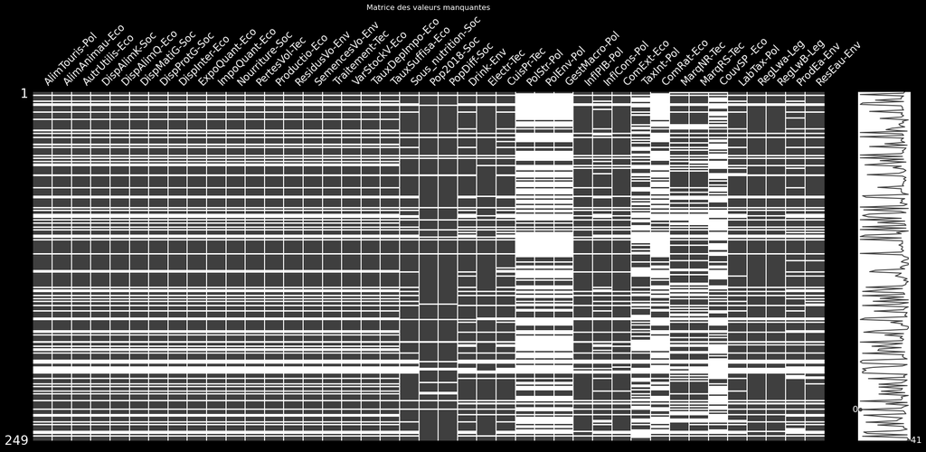

```python
# Matrice des valeurs manquantes
msno.matrix(df_poule_qui_chante)
plt.title("Matrice des valeurs manquantes")
plt.show()
```

La matrice des valeurs manquantes, générée par la librairie MSNO, offre une visualisation synthétique de la distribution des données manquantes dans le jeu de données df_poule_qui_chante.

**- Certaines variables sont plus impactées que d'autres, par exemple ComRat-Eco, PolStr_Pol, PolEnv-Pol et GestMacro-Pol présentent un grand nombre de valeurs manquantes.**

**- Les données comprennent 249 individus et certaine lignes semblent totalement vides, le nombre de valeurs manquantes par observation, allant de 0 à 41 .**

De plus, le rond en bas à droite au niveau de l'histogramme undique **valeur aberrante** : présence d'une observation avec un nombre anormalement élevé de données manquantes.

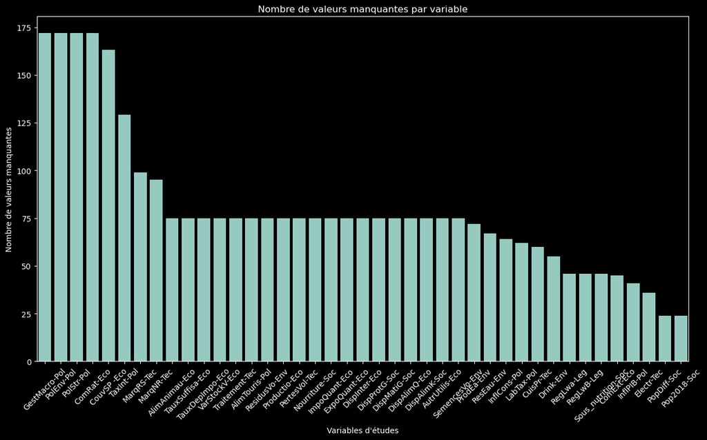

```python
# Calculer le nombre de valeurs manquantes pour chaque colonne
Colonnes_NaN =  df_poule_qui_chante.isnull().sum()
Trie_Colonnes_NaN = Colonnes_NaN[Colonnes_NaN > 0]

# Trier les colonnes par le nombre de valeurs manquantes pour un affichage plus clair
Trie_Colonnes_NaN = Trie_Colonnes_NaN.sort_values(ascending=False)

# Visualisation des valeurs manquantes par colonne (en nombre), triées
plt.figure(figsize=(15, 8))
sns.barplot(x=Trie_Colonnes_NaN.index, y=Trie_Colonnes_NaN)
plt.xticks(rotation=45)
plt.xlabel("Variables d'études")
plt.ylabel('Nombre de valeurs manquantes')
plt.title('Nombre de valeurs manquantes par variable')
plt.show()
```

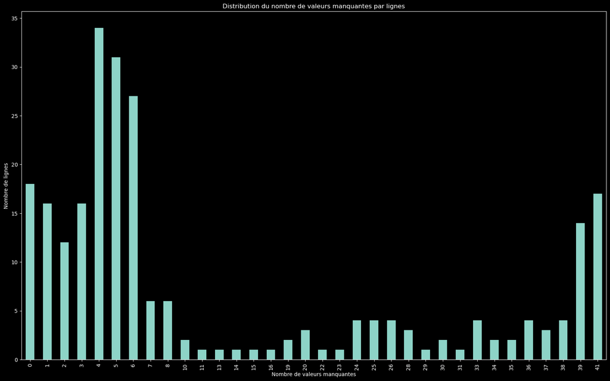

```python
# Comptage des valeurs manquantes par lignes
plt.figure(figsize=(20, 12))
df_poule_qui_chante.isnull().sum(axis=1).value_counts().sort_index().plot(kind='bar')
plt.title('Distribution du nombre de valeurs manquantes par lignes')
plt.xlabel('Nombre de valeurs manquantes')
plt.ylabel('Nombre de lignes')
plt.show()
```

### 4.1.2 - Traitement par variables

```python
# Supprimer les variables avec + que 75 valeurs manquantes
missing_counts_variables = df_poule_qui_chante.isnull().sum()
variables_a_supprimer = missing_counts_variables[missing_counts_variables > 75].index

df_poule_qui_chante = df_poule_qui_chante.drop(columns=variables_a_supprimer)

variables_a_supprimer
```

```
Index(['PolStr-Pol', 'PolEnv-Pol', 'GestMacro-Pol', 'TaxInt-Pol', 'ComRat-Eco',
       'MarqNR-Tec', 'MarqRS-Tec', 'CouvSP -Eco'],
      dtype='object')
```

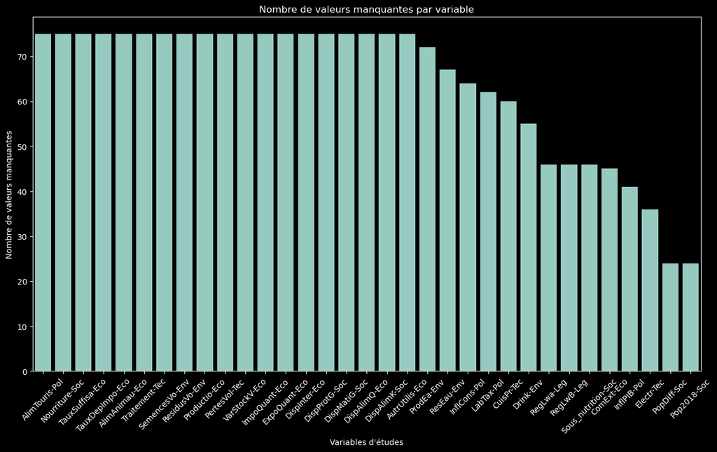

```python
# Calculer le nombre de valeurs manquantes pour chaque colonne
Colonnes_NaN =  df_poule_qui_chante.isnull().sum()
Trie_Colonnes_NaN = Colonnes_NaN[Colonnes_NaN > 0]

# Trier les colonnes par le nombre de valeurs manquantes pour un affichage plus clair
Trie_Colonnes_NaN = Trie_Colonnes_NaN.sort_values(ascending=False)

# Visualisation des valeurs manquantes par colonne (en nombre), triées
plt.figure(figsize=(15, 8))
sns.barplot(x=Trie_Colonnes_NaN.index, y=Trie_Colonnes_NaN)
plt.xticks(rotation=45)
plt.xlabel("Variables d'études")
plt.ylabel('Nombre de valeurs manquantes')
plt.title('Nombre de valeurs manquantes par variable')
plt.show()
```

### 4.1.3 - Traitement par individus

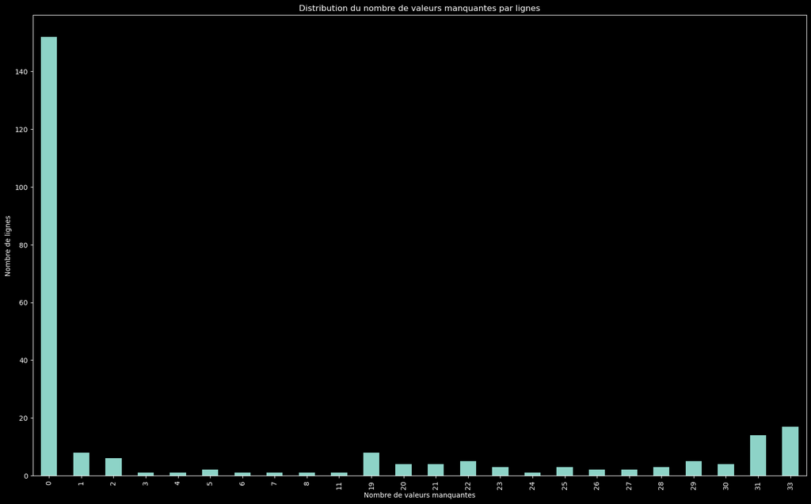

```python
# Comptage des valeurs manquantes par lignes
plt.figure(figsize=(20, 12))
df_poule_qui_chante.isnull().sum(axis=1).value_counts().sort_index().plot(kind='bar')
plt.title('Distribution du nombre de valeurs manquantes par lignes')
plt.xlabel('Nombre de valeurs manquantes')
plt.ylabel('Nombre de lignes')
plt.show()
```

```python
# Supprimer les observations qui comportent 1 valeur manquante ou plus
df_poule_qui_chante = df_poule_qui_chante[df_poule_qui_chante.isnull().sum(axis=1) < 1]
```

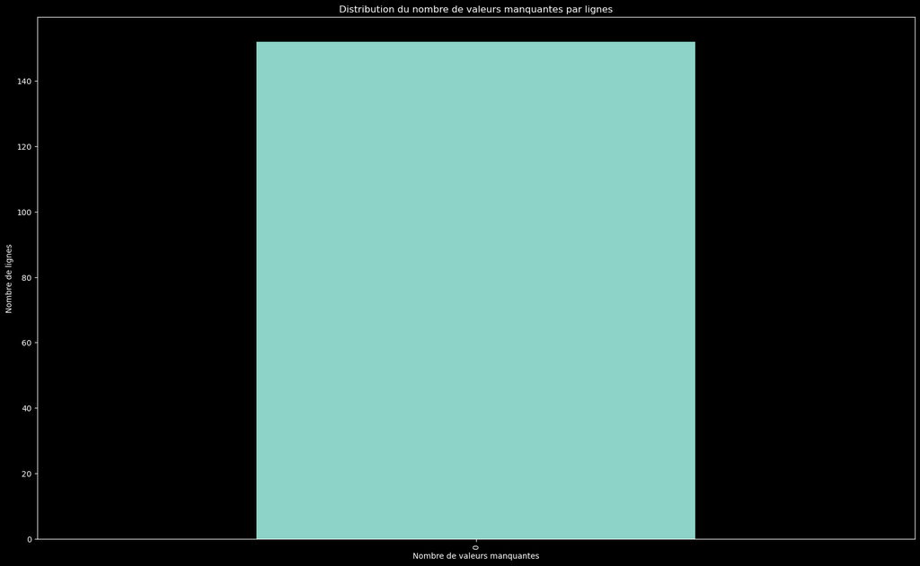

```python
# Comptage des valeurs manquantes par lignes
plt.figure(figsize=(20, 12))
df_poule_qui_chante.isnull().sum(axis=1).value_counts().sort_index().plot(kind='bar')
plt.title('Distribution du nombre de valeurs manquantes par lignes')
plt.xlabel('Nombre de valeurs manquantes')
plt.ylabel('Nombre de lignes')
plt.show()
```

### 4.1.4 - Vérification et éxploration post-traitement

```python
missing_counts = df_poule_qui_chante.isnull().sum()

if missing_counts.any():  # Vérifie si au moins une valeur est non nulle
    plt.figure(figsize=(10, 6))
    missing_counts.plot(kind='bar')
    plt.title('Histogramme des valeurs manquantes par variable')
    plt.xlabel('Variables')
    plt.show()
else:
    print("Aucune valeur manquante trouvée dans le DataFrame.")
```

```
Aucune valeur manquante trouvée dans le DataFrame.
```

```python
df_poule_qui_chante.describe(include='all')
```

|  | AlimTouris-Pol | AlimAnimau-Eco | AutrUtilis-Eco | DispAlimK-Soc | DispAlimQ-Eco | DispMatiG-Soc | DispProtG-Soc | DispInter-Eco | ExpoQuant-Eco | ImpoQuant-Eco | Nourriture-Soc | PertesVol-Tec | Productio-Eco | ResidusVo-Env | SemencesVo-Env | Traitement-Tec | VarStockV-Eco | TauxDepImpo-Eco | TauxSuffisa-Eco | Sous_nutrition-Soc | Pop2018-Soc | PopDiff-Soc | Drink-Env | Electr-Tec | CuisPr-Tec | InflPIB-Pol | InflCons-Pol | ComExt-Eco | LabTax-Pol | … |
| --- | --- | --- | --- | --- | --- | --- | --- | --- | --- | --- | --- | --- | --- | --- | --- | --- | --- | --- | --- | --- | --- | --- | --- | --- | --- | --- | --- | --- | --- | --- |
| count | 152.000000 | 152.0 | 152.000000 | 152.000000 | 152.000000 | 152.000000 | 152.000000 | 152.000000 | 152.000000 | 152.000000 | 152.000000 | 152.000000 | 152.000000 | 152.000000 | 152.0 | 152.000000 | 152.000000 | 152.000000 | 152.000000 | 152.000000 | 1.520000e+02 | 152.000000 | 152.000000 | 152.000000 | 152.000000 | 152.000000 | 152.000000 | 152.000000 | 152.000000 | … |
| mean | 0.203947 | 0.0 | 9.138158 | 71.677632 | 19.459145 | 4.703684 | 6.859934 | 738.671053 | 111.203947 | 89.118421 | 705.269737 | 18.282895 | 775.671053 | -2.230263 | 0.0 | 7.947368 | 14.888158 | 0.279348 | 0.788896 | 3.336842 | 4.756645e+04 | 31.972730 | 88.062184 | 84.305994 | 69.477522 | 6.491292 | 5.763085 | 64.351922 | 17.153947 | … |
| std | 0.774928 | 0.0 | 68.906122 | 59.208868 | 15.499775 | 4.109949 | 5.463463 | 2302.880873 | 483.962019 | 183.486793 | 2250.166513 | 82.499000 | 2619.811878 | 9.965151 | 0.0 | 32.388533 | 79.369248 | 0.395239 | 0.505100 | 16.285358 | 1.635763e+05 | 30.950597 | 15.263306 | 25.334687 | 36.979437 | 18.746288 | 10.194184 | 35.180418 | 11.180729 | … |
| min | 0.000000 | 0.0 | 0.000000 | 0.000000 | 0.000000 | 0.000000 | 0.000000 | 0.000000 | 0.000000 | 0.000000 | 0.000000 | 0.000000 | 0.000000 | -78.000000 | 0.0 | 0.000000 | -119.000000 | 0.000000 | 0.000000 | 0.000000 | 5.244100e+01 | -20.006000 | 38.701000 | 9.844444 | 0.555556 | -0.211590 | 0.284092 | 20.183775 | 0.000000 | … |
| 25% | 0.000000 | 0.0 | 0.000000 | 19.500000 | 5.957500 | 1.295000 | 1.927500 | 32.750000 | 0.000000 | 2.750000 | 30.000000 | 0.000000 | 13.750000 | 0.000000 | 0.0 | 0.000000 | -0.000000 | 0.000000 | 0.398214 | 0.000000 | 3.115598e+03 | 10.014250 | 81.388750 | 76.944444 | 33.830556 | 2.107210 | 1.888048 | 41.591216 | 9.150000 | … |
| 50% | 0.000000 | 0.0 | 0.000000 | 62.000000 | 17.325000 | 3.690000 | 6.300000 | 110.500000 | 0.500000 | 16.000000 | 103.000000 | 0.000000 | 79.000000 | 0.000000 | 0.0 | 0.000000 | 0.000000 | 0.113129 | 0.888462 | 0.100000 | 1.038922e+04 | 26.481500 | 95.482500 | 99.505556 | 89.266667 | 3.054364 | 3.235733 | 53.547292 | 15.383333 | … |
| 75% | 0.000000 | 0.0 | 0.000000 | 104.000000 | 28.387500 | 6.352500 | 9.832500 | 376.500000 | 16.250000 | 82.500000 | 373.500000 | 2.000000 | 463.000000 | 0.000000 | 0.0 | 0.000000 | 7.250000 | 0.377580 | 1.000000 | 1.595833 | 3.278287e+04 | 51.072750 | 99.548000 | 100.000000 | 100.000000 | 6.027531 | 6.131558 | 75.640315 | 23.887500 | … |
| max | 5.000000 | 0.0 | 783.000000 | 243.000000 | 72.310000 | 17.860000 | 27.870000 | 18266.000000 | 4223.000000 | 1069.000000 | 18100.000000 | 695.000000 | 21914.000000 | 0.000000 | 0.0 | 306.000000 | 859.000000 | 2.331034 | 3.046053 | 194.233333 | 1.427648e+06 | 207.300000 | 100.000000 | 100.000000 | 100.000000 | 227.554787 | 113.677610 | 191.511984 | 51.966667 | … |

```python
df_poule_qui_chante.info()
```

```
<class 'pandas.core.frame.DataFrame'>
Index: 152 entries, AFG to ZWE
Data columns (total 33 columns):
 #   Column              Non-Null Count  Dtype
---  ------              --------------  -----
 0   AlimTouris-Pol      152 non-null    float64
 1   AlimAnimau-Eco      152 non-null    float64
 2   AutrUtilis-Eco      152 non-null    float64
 3   DispAlimK-Soc       152 non-null    float64
 4   DispAlimQ-Eco       152 non-null    float64
 5   DispMatiG-Soc       152 non-null    float64
 6   DispProtG-Soc       152 non-null    float64
 7   DispInter-Eco       152 non-null    float64
 8   ExpoQuant-Eco       152 non-null    float64
 9   ImpoQuant-Eco       152 non-null    float64
```

[output cut: 25 more lines]

```python
df_poule_qui_chante
```

| Code Pays | AlimTouris-Pol | AlimAnimau-Eco | AutrUtilis-Eco | DispAlimK-Soc | DispAlimQ-Eco | DispMatiG-Soc | DispProtG-Soc | DispInter-Eco | ExpoQuant-Eco | ImpoQuant-Eco | Nourriture-Soc | PertesVol-Tec | Productio-Eco | ResidusVo-Env | SemencesVo-Env | Traitement-Tec | VarStockV-Eco | TauxDepImpo-Eco | TauxSuffisa-Eco | Sous_nutrition-Soc | Pop2018-Soc | PopDiff-Soc | Drink-Env | Electr-Tec | CuisPr-Tec | InflPIB-Pol | InflCons-Pol | ComExt-Eco | LabTax-Pol | … |
| --- | --- | --- | --- | --- | --- | --- | --- | --- | --- | --- | --- | --- | --- | --- | --- | --- | --- | --- | --- | --- | --- | --- | --- | --- | --- | --- | --- | --- | --- | --- |
| AFG | 0.0 | 0.0 | 0.0 | 5.0 | 1.53 | 0.33 | 0.54 | 57.0 | 0.0 | 29.0 | 55.0 | 2.0 | 28.0 | 0.0 | 0.0 | 0.0 | 0.0 | 0.000000 | 0.491228 | 9.600000 | 37171.921 | 78.884 | 67.065 | 92.022222 | 31.288889 | 3.446850 | 2.716775 | 41.648056 | 0.000000 | … |
| ZAF | 0.0 | 0.0 | 0.0 | 143.0 | 35.69 | 9.25 | 14.11 | 2118.0 | 63.0 | 514.0 | 2035.0 | 83.0 | 1667.0 | 0.0 | 0.0 | 0.0 | -0.0 | 0.242682 | 0.787063 | 2.816667 | 57792.518 | 28.520 | 92.679 | 86.111111 | 86.388889 | 5.298833 | 5.199888 | 54.849082 | 4.000000 | … |
| ALB | 0.0 | 0.0 | 0.0 | 85.0 | 16.36 | 6.45 | 6.26 | 47.0 | 0.0 | 38.0 | 47.0 | 0.0 | 13.0 | 0.0 | 0.0 | 0.0 | 4.0 | 0.745098 | 0.276596 | 0.100000 | 2882.740 | -7.877 | 91.039 | 99.977778 | 80.411111 | 2.423204 | 2.290094 | 57.953799 | 18.800000 | … |
| DZA | 0.0 | 0.0 | 0.0 | 22.0 | 6.38 | 1.50 | 1.97 | 277.0 | 0.0 | 2.0 | 264.0 | 13.0 | 275.0 | 0.0 | 0.0 | 0.0 | 0.0 | 0.007220 | 0.992780 | 1.283333 | 42228.408 | 36.035 | 93.556 | 99.577778 | 99.655556 | 4.117632 | 5.414083 | 42.891214 | 31.100000 | … |
| DEU | 0.0 | 0.0 | 0.0 | 71.0 | 19.47 | 4.16 | 7.96 | 1739.0 | 646.0 | 842.0 | 1609.0 | 0.0 | 1514.0 | -38.0 | 0.0 | 167.0 | -29.0 | 0.492398 | 0.870615 | 0.000000 | 83124.418 | 2.117 | 100.000 | 100.000000 | 100.000000 | 2.748947 | 2.263085 | 70.919536 | 21.350000 | … |
| ... | ... | ... | ... | ... | ... | ... | ... | ... | ... | ... | ... | ... | ... | ... | ... | ... | ... | ... | ... | ... | ... | ... | ... | ... | ... | ... | ... | ... | ... | … |
| URY | 0.0 | 0.0 | 0.0 | 33.0 | 9.12 | 2.23 | 2.97 | 33.0 | 3.0 | 3.0 | 31.0 | 0.0 | 33.0 | 0.0 | 0.0 | 2.0 | 0.0 | 0.090909 | 1.000000 | 0.000000 | 3449.285 | 3.902 | 99.402 | 99.844444 | 100.000000 | 7.953649 | 8.136746 | 28.759535 | 15.600000 | … |
| VNM | 0.0 | 0.0 | 0.0 | 48.0 | 12.33 | 3.40 | 4.01 | 1206.0 | 1.0 | 291.0 | 1166.0 | 39.0 | 918.0 | 0.0 | 0.0 | 0.0 | 2.0 | 0.240894 | 0.761194 | 7.416667 | 95545.962 | 19.566 | 94.719 | 99.655556 | 88.755556 | 2.451968 | 2.870476 | 153.907091 | 24.483333 | … |
| YEM | 0.0 | 0.0 | 0.0 | 30.0 | 8.53 | 1.85 | 3.04 | 246.0 | 0.0 | 78.0 | 237.0 | 8.0 | 168.0 | 0.0 | 0.0 | 0.0 | -0.0 | 0.317073 | 0.682927 | 0.000000 | 28498.683 | 63.700 | 63.473 | 71.244444 | 53.688889 | 17.436243 | 8.104726 | 22.566707 | 11.300000 | … |
| ZMB | 0.0 | 0.0 | 0.0 | 11.0 | 3.42 | 0.72 | 1.15 | 60.0 | 1.0 | 12.0 | 58.0 | 2.0 | 49.0 | 0.0 | 0.0 | 0.0 | -0.0 | 0.200000 | 0.816667 | 0.000000 | 17351.708 | 66.588 | 59.964 | 39.666667 | 11.833333 | 10.483712 | 11.864096 | 68.424277 | 10.400000 | … |
| ZWE | 0.0 | 0.0 | 0.0 | 16.0 | 4.68 | 0.99 | 1.59 | 76.0 | 0.0 | 6.0 | 67.0 | 3.0 | 69.0 | 0.0 | 0.0 | 6.0 | -0.0 | 0.000000 | 0.907895 | 0.000000 | 14438.802 | 21.524 | 64.051 | 44.044444 | 30.277778 | 227.554787 | 113.677610 | 47.283116 | 5.550000 | … |

152 rows × 33 columns

## 4.2 - Corrélation entre les variables

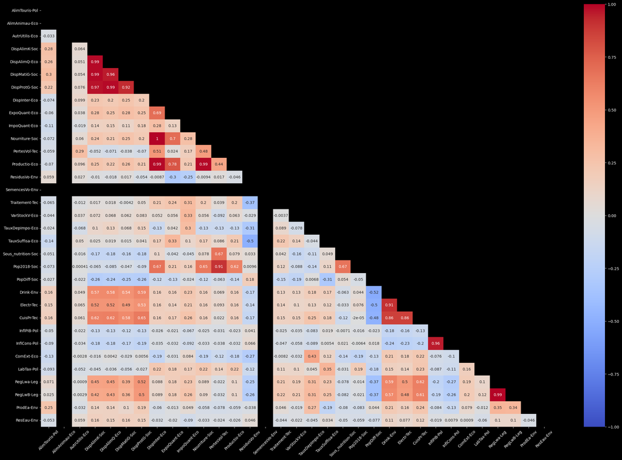

```python
# Calcul de la matrice de corrélation
corr = df_poule_qui_chante.corr()

# Masquer la partie supérieure de la matrice de corrélation
mask = np.triu(np.ones_like(corr, dtype=bool))

# Création de la heatmap avec le masque
plt.figure(figsize=(30, 20))
sns.heatmap(corr, mask=mask, annot=True, cmap='coolwarm', vmin=-1, vmax=1, center=0)
plt.xticks(rotation=45)
plt.show()
```

```python
# Liste des variables dont tu veux vérifier les données
variables_a_verifier = ['AlimAnimau-Eco', 'SemencesVo-Env']

# Boucle pour afficher les données de chaque variable
for variable in variables_a_verifier:
    print(f"\nDonnées pour la variable '{variable}':")

    # Vérification si la variable existe dans le DataFrame
    if variable in df_poule_qui_chante.columns:

        # Affichage des premières lignes de la variable
        print(df_poule_qui_chante[variable].head())

        # Analyse descriptive de la variable
        print(df_poule_qui_chante[variable].describe())

        # Vérification des valeurs manquantes
        print(f"Nombre de valeurs manquantes : {df_poule_qui_chante[variable].isnull().sum()}")
    else:
        print(f"La variable '{variable}' n'existe pas dans le DataFrame.")
```

```
Données pour la variable 'AlimAnimau-Eco':
Code Pays
AFG    0.0
ZAF    0.0
ALB    0.0
DZA    0.0
DEU    0.0
Name: AlimAnimau-Eco, dtype: float64
count    152.0
mean       0.0
std        0.0
min        0.0
25%        0.0
50%        0.0
75%        0.0
max        0.0
Name: AlimAnimau-Eco, dtype: float64
Nombre de valeurs manquantes : 0

Données pour la variable 'SemencesVo-Env':
Code Pays
AFG    0.0
ZAF    0.0
ALB    0.0
DZA    0.0
DEU    0.0
Name: SemencesVo-Env, dtype: float64
count    152.0
mean       0.0
std        0.0
min        0.0
25%        0.0
50%        0.0
75%        0.0
max        0.0
Name: SemencesVo-Env, dtype: float64
Nombre de valeurs manquantes : 0
```

```python
# Colonnes vide à supprimer
colonnes_a_supprimer = ['AlimAnimau-Eco', 'SemencesVo-Env' ]

df_poule_qui_chante = df_poule_qui_chante.drop(colonnes_a_supprimer, axis=1)
```

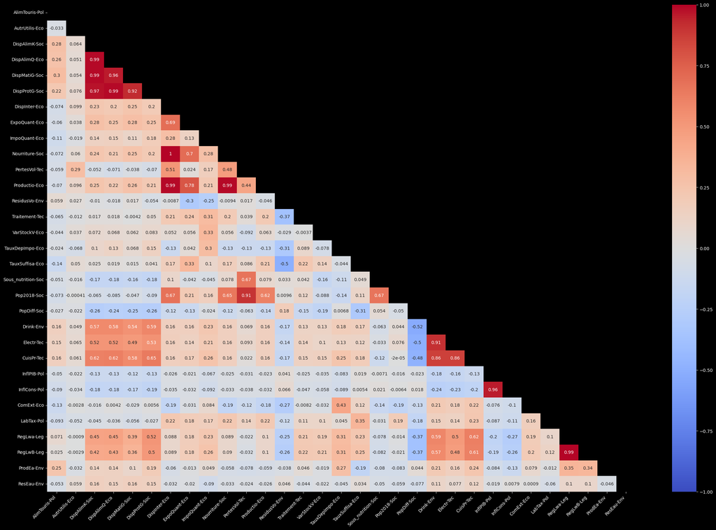

```python
# Calcul de la matrice de corrélation
corr = df_poule_qui_chante.corr()

# Masquer la partie supérieure de la matrice de corrélation
mask = np.triu(np.ones_like(corr, dtype=bool))

# Création de la heatmap avec le masque
plt.figure(figsize=(30, 20))
sns.heatmap(corr, mask=mask, annot=True, cmap='coolwarm', vmin=-1, vmax=1, center=0)
# Rotation des labels de l'axe x
plt.xticks(rotation=45, ha='right')
plt.show()
```

```python
df_poule_qui_chante
```

| Code Pays | AlimTouris-Pol | AutrUtilis-Eco | DispAlimK-Soc | DispAlimQ-Eco | DispMatiG-Soc | DispProtG-Soc | DispInter-Eco | ExpoQuant-Eco | ImpoQuant-Eco | Nourriture-Soc | PertesVol-Tec | Productio-Eco | ResidusVo-Env | Traitement-Tec | VarStockV-Eco | TauxDepImpo-Eco | TauxSuffisa-Eco | Sous_nutrition-Soc | Pop2018-Soc | PopDiff-Soc | Drink-Env | Electr-Tec | CuisPr-Tec | InflPIB-Pol | InflCons-Pol | ComExt-Eco | LabTax-Pol | RegLwa-Leg | RegLwB-Leg | … |
| --- | --- | --- | --- | --- | --- | --- | --- | --- | --- | --- | --- | --- | --- | --- | --- | --- | --- | --- | --- | --- | --- | --- | --- | --- | --- | --- | --- | --- | --- | --- |
| AFG | 0.0 | 0.0 | 5.0 | 1.53 | 0.33 | 0.54 | 57.0 | 0.0 | 29.0 | 55.0 | 2.0 | 28.0 | 0.0 | 0.0 | 0.0 | 0.000000 | 0.491228 | 9.600000 | 37171.921 | 78.884 | 67.065 | 92.022222 | 31.288889 | 3.446850 | 2.716775 | 41.648056 | 0.000000 | 4.178982 | 1.216451 | … |
| ZAF | 0.0 | 0.0 | 143.0 | 35.69 | 9.25 | 14.11 | 2118.0 | 63.0 | 514.0 | 2035.0 | 83.0 | 1667.0 | 0.0 | 0.0 | -0.0 | 0.242682 | 0.787063 | 2.816667 | 57792.518 | 28.520 | 92.679 | 86.111111 | 86.388889 | 5.298833 | 5.199888 | 54.849082 | 4.000000 | 52.548417 | 42.391003 | … |
| ALB | 0.0 | 0.0 | 85.0 | 16.36 | 6.45 | 6.26 | 47.0 | 0.0 | 38.0 | 47.0 | 0.0 | 13.0 | 0.0 | 0.0 | 4.0 | 0.745098 | 0.276596 | 0.100000 | 2882.740 | -7.877 | 91.039 | 99.977778 | 80.411111 | 2.423204 | 2.290094 | 57.953799 | 18.800000 | 41.530773 | 31.052883 | … |
| DZA | 0.0 | 0.0 | 22.0 | 6.38 | 1.50 | 1.97 | 277.0 | 0.0 | 2.0 | 264.0 | 13.0 | 275.0 | 0.0 | 0.0 | 0.0 | 0.007220 | 0.992780 | 1.283333 | 42228.408 | 36.035 | 93.556 | 99.577778 | 99.655556 | 4.117632 | 5.414083 | 42.891214 | 31.100000 | 20.581963 | 11.585027 | … |
| DEU | 0.0 | 0.0 | 71.0 | 19.47 | 4.16 | 7.96 | 1739.0 | 646.0 | 842.0 | 1609.0 | 0.0 | 1514.0 | -38.0 | 167.0 | -29.0 | 0.492398 | 0.870615 | 0.000000 | 83124.418 | 2.117 | 100.000 | 100.000000 | 100.000000 | 2.748947 | 2.263085 | 70.919536 | 21.350000 | 92.065364 | 87.515503 | … |
| ... | ... | ... | ... | ... | ... | ... | ... | ... | ... | ... | ... | ... | ... | ... | ... | ... | ... | ... | ... | ... | ... | ... | ... | ... | ... | ... | ... | ... | ... | … |
| URY | 0.0 | 0.0 | 33.0 | 9.12 | 2.23 | 2.97 | 33.0 | 3.0 | 3.0 | 31.0 | 0.0 | 33.0 | 0.0 | 2.0 | 0.0 | 0.090909 | 1.000000 | 0.000000 | 3449.285 | 3.902 | 99.402 | 99.844444 | 100.000000 | 7.953649 | 8.136746 | 28.759535 | 15.600000 | 73.333353 | 64.289602 | … |
| VNM | 0.0 | 0.0 | 48.0 | 12.33 | 3.40 | 4.01 | 1206.0 | 1.0 | 291.0 | 1166.0 | 39.0 | 918.0 | 0.0 | 0.0 | 2.0 | 0.240894 | 0.761194 | 7.416667 | 95545.962 | 19.566 | 94.719 | 99.655556 | 88.755556 | 2.451968 | 2.870476 | 153.907091 | 24.483333 | 49.201213 | 38.882035 | … |
| YEM | 0.0 | 0.0 | 30.0 | 8.53 | 1.85 | 3.04 | 246.0 | 0.0 | 78.0 | 237.0 | 8.0 | 168.0 | 0.0 | 0.0 | -0.0 | 0.317073 | 0.682927 | 0.000000 | 28498.683 | 63.700 | 63.473 | 71.244444 | 53.688889 | 17.436243 | 8.104726 | 22.566707 | 11.300000 | 3.709847 | 1.113156 | … |
| ZMB | 0.0 | 0.0 | 11.0 | 3.42 | 0.72 | 1.15 | 60.0 | 1.0 | 12.0 | 58.0 | 2.0 | 49.0 | 0.0 | 0.0 | -0.0 | 0.200000 | 0.816667 | 0.000000 | 17351.708 | 66.588 | 59.964 | 39.666667 | 11.833333 | 10.483712 | 11.864096 | 68.424277 | 10.400000 | 38.322304 | 28.745393 | … |
| ZWE | 0.0 | 0.0 | 16.0 | 4.68 | 0.99 | 1.59 | 76.0 | 0.0 | 6.0 | 67.0 | 3.0 | 69.0 | 0.0 | 6.0 | -0.0 | 0.000000 | 0.907895 | 0.000000 | 14438.802 | 21.524 | 64.051 | 44.044444 | 30.277778 | 227.554787 | 113.677610 | 47.283116 | 5.550000 | 7.505318 | 4.386572 | … |

152 rows × 31 columns

## 4.3 - Choix des variables fortement corrélées

```python
# Calcul de la matrice de corrélation
corr_matrix = df_poule_qui_chante.corr().abs()

# Initialisation du DataFrame des corrélations élevées
high_corr_pairs = []

# Itération sur la matrice de corrélation pour trouver les paires de variables
for i in range(len(corr_matrix.columns)):
    for j in range(i + 1, len(corr_matrix.columns)):
        if corr_matrix.iloc[i, j] > 0.90:
            high_corr_pairs.append([corr_matrix.columns[i], corr_matrix.columns[j], corr_matrix.iloc[i, j]])

# Conversion en DataFrame pour un affichage plus facile
high_corr_df = pd.DataFrame(high_corr_pairs, columns=['Variable 1', 'Variable 2', 'Correlation'])

high_corr_df
```

|  | Variable 1 | Variable 2 | Correlation |
| --- | --- | --- | --- |
| 0 | DispAlimK-Soc | DispAlimQ-Eco | 0.988222 |
| 1 | DispAlimK-Soc | DispMatiG-Soc | 0.988332 |
| 2 | DispAlimK-Soc | DispProtG-Soc | 0.971303 |
| 3 | DispAlimQ-Eco | DispMatiG-Soc | 0.959777 |
| 4 | DispAlimQ-Eco | DispProtG-Soc | 0.985518 |
| 5 | DispMatiG-Soc | DispProtG-Soc | 0.923833 |
| 6 | DispInter-Eco | Nourriture-Soc | 0.998726 |
| 7 | DispInter-Eco | Productio-Eco | 0.988029 |
| 8 | Nourriture-Soc | Productio-Eco | 0.989380 |
| 9 | PertesVol-Tec | Pop2018-Soc | 0.905493 |
| 10 | Drink-Env | Electr-Tec | 0.907716 |
| 11 | InflPIB-Pol | InflCons-Pol | 0.959901 |
| 12 | RegLwa-Leg | RegLwB-Leg | 0.994044 |

### Analyse des corrélations entre les variables

**Groupe 1 : Indicateurs de disponibilité et consommation alimentaire**

- **Variables corrélées**: DispAlimK-Soc, DispAlimQ-Eco, DispMatiG-Soc, DispProtG-Soc.
- **Variable supprimée**: DispAlimK-Soc, DispMatiG-Soc, DispProtG-Soc.
- **Justification**: Ces variables sont interdépendantes car la quantité de nourriture consommée (DispAlimQ-Eco) influence directement l'apport calorique total (DispAlimK-Soc) ainsi que la consommation de macronutriments comme les matières grasses (DispMatiG-Soc) et les protéines (DispProtG-Soc). Pour les décisions d'exportation de viande de volaille, la quantité consommée par habitant (DispAlimQ-Eco) est l'indicateur le plus pertinent car il reflète directement la taille du marché et le potentiel de croissance.
- **Impact**: DispAlimQ-Eco permettra d'identifier les marchés où la consommation de viande de volaille est élevée, ce qui représente un potentiel d'exportation important.

**Groupe 2 : Disponibilité intérieure et production**

- **Variables corrélées**: DispInter-Eco, Nourriture-Soc, Productio-Eco.
- **Variable supprimée**: Nourriture-Soc, Productio-Eco.
- **Justification**: La disponibilité intérieure (DispInter-Eco) est fortement corrélée à la quantité destinée à la consommation humaine (Nourriture-Soc) car cette dernière représente la part la plus importante de l'utilisation de la viande de volaille. La production locale (Productio-Eco) a un impact direct sur la disponibilité intérieure, surtout dans les pays où les importations sont faibles.
- **Impact**: DispInter-Eco permettra d'évaluer la taille du marché global et d'identifier les pays où la demande est supérieure à l'offre locale, indiquant un potentiel d'exportation.
- **Choix et justification:** Suppression de Productio-Eco et de Nourriture-Soc. DispInter-Eco est plus complète car elle inclut également les importations et les variations de stocks, offrant une vision plus complète de l'offre disponible.

**Groupe 3 : Pertes et population**

- **Variables corrélées**: PertesVol-Tec, Pop2018-Soc.
- **Variable supprimée**: Pop2018-Soc.
- **Justification**: Une population plus importante (Pop2018-Soc) implique généralement une production et une consommation accrues de viande de volaille, ce qui peut entraîner des défis logistiques plus importants et potentiellement plus de pertes (PertesVol-Tec) dues à des problèmes de stockage, de transport et de distribution. La croissance démographique (PopDiff-Soc) est également un facteur important à prendre en compte pour les exportateurs car elle indique l'évolution future du marché et le potentiel de croissance à long terme.
- **Impact**: PertesVol-Tec permettra d'identifier les pays où l'amélioration de la chaîne d'approvisionnement pourrait réduire les pertes et améliorer la rentabilité des exportations. **PopDiff-Soc, une autre variable conservée nous permettra de prendre en compte les données de population et de cibler les marchés à fort potentiel.**

**Groupe 4 : Accès à l'eau, à l'électricité et ressources en eau**

- **Variables corrélées**: Drink-Env, Electr-Tec.
- **Variable supprimée**: Drink-Env.
- **Justification**: L'accès à l'eau potable (Drink-Env) et à l'électricité (Electr-Tec) sont des indicateurs du niveau de développement des infrastructures d'un pays. L'accès à l'électricité est particulièrement crucial pour le secteur de la viande de volaille car il est indispensable au bon fonctionnement des abattoirs, des installations de transformation et des systèmes de réfrigération, essentiels pour garantir la sécurité sanitaire et la qualité des produits destinés à l'exportation.
- **Impact**: Electr-Tec permettra de cibler les pays disposant des infrastructures nécessaires pour garantir la qualité et la sécurité des produits exportés, réduisant ainsi les risques et les coûts liés aux exportations. **De plus d'autres variables liées à l'eau, telles que ProdEa-Env et ResEau-Env apportant des informations complémentaires**

**Groupe 5 : Inflation**

- **Variables corrélées**: InflPIB-Pol, InflCons-Pol.
- **Variable supprimée**: InflPIB-Pol.
- **Justification**: L'inflation générale (InflPIB-Pol) a un impact sur les prix à la consommation (InflCons-Pol), y compris ceux de la viande de volaille. Pour les exportateurs, il est important de surveiller l'inflation dans les pays cibles car une inflation élevée peut affecter le pouvoir d'achat des consommateurs et donc la demande de viande de volaille.
- **Impact**: InflCons-Pol permettra d'évaluer l'impact potentiel de l'inflation sur le prix de la viande de volaille dans les pays cibles.

**Groupe 6 : Règle de droit**

- **Variables corrélées**: RegLwa-Leg, RegLwB-Leg.
- **Variable supprimée**: RegLwB-Leg.
- **Justification**: La règle de droit (RegLwa-Leg) est un indicateur essentiel pour les exportateurs car elle reflète la qualité du système judiciaire, le respect des contrats et la stabilité du cadre légal dans un pays. Un environnement juridique solide et prévisible est crucial pour garantir la sécurité des investissements et le bon déroulement des transactions commerciales.
- **Impact**: RegLwa-Leg permettra d'évaluer les risques juridiques et la sécurité des transactions commerciales dans les pays cibles, permettant aux exportateurs de prendre des décisions éclairées et de minimiser les risques.

```python
# Variables à supprimer
variables_to_remove = [
    'DispAlimK-Soc', 'DispMatiG-Soc', 'DispProtG-Soc', 'Nourriture-Soc', 'Productio-Eco', 'Pop2018-Soc', 'Drink-Env',
    'InflPIB-Pol', 'RegLwB-Leg',
]

df_poule_qui_chante = df_poule_qui_chante.drop(columns=variables_to_remove)
```

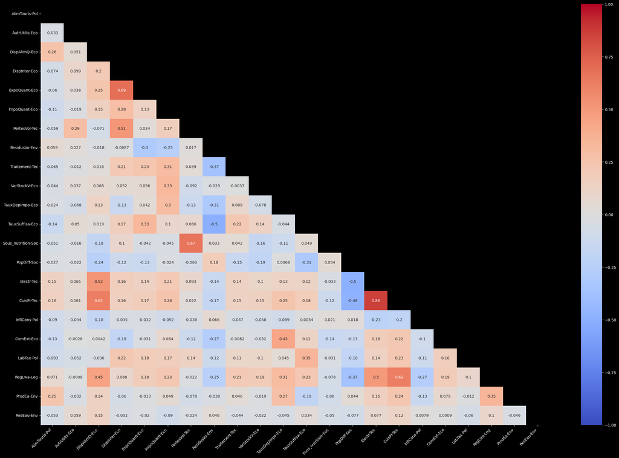

```python
# Calcul de la matrice de corrélation
corr = df_poule_qui_chante.corr()

# Masquer la partie supérieure de la matrice de corrélation
mask = np.triu(np.ones_like(corr, dtype=bool))

# Création de la heatmap avec le masque
plt.figure(figsize=(30, 20))
sns.heatmap(corr, mask=mask, annot=True, cmap='coolwarm', vmin=-1, vmax=1, center=0)
# Rotation des labels de l'axe x
plt.xticks(rotation=45, ha='right')
plt.show()
```

```python
# Calcul de la matrice de corrélation
corr_matrix = df_poule_qui_chante.corr().abs()

# Initialisation du DataFrame des corrélations élevées
high_corr_pairs = []

# Itération sur la matrice de corrélation pour trouver les paires de variables
for i in range(len(corr_matrix.columns)):
    for j in range(i + 1, len(corr_matrix.columns)):
        if corr_matrix.iloc[i, j] > 0.90:
            high_corr_pairs.append([corr_matrix.columns[i], corr_matrix.columns[j], corr_matrix.iloc[i, j]])

# Conversion en DataFrame pour un affichage plus facile
high_corr_df = pd.DataFrame(high_corr_pairs, columns=['Variable 1', 'Variable 2', 'Correlation'])

high_corr_df
```

|  | Variable 1 | Variable 2 | Correlation |
| --- | --- | --- | --- |

## 4.4 - Exploration du df_poule_qui_chante

```python
df_poule_qui_chante.info()
```

```
<class 'pandas.core.frame.DataFrame'>
Index: 152 entries, AFG to ZWE
Data columns (total 22 columns):
 #   Column              Non-Null Count  Dtype
---  ------              --------------  -----
 0   AlimTouris-Pol      152 non-null    float64
 1   AutrUtilis-Eco      152 non-null    float64
 2   DispAlimQ-Eco       152 non-null    float64
 3   DispInter-Eco       152 non-null    float64
 4   ExpoQuant-Eco       152 non-null    float64
 5   ImpoQuant-Eco       152 non-null    float64
 6   PertesVol-Tec       152 non-null    float64
 7   ResidusVo-Env       152 non-null    float64
 8   Traitement-Tec      152 non-null    float64
 9   VarStockV-Eco       152 non-null    float64
 10  TauxDepImpo-Eco     152 non-null    float64
 11  TauxSuffisa-Eco     152 non-null    float64
 12  Sous_nutrition-Soc  152 non-null    float64
 13  PopDiff-Soc         152 non-null    float64
 14  Electr-Tec          152 non-null    float64
 15  CuisPr-Tec          152 non-null    float64
 16  InflCons-Pol        152 non-null    float64
 17  ComExt-Eco          152 non-null    float64
 18  LabTax-Pol          152 non-null    float64
 19  RegLwa-Leg          152 non-null    float64
 20  ProdEa-Env          152 non-null    float64
 21  ResEau-Env          152 non-null    float64
dtypes: float64(22)
memory usage: 27.3+ KB
```

```python
df_poule_qui_chante.describe(include='all')
```

|  | AlimTouris-Pol | AutrUtilis-Eco | DispAlimQ-Eco | DispInter-Eco | ExpoQuant-Eco | ImpoQuant-Eco | PertesVol-Tec | ResidusVo-Env | Traitement-Tec | VarStockV-Eco | TauxDepImpo-Eco | TauxSuffisa-Eco | Sous_nutrition-Soc | PopDiff-Soc | Electr-Tec | CuisPr-Tec | InflCons-Pol | ComExt-Eco | LabTax-Pol | RegLwa-Leg | ProdEa-Env | ResEau-Env |
| --- | --- | --- | --- | --- | --- | --- | --- | --- | --- | --- | --- | --- | --- | --- | --- | --- | --- | --- | --- | --- | --- | --- |
| count | 152.000000 | 152.000000 | 152.000000 | 152.000000 | 152.000000 | 152.000000 | 152.000000 | 152.000000 | 152.000000 | 152.000000 | 152.000000 | 152.000000 | 152.000000 | 152.000000 | 152.000000 | 152.000000 | 152.000000 | 152.000000 | 152.000000 | 152.000000 | 152.000000 | 152.000000 |
| mean | 0.203947 | 9.138158 | 19.459145 | 738.671053 | 111.203947 | 89.118421 | 18.282895 | -2.230263 | 7.947368 | 14.888158 | 0.279348 | 0.788896 | 3.336842 | 31.972730 | 84.305994 | 69.477522 | 5.763085 | 64.351922 | 17.153947 | 48.646261 | 68.667561 | 15632.649856 |
| std | 0.774928 | 68.906122 | 15.499775 | 2302.880873 | 483.962019 | 183.486793 | 82.499000 | 9.965151 | 32.388533 | 79.369248 | 0.395239 | 0.505100 | 16.285358 | 30.950597 | 25.334687 | 36.979437 | 10.194184 | 35.180418 | 11.180729 | 27.654321 | 148.648461 | 50162.547837 |
| min | 0.000000 | 0.000000 | 0.000000 | 0.000000 | 0.000000 | 0.000000 | 0.000000 | -78.000000 | 0.000000 | -119.000000 | 0.000000 | 0.000000 | 0.000000 | -20.006000 | 9.844444 | 0.555556 | 0.284092 | 20.183775 | 0.000000 | 2.907586 | 0.895692 | 0.000000 |
| 25% | 0.000000 | 0.000000 | 5.957500 | 32.750000 | 0.000000 | 2.750000 | 0.000000 | 0.000000 | 0.000000 | -0.000000 | 0.000000 | 0.398214 | 0.000000 | 10.014250 | 76.944444 | 33.830556 | 1.888048 | 41.591216 | 9.150000 | 25.233396 | 9.239886 | 990.367856 |
| 50% | 0.000000 | 0.000000 | 17.325000 | 110.500000 | 0.500000 | 16.000000 | 0.000000 | 0.000000 | 0.000000 | 0.000000 | 0.113129 | 0.888462 | 0.100000 | 26.481500 | 99.505556 | 89.266667 | 3.235733 | 53.547292 | 15.383333 | 46.508916 | 21.310361 | 2830.670211 |
| 75% | 0.000000 | 0.000000 | 28.387500 | 376.500000 | 16.250000 | 82.500000 | 2.000000 | 0.000000 | 0.000000 | 7.250000 | 0.377580 | 1.000000 | 1.595833 | 51.072750 | 100.000000 | 100.000000 | 6.131558 | 75.640315 | 23.887500 | 69.459618 | 68.905903 | 10258.820006 |
| max | 5.000000 | 783.000000 | 72.310000 | 18266.000000 | 4223.000000 | 1069.000000 | 695.000000 | 0.000000 | 306.000000 | 859.000000 | 2.331034 | 3.046053 | 194.233333 | 207.300000 | 100.000000 | 100.000000 | 113.677610 | 191.511984 | 51.966667 | 100.000000 | 1343.999682 | 493191.628992 |

```python
df_poule_qui_chante
```

| Code Pays | AlimTouris-Pol | AutrUtilis-Eco | DispAlimQ-Eco | DispInter-Eco | ExpoQuant-Eco | ImpoQuant-Eco | PertesVol-Tec | ResidusVo-Env | Traitement-Tec | VarStockV-Eco | TauxDepImpo-Eco | TauxSuffisa-Eco | Sous_nutrition-Soc | PopDiff-Soc | Electr-Tec | CuisPr-Tec | InflCons-Pol | ComExt-Eco | LabTax-Pol | RegLwa-Leg | ProdEa-Env | ResEau-Env |
| --- | --- | --- | --- | --- | --- | --- | --- | --- | --- | --- | --- | --- | --- | --- | --- | --- | --- | --- | --- | --- | --- | --- |
| AFG | 0.0 | 0.0 | 1.53 | 57.0 | 0.0 | 29.0 | 2.0 | 0.0 | 0.0 | 0.0 | 0.000000 | 0.491228 | 9.600000 | 78.884 | 92.022222 | 31.288889 | 2.716775 | 41.648056 | 0.000000 | 4.178982 | 0.984053 | 1323.656076 |
| ZAF | 0.0 | 0.0 | 35.69 | 2118.0 | 63.0 | 514.0 | 83.0 | 0.0 | 0.0 | -0.0 | 0.242682 | 0.787063 | 2.816667 | 28.520 | 86.111111 | 86.388889 | 5.199888 | 54.849082 | 4.000000 | 52.548417 | 18.395155 | 788.534340 |
| ALB | 0.0 | 0.0 | 16.36 | 47.0 | 0.0 | 38.0 | 0.0 | 0.0 | 0.0 | 4.0 | 0.745098 | 0.276596 | 0.100000 | -7.877 | 99.977778 | 80.411111 | 2.290094 | 57.953799 | 18.800000 | 41.530773 | 12.197807 | 9378.821366 |
| DZA | 0.0 | 0.0 | 6.38 | 277.0 | 0.0 | 2.0 | 13.0 | 0.0 | 0.0 | 0.0 | 0.007220 | 0.992780 | 1.283333 | 36.035 | 99.577778 | 99.655556 | 5.414083 | 42.891214 | 31.100000 | 20.581963 | 20.588433 | 273.894672 |
| DEU | 0.0 | 0.0 | 19.47 | 1739.0 | 646.0 | 842.0 | 0.0 | -38.0 | 167.0 | -29.0 | 0.492398 | 0.870615 | 0.000000 | 2.117 | 100.000000 | 100.000000 | 2.263085 | 70.919536 | 21.350000 | 92.065364 | 140.975202 | 1298.573636 |
| ... | ... | ... | ... | ... | ... | ... | ... | ... | ... | ... | ... | ... | ... | ... | ... | ... | ... | ... | ... | ... | ... | ... |
| URY | 0.0 | 0.0 | 9.12 | 33.0 | 3.0 | 3.0 | 0.0 | 0.0 | 2.0 | 0.0 | 0.090909 | 1.000000 | 0.000000 | 3.902 | 99.844444 | 100.000000 | 8.136746 | 28.759535 | 15.600000 | 73.333353 | 15.981975 | 26987.681584 |
| VNM | 0.0 | 0.0 | 12.33 | 1206.0 | 1.0 | 291.0 | 39.0 | 0.0 | 0.0 | 2.0 | 0.240894 | 0.761194 | 7.416667 | 19.566 | 99.655556 | 88.755556 | 2.870476 | 153.907091 | 24.483333 | 49.201213 | 3.356546 | 3825.450942 |
| YEM | 0.0 | 0.0 | 8.53 | 246.0 | 0.0 | 78.0 | 8.0 | 0.0 | 0.0 | -0.0 | 0.317073 | 0.682927 | 0.000000 | 63.700 | 71.244444 | 53.688889 | 8.104726 | 22.566707 | 11.300000 | 3.709847 | 11.404409 | 70.111774 |
| ZMB | 0.0 | 0.0 | 3.42 | 60.0 | 1.0 | 12.0 | 2.0 | 0.0 | 0.0 | -0.0 | 0.200000 | 0.816667 | 0.000000 | 66.588 | 39.666667 | 11.833333 | 11.864096 | 68.424277 | 10.400000 | 38.322304 | 14.361295 | 4649.761725 |
| ZWE | 0.0 | 0.0 | 4.68 | 76.0 | 0.0 | 6.0 | 3.0 | 0.0 | 6.0 | -0.0 | 0.000000 | 0.907895 | 0.000000 | 21.524 | 44.044444 | 30.277778 | 113.677610 | 47.283116 | 5.550000 | 7.505318 | 5.736008 | 832.247001 |

152 rows × 22 columns

## 4.5 - Export Poule Qui Chante : PQC.csv

```python
# Enregistrer le nouveau dataframe sous PQC.csv  (pour la Poule Qui Chante)
df_poule_qui_chante.to_csv('PQC.csv', index=True)
```

```python
# !jupyter nbconvert --to pdf --execute "C:\Users\WadJa\Downloads\Zbakh_Jason_1_preparation_nettoyage_analyse_exploratoire_082024.ipynb"
```